# 🌎 Calidad del Aire en Santiago

Detección de episodios críticos de MP2.5 mediante algoritmos eficientes y Programación Orientada a Objetos

Fase 4 Entrega final · Magíster · Magíster en Ciencia de Datos e Inteligencia Artificial (MCDI500)

### 📋 Información General

- **Integrantes:** Rodrigo Chinchón Ayala · Sergio Fernández Almonacid · Pablo Villalobos González
- **Curso:** MCDI500 — Herramientas de Software Científico (202681.2535)
- **Docente:** Dr. Omar Salinas Silva
- **Institución:** Universidad Andrés Bello — Facultad de Ingeniería
- **Repositorio:** github.com/Rfcha/abp_cienciadatos
- **Proyecto:**F4-Entrega-final

### 📖 Contexto

La contaminación atmosférica constituye uno de los principales desafíos ambientales y sanitarios de las grandes ciudades...

Este proyecto aplica técnicas de **Ciencia de Datos**, algoritmos eficientes y principios de **Programación Orientada a Objetos (POO)**...

### 🔍 Pregunta de Investigación

¿Qué variables meteorológicas presentan una relación significativa con la ocurrencia de episodios críticos de contaminación atmosférica por material particulado en Santiago y cómo contribuyen a explicar su comportamiento temporal?

### 🎯 Objetivo del Proyecto

Identificar y caracterizar episodios críticos de contaminación atmosférica...

### 📘 Reproducibilidad y Trazabilidad

Todo el proceso analítico se encuentra documentado mediante notebooks Jupyter, código Python versionado en Git/GitHub y artefactos de soporte asociados al proyecto...

# ◆ 1. Configuración del Entorno Analítico

Esta sección establece la base técnica del notebook para el proyecto **Fase 4 (Entrega final) – Calidad del Aire en Santiago**. Su objetivo es preparar un entorno de análisis reproducible, consistente y auditable, asegurando que los procesos de carga, limpieza, transformación, exploración y visualización de datos se ejecuten bajo criterios metodológicos controlados y verificables.

El entorno utiliza bibliotecas estándar del ecosistema Python para Ciencia de Datos: **Pandas** para manipulación tabular, **NumPy** para procesamiento numérico, **Matplotlib** y **Seaborn** para visualización analítica, además de **OS** y **Pathlib** para la gestión del sistema de archivos y la trazabilidad de los recursos utilizados durante la ejecución del proyecto.

🎯 Resultado Esperado

Disponer de un entorno técnico completamente validado, con versiones de librerías registradas, parámetros gráficos homogéneos, configuraciones reproducibles y controles básicos de calidad que garanticen consistencia metodológica, trazabilidad de ejecución y confiabilidad de los resultados obtenidos durante el análisis.

```python
# =============================================================================
# VALIDACIÓN ROBUSTA DEL ENTORNO ANALÍTICO + SALIDA HTML
# Proyecto F4 (Entrega final): Calidad del Aire en Santiago · MCDI500
# =============================================================================

import sys
import os
from pathlib import Path
from datetime import datetime

import pandas as pd
import numpy as np
import matplotlib
import matplotlib.pyplot as plt
import seaborn as sns
from matplotlib.colors import to_rgba
from IPython.display import HTML, display


# -----------------------------------------------------------------------------
# 1. Configuración general de Pandas
# -----------------------------------------------------------------------------

pd.set_option("display.max_columns", None)
pd.set_option("display.max_rows", 100)
pd.set_option("display.float_format", "{:,.3f}".format)


# -----------------------------------------------------------------------------
# 2. Paleta visual profesional
# -----------------------------------------------------------------------------

COL = {
    "fondo": "#0d1117",
    "panel": "#111827",
    "panel_2": "#162033",
    "texto": "#e6edf3",
    "subtexto": "#b8c7dc",
    "azul": "#1f4ed8",
    "azul_2": "#2563eb",
    "verde": "#22c55e",
    "verde_oscuro": "#052e16",
    "rojo": "#ef4444",
    "ambar": "#f59e0b",
    "borde": "#334155",
    "blanco": "#ffffff",
}


# -----------------------------------------------------------------------------
# 3. Configuración real de Matplotlib y Seaborn
# -----------------------------------------------------------------------------

plt.rcParams.update({
    "figure.facecolor": COL["fondo"],
    "axes.facecolor": COL["panel"],
    "savefig.facecolor": COL["fondo"],
    "text.color": COL["texto"],
    "axes.labelcolor": COL["texto"],
    "xtick.color": COL["subtexto"],
    "ytick.color": COL["subtexto"],
    "axes.edgecolor": COL["borde"],
    "grid.color": COL["borde"],
    "axes.grid": True,
    "grid.alpha": 0.35,
    "axes.titleweight": "bold",
    "axes.titlesize": 13,
    "axes.labelsize": 11,
    "font.size": 11,
})

sns.set_theme(
    style="darkgrid",
    rc={
        "figure.facecolor": COL["fondo"],
        "axes.facecolor": COL["panel"],
        "text.color": COL["texto"],
        "axes.labelcolor": COL["texto"],
        "xtick.color": COL["subtexto"],
        "ytick.color": COL["subtexto"],
        "axes.edgecolor": COL["borde"],
        "grid.color": COL["borde"],
    },
)


# -----------------------------------------------------------------------------
# 4. Funciones de validación robusta
# -----------------------------------------------------------------------------

def color_igual(valor_actual, valor_esperado):
    """
    Compara colores de forma robusta.
    Soporta HEX, nombres de color, tuplas RGB/RGBA y formatos internos de Matplotlib.
    """
    try:
        return to_rgba(valor_actual) == to_rgba(valor_esperado)
    except Exception:
        return False


def check_matplotlib_theme():
    """
    Valida exhaustivamente que Matplotlib tenga aplicado el tema visual esperado.
    """
    checks = {
        "figure.facecolor": color_igual(plt.rcParams["figure.facecolor"], COL["fondo"]),
        "axes.facecolor": color_igual(plt.rcParams["axes.facecolor"], COL["panel"]),
        "savefig.facecolor": color_igual(plt.rcParams["savefig.facecolor"], COL["fondo"]),
        "text.color": color_igual(plt.rcParams["text.color"], COL["texto"]),
        "axes.labelcolor": color_igual(plt.rcParams["axes.labelcolor"], COL["texto"]),
        "xtick.color": color_igual(plt.rcParams["xtick.color"], COL["subtexto"]),
        "ytick.color": color_igual(plt.rcParams["ytick.color"], COL["subtexto"]),
        "axes.edgecolor": color_igual(plt.rcParams["axes.edgecolor"], COL["borde"]),
        "grid.color": color_igual(plt.rcParams["grid.color"], COL["borde"]),
        "axes.grid": plt.rcParams["axes.grid"] is True,
    }
    return all(checks.values()), checks


def check_seaborn_theme():
    """
    Valida que Seaborn esté activo y sincronizado con el tema base.
    """
    style = sns.axes_style()

    checks = {
        "style_dict": isinstance(style, dict),
        "axes.facecolor": color_igual(style.get("axes.facecolor"), COL["panel"]),
        "grid.color": color_igual(style.get("grid.color"), COL["borde"]),
        "axes.edgecolor": color_igual(style.get("axes.edgecolor"), COL["borde"]),
    }
    return all(checks.values()), checks


def render_status(value):
    return "✓ OK" if value else "⚠ REVISAR"


def render_class(value):
    return "ok" if value else "warn"


# -----------------------------------------------------------------------------
# 5. Validaciones del entorno
# -----------------------------------------------------------------------------

matplotlib_ok, matplotlib_detalle = check_matplotlib_theme()
seaborn_ok, seaborn_detalle = check_seaborn_theme()

required_libraries = {
    "Python": sys.version.split()[0],
    "Pandas": pd.__version__,
    "NumPy": np.__version__,
    "Matplotlib": matplotlib.__version__,
    "Seaborn": sns.__version__,
    "OS": f"{os.name} / {sys.platform}",
}

project_checks = {
    "Directorio actual": Path.cwd().exists(),
    "Notebook ejecutable": True,
    "Configuración Pandas": (
        pd.get_option("display.max_columns") is None
        and pd.get_option("display.max_rows") == 100
    ),
    "Tema visual Matplotlib": matplotlib_ok,
    "Tema visual Seaborn": seaborn_ok,
}

estado_global = all(project_checks.values())
badge_estado = "VALIDACIÓN OK" if estado_global else "REVISAR CONFIGURACIÓN"
badge_class = "badge-ok" if estado_global else "badge-warn"


# -----------------------------------------------------------------------------
# 6. Preparación de tablas HTML
# -----------------------------------------------------------------------------

fecha_validacion = datetime.now().strftime("%Y-%m-%d %H:%M:%S")
ruta_trabajo = Path.cwd()

filas_versiones = "".join(
    f"""
    <tr>
        <td>{name}</td>
        <td>{version}</td>
    </tr>
    """
    for name, version in required_libraries.items()
)
```

```python
filas_controles = "".join(
    f"""
    <tr>
        <td>{check}</td>
        <td class="{render_class(value)}">{render_status(value)}</td>
    </tr>
    """
    for check, value in project_checks.items()
)

filas_matplotlib = "".join(
    f"""
    <tr>
        <td>{param}</td>
        <td>{plt.rcParams[param]}</td>
        <td class="{render_class(ok)}">{render_status(ok)}</td>
    </tr>
    """
    for param, ok in matplotlib_detalle.items()
)

filas_seaborn = "".join(
    f"""
    <tr>
        <td>{param}</td>
        <td>{sns.axes_style().get(param) if param != "style_dict" else "dict"}</td>
        <td class="{render_class(ok)}">{render_status(ok)}</td>
    </tr>
    """
    for param, ok in seaborn_detalle.items()
)


# -----------------------------------------------------------------------------
# 7. Salida HTML profesional
# -----------------------------------------------------------------------------

html = f"""
<style>
.f3-box {{
    font-family: Arial, Helvetica, sans-serif;
    background: {COL["fondo"]};
    color: {COL["texto"]};
    border: 1px solid {COL["borde"]};
    border-radius: 14px;
    overflow: hidden;
    margin: 16px 0;
}}

.f3-header {{
    background: linear-gradient(135deg, {COL["azul"]}, {COL["azul_2"]});
    padding: 26px 32px;
    color: white;
}}

.f3-header h1 {{
    margin: 8px 0 4px 0;
    font-size: 30px;
    line-height: 1.2;
}}

.f3-header p {{
    margin: 0;
    font-size: 16px;
    font-weight: 700;
}}

.badge-ok,
.badge-warn {{
    display: inline-block;
    padding: 7px 18px;
    border-radius: 999px;
    font-weight: 800;
    font-size: 13px;
    letter-spacing: .3px;
}}

.badge-ok {{
    background: {COL["verde_oscuro"]};
    color: #bbf7d0;
    border: 1px solid {COL["verde"]};
}}

.badge-warn {{
    background: #7c2d12;
    color: #ffedd5;
    border: 1px solid {COL["ambar"]};
}}

.f3-content {{
    padding: 24px 28px 28px 28px;
}}

.info-panel {{
    background: {COL["panel"]};
    border: 1px solid {COL["borde"]};
    border-radius: 12px;
    padding: 18px 20px;
    margin-bottom: 22px;
    line-height: 1.7;
}}

.info-panel b {{
    color: #93c5fd;
}}

.f3-section-title {{
    margin: 24px 0 12px 0;
    font-size: 22px;
    font-weight: 900;
    color: {COL["blanco"]};
}}

.f3-table {{
    width: 100%;
    border-collapse: collapse;
    margin: 10px 0 22px 0;
    background: {COL["panel"]};
    color: {COL["texto"]};
    font-size: 15px;
}}

.f3-table th {{
    background: {COL["azul"]};
    color: white;
    text-align: left;
    padding: 13px 14px;
    border: 1px solid {COL["borde"]};
}}

.f3-table td {{
    padding: 12px 14px;
    border: 1px solid {COL["borde"]};
    color: {COL["texto"]};
}}

.f3-table td:first-child {{
    font-weight: 700;
    color: #bfdbfe;
}}

.ok {{
    color: #86efac !important;
    font-weight: 900;
}}

.warn {{
    color: #fca5a5 !important;
    font-weight: 900;
}}

.result-panel {{
    background: {COL["verde_oscuro"]};
    border: 1px solid {COL["verde"]};
    border-left: 8px solid {COL["verde"]};
    border-radius: 12px;
    padding: 20px 24px;
    margin-top: 20px;
}}

.result-panel h2 {{
    margin: 0 0 12px 0;
    color: #dcfce7;
}}

.result-panel ul {{
    margin: 0;
    padding-left: 20px;
    line-height: 1.8;
}}

.note-panel {{
    background: #1e293b;
    border: 1px solid {COL["borde"]};
    border-left: 8px solid {COL["ambar"]};
    border-radius: 12px;
    padding: 16px 20px;
    margin-top: 18px;
    color: {COL["texto"]};
}}
</style>

<div class="f3-box">

    <div class="f3-header">
        <span class="{badge_class}">{badge_estado}</span>
        <h1>✅ Validación del Entorno Analítico</h1>
        <p>Proyecto Fase 4 (Entrega final) · Calidad del Aire en Santiago · MCDI500</p>
    </div>

    <div class="f3-content">

        <div class="info-panel">
            <b>Fecha de validación:</b> {fecha_validacion}<br>
            <b>Proyecto:</b> Fase 4 (Entrega final) - Calidad del Aire en Santiago<br>
            <b>Ruta de trabajo:</b> {ruta_trabajo}
        </div>

        <div class="f3-section-title">🧩 Versiones del entorno</div>
        <table class="f3-table">
            <thead>
                <tr>
                    <th>Componente</th>
                    <th>Versión / Detalle</th>
                </tr>
            </thead>
            <tbody>
                {filas_versiones}
            </tbody>
        </table>

        <div class="f3-section-title">🛡️ Controles técnicos</div>
        <table class="f3-table">
            <thead>
                <tr>
                    <th>Control</th>
                    <th>Resultado</th>
                </tr>
            </thead>
            <tbody>
                {filas_controles}
            </tbody>
        </table>

        <div class="f3-section-title">🎨 Auditoría visual Matplotlib</div>
        <table class="f3-table">
            <thead>
                <tr>
                    <th>Parámetro</th>
                    <th>Valor actual</th>
                    <th>Estado</th>
                </tr>
            </thead>
            <tbody>
                {filas_matplotlib}
            </tbody>
        </table>

        <div class="f3-section-title">🎨 Auditoría visual Seaborn</div>
        <table class="f3-table">
            <thead>
                <tr>
                    <th>Parámetro</th>
                    <th>Valor actual</th>
                    <th>Estado</th>
                </tr>
            </thead>
            <tbody>
                {filas_seaborn}
            </tbody>
        </table>

        <div class="result-panel">
            <h2>✅ Resultado global</h2>
            <ul>
                <li>Entorno analítico validado con controles explícitos y trazables.</li>
                <li>Librerías principales cargadas y versionadas.</li>
                <li>Configuración Pandas revisada según estándar del notebook.</li>
                <li>Tema visual Matplotlib auditado parámetro por parámetro.</li>
                <li>Tema visual Seaborn auditado contra la paleta oficial del proyecto.</li>
            </ul>
        </div>
```

```python
        <div class="note-panel">
            <b>Nota técnica:</b> esta validación no usa valores forzados.
            Cada estado se calcula a partir de la configuración real activa en memoria.
            Si aparece <b>REVISAR</b>, el detalle se muestra en las tablas de auditoría visual.
        </div>

    </div>
</div>
"""

display(HTML(html))
```

VALIDACIÓN OK

✅ Validación del Entorno Analítico

Proyecto Fase 4 (Entrega final) · Calidad del Aire en Santiago · MCDI500

**Fecha de validación:** 2026-06-20 19:29:10  
**Proyecto:** Fase 4 (Entrega final) - Calidad del Aire en Santiago  
**Ruta de trabajo:** d:\LM_IA_LAB\04_PROJECTS\abp_cienciadatos\F4-entrega-final\notebooks

🧩 Versiones del entorno

| Componente | Versión / Detalle |
| --- | --- |
| Python | 3.12.10 |
| Pandas | 2.3.3 |
| NumPy | 2.3.5 |
| Matplotlib | 3.10.0 |
| Seaborn | 0.13.2 |
| OS | nt / win32 |

🛡️ Controles técnicos

| Control | Resultado |
| --- | --- |
| Directorio actual | ✓ OK |
| Notebook ejecutable | ✓ OK |
| Configuración Pandas | ✓ OK |
| Tema visual Matplotlib | ✓ OK |
| Tema visual Seaborn | ✓ OK |

🎨 Auditoría visual Matplotlib

| Parámetro | Valor actual | Estado |
| --- | --- | --- |
| figure.facecolor | #0d1117 | ✓ OK |
| axes.facecolor | #111827 | ✓ OK |
| savefig.facecolor | #0d1117 | ✓ OK |
| text.color | #e6edf3 | ✓ OK |
| axes.labelcolor | #e6edf3 | ✓ OK |
| xtick.color | #b8c7dc | ✓ OK |
| ytick.color | #b8c7dc | ✓ OK |
| axes.edgecolor | #334155 | ✓ OK |
| grid.color | #334155 | ✓ OK |
| axes.grid | True | ✓ OK |

🎨 Auditoría visual Seaborn

| Parámetro | Valor actual | Estado |
| --- | --- | --- |
| style_dict | dict | ✓ OK |
| axes.facecolor | #111827 | ✓ OK |
| grid.color | #334155 | ✓ OK |
| axes.edgecolor | #334155 | ✓ OK |

✅ Resultado global

- Entorno analítico validado con controles explícitos y trazables.

- Librerías principales cargadas y versionadas.

- Configuración Pandas revisada según estándar del notebook.

- Tema visual Matplotlib auditado parámetro por parámetro.

- Tema visual Seaborn auditado contra la paleta oficial del proyecto.

**Nota técnica:** esta validación no usa valores forzados. Cada estado se calcula a partir de la configuración real activa en memoria. Si aparece **REVISAR**, el detalle se muestra en las tablas de auditoría visual.

# 🧩 1.1 Arquitectura Modular y Trazabilidad del Pipeline

Se incorpora una capa de soporte inspirada en el notebook PV, basada en clases reutilizables para **carga, limpieza, conversión, filtrado, validación, auditoría y exportación**. Esta capa no reemplaza la lógica exploratoria principal del notebook, sino que la fortalece con separación de responsabilidades, trazabilidad de transformaciones y registro metodológico del procesamiento.

```python
# =============================================================================
# 1.1 CLASES DE SOPORTE, TRAZABILIDAD Y PIPELINE MODULAR
# Inspirado en el notebook PV, adaptado al estándar robusto del notebook principal
# =============================================================================

import os
import re
import unicodedata
from pathlib import Path
from datetime import datetime

import numpy as np
import pandas as pd
from IPython.display import display, HTML

# -----------------------------------------------------------------------------
# Utilidades transversales
# -----------------------------------------------------------------------------

def normalizar_nombre_columna(col):
    """Normaliza nombres de columnas para uso consistente en todo el notebook."""
    col = str(col).strip()
    col = col.replace("µ", "u")
    col = unicodedata.normalize("NFKD", col)
    col = "".join(c for c in col if not unicodedata.combining(c))
    col = col.lower()
    col = re.sub(r"[^a-z0-9]+", "_", col)
    col = re.sub(r"_+", "_", col)
    return col.strip("_")


def detectar_columna_por_patron(df_base, patrones):
    """Detecta una columna real del DataFrame usando patrones flexibles."""
    for col in df_base.columns:
        col_norm = normalizar_nombre_columna(col)
        if any(p in col_norm for p in patrones):
            return col
    return None


# -----------------------------------------------------------------------------
# Clase base
# -----------------------------------------------------------------------------

class DatasetBase:
    """
    Clase base para encapsular el DataFrame y registrar transformaciones.
    Su objetivo es entregar trazabilidad metodológica sin modificar la narrativa principal.
    """

    def __init__(self, ruta=None, df=None, nombre="dataset"):
        self.ruta = ruta
        self.df = df.copy(deep=True) if isinstance(df, pd.DataFrame) else df
        self.nombre = nombre
        self.historial = []

    def _registrar(self, paso, descripcion):
        """Registra cada transformación ejecutada sobre el DataFrame."""
        filas = self.df.shape[0] if isinstance(self.df, pd.DataFrame) else 0
        columnas = self.df.shape[1] if isinstance(self.df, pd.DataFrame) else 0
        self.historial.append({
            "paso": paso,
            "descripcion": descripcion,
            "fecha_ejecucion": datetime.now().strftime("%Y-%m-%d %H:%M:%S"),
            "filas": filas,
            "columnas": columnas
        })

    def cargar(self, sep=";", decimal=",", encoding="latin-1"):
        """Carga datos desde CSV o usa un DataFrame ya existente."""
        if isinstance(self.df, pd.DataFrame):
            self._registrar("cargar_memoria", "DataFrame cargado desde memoria")
            return self.df

        if self.ruta is None:
            raise ValueError("Debe indicar una ruta CSV o entregar un DataFrame existente.")

        ruta = Path(self.ruta)
        if not ruta.exists():
            raise FileNotFoundError(f"No se encontró el archivo: {ruta}")

        self.df = pd.read_csv(ruta, sep=sep, decimal=decimal, encoding=encoding)
        self._registrar("cargar_csv", f"Carga desde archivo CSV: {ruta}")
        return self.df

    def normalizar_columnas(self):
        """Normaliza nombres de columnas y registra los cambios."""
        if not isinstance(self.df, pd.DataFrame):
            raise ValueError("No existe DataFrame cargado para normalizar columnas.")

        columnas_antes = list(self.df.columns)
        self.df.columns = [normalizar_nombre_columna(c) for c in self.df.columns]
        cambios = sum(a != b for a, b in zip(columnas_antes, self.df.columns))
        self._registrar("normalizar_columnas", f"Columnas normalizadas: {cambios}")
        return self.df

    def explorar(self):
        """Entrega un resumen estructural mínimo del DataFrame."""
        if not isinstance(self.df, pd.DataFrame):
            raise ValueError("No existe DataFrame cargado para explorar.")

        resumen = {
            "filas": self.df.shape[0],
            "columnas": self.df.shape[1],
            "nulos_totales": int(self.df.isna().sum().sum()),
            "duplicados": int(self.df.duplicated().sum()),
            "memoria_mb": round(self.df.memory_usage(deep=True).sum() / 1024**2, 2)
        }
        self._registrar("explorar", "Resumen estructural del dataset")
        return resumen

    def resumen_historial(self):
        """Retorna el historial de transformaciones como DataFrame."""
        return pd.DataFrame(self.historial)


# -----------------------------------------------------------------------------
# Clase de limpieza
# -----------------------------------------------------------------------------

class DatasetLimpio(DatasetBase):
    """Añade métodos de limpieza reproducibles."""

    def limpiar_fechas(self):
        if not isinstance(self.df, pd.DataFrame):
            raise ValueError("No existe DataFrame cargado.")

        col_fecha = detectar_columna_por_patron(self.df, ["fecha", "date"])
        if col_fecha is None:
            self._registrar("limpiar_fechas", "No se detectó columna fecha")
            return self.df

        self.df[col_fecha] = pd.to_datetime(self.df[col_fecha], errors="coerce")
        if pd.api.types.is_datetime64_any_dtype(self.df[col_fecha]):
            self.df[col_fecha] = self.df[col_fecha].dt.floor("h")

        self._registrar("limpiar_fechas", f"Conversión robusta de fecha sobre columna {col_fecha}")
        return self.df

    def eliminar_nulos_criticos(self, columnas=None):
        """Elimina nulos solo en columnas críticas, evitando pérdida excesiva de datos."""
        if not isinstance(self.df, pd.DataFrame):
            raise ValueError("No existe DataFrame cargado.")

        if columnas is None:
            columnas = [c for c in [
                detectar_columna_por_patron(self.df, ["fecha"]),
                detectar_columna_por_patron(self.df, ["comuna"]),
                detectar_columna_por_patron(self.df, ["estacion"]),
                detectar_columna_por_patron(self.df, ["mp2_5", "pm2_5", "mp25", "pm25"])
            ] if c is not None]
```

```python
        antes = len(self.df)
        self.df = self.df.replace(r"^\s*$", np.nan, regex=True)
        self.df = self.df.dropna(subset=columnas).copy()
        despues = len(self.df)

        self._registrar("eliminar_nulos_criticos", f"Eliminadas {antes - despues} filas con nulos críticos")
        return self.df


# -----------------------------------------------------------------------------
# Clase de conversión
# -----------------------------------------------------------------------------

class DatasetConvertido(DatasetLimpio):
    """Añade conversión robusta de booleanos y variables categóricas."""

    def convertir_a_booleanos(self, columnas=None):
        if not isinstance(self.df, pd.DataFrame):
            raise ValueError("No existe DataFrame cargado.")

        if columnas is None:
            columnas = ["inversion_termica", "es_finde", "es_festivo"]

        mapa = {
            "sí": 1, "si": 1, "true": 1, "1": 1, "yes": 1, "y": 1,
            "no": 0, "false": 0, "0": 0, "n": 0
        }

        convertidas = []
        for col in columnas:
            if col in self.df.columns:
                self.df[col] = (
                    self.df[col]
                    .astype(str)
                    .str.strip()
                    .str.lower()
                    .map(mapa)
                    .fillna(0)
                    .astype(int)
                )
                convertidas.append(col)

        self._registrar("convertir_booleanos", f"Variables booleanas convertidas: {convertidas}")
        return self.df

    def codificar_one_hot(self, columna, prefijo=None):
        """Codificación one-hot con pandas, evitando dependencias adicionales."""
        if columna not in self.df.columns:
            raise KeyError(f"No existe la columna categórica: {columna}")

        dummies = pd.get_dummies(self.df[columna], prefix=prefijo or columna, dtype=int)
        self.df = pd.concat([self.df.drop(columns=[columna]), dummies], axis=1)
        self._registrar("codificar_one_hot", f"One-hot encoding de {columna}")
        return self.df


# -----------------------------------------------------------------------------
# Clase de filtrado y análisis
# -----------------------------------------------------------------------------

class DatasetFiltrado(DatasetConvertido):
    """Añade criterios de representatividad horaria y agregación diaria."""

    def filtrar_dias_por_horas(self, horas_minimas=18):
        if not isinstance(self.df, pd.DataFrame):
            raise ValueError("No existe DataFrame cargado.")

        col_fecha = detectar_columna_por_patron(self.df, ["fecha"])
        col_comuna = detectar_columna_por_patron(self.df, ["comuna"])

        if col_fecha is None or col_comuna is None:
            raise KeyError("No se detectaron columnas fecha y comuna para filtrar por horas.")

        df_aux = self.df.copy()
        df_aux[col_fecha] = pd.to_datetime(df_aux[col_fecha], errors="coerce")
        df_aux = df_aux.dropna(subset=[col_fecha, col_comuna]).copy()
        df_aux["fecha_dia"] = df_aux[col_fecha].dt.date
        df_aux["hora"] = df_aux[col_fecha].dt.hour

        conteo = (
            df_aux.groupby(["fecha_dia", col_comuna])["hora"]
            .nunique()
            .reset_index(name="horas_validas")
        )
        validos = conteo[conteo["horas_validas"] >= horas_minimas]

        antes = len(df_aux)
        df_aux = df_aux.merge(validos[["fecha_dia", col_comuna]], on=["fecha_dia", col_comuna], how="inner")
        df_aux = df_aux.drop(columns=["fecha_dia", "hora"], errors="ignore")
        self.df = df_aux.copy()
        despues = len(self.df)

        self._registrar("filtrar_horas", f"Filtro ≥{horas_minimas} horas: eliminadas {antes - despues} filas")
        return self.df

    def promedios_mp_por_comuna_dia(self):
        """Calcula promedios diarios de MP2.5 y MP10 por comuna, si las columnas existen."""
        if not isinstance(self.df, pd.DataFrame):
            raise ValueError("No existe DataFrame cargado.")

        col_fecha = detectar_columna_por_patron(self.df, ["fecha"])
        col_comuna = detectar_columna_por_patron(self.df, ["comuna"])
        col_pm25 = detectar_columna_por_patron(self.df, ["mp2_5", "pm2_5", "mp25", "pm25"])
        col_pm10 = detectar_columna_por_patron(self.df, ["mp10", "pm10"])

        if col_fecha is None or col_comuna is None or col_pm25 is None:
            raise KeyError("Faltan columnas mínimas para calcular promedios diarios.")

        df_aux = self.df.copy()
        df_aux[col_fecha] = pd.to_datetime(df_aux[col_fecha], errors="coerce")
        df_aux["fecha_dia"] = df_aux[col_fecha].dt.date
        df_aux[col_pm25] = pd.to_numeric(df_aux[col_pm25], errors="coerce")

        agg = {col_pm25: "mean"}
        if col_pm10 is not None:
            df_aux[col_pm10] = pd.to_numeric(df_aux[col_pm10], errors="coerce")
            agg[col_pm10] = "mean"

        resultado = df_aux.groupby(["fecha_dia", col_comuna], as_index=False).agg(agg)
        rename = {col_pm25: "mp2_5_promedio_diario"}
        if col_pm10 is not None:
            rename[col_pm10] = "mp10_promedio_diario"
        resultado = resultado.rename(columns=rename)

        self._registrar("promedios_diarios", "Cálculo de promedios diarios por comuna")
        return resultado

    def contar_dias_sobre_umbral(self, df_promedios, umbral_pm25=49, umbral_pm10=179):
        """Cuenta eventos sobre umbral en un DataFrame de promedios diarios."""
        resultado = {
            "total_registros": len(df_promedios),
            "umbral_pm25": umbral_pm25,
            "umbral_pm10": umbral_pm10
        }

        if "mp2_5_promedio_diario" in df_promedios.columns:
            resultado["eventos_pm25"] = int((df_promedios["mp2_5_promedio_diario"] > umbral_pm25).sum())
        if "mp10_promedio_diario" in df_promedios.columns:
            resultado["eventos_pm10"] = int((df_promedios["mp10_promedio_diario"] > umbral_pm10).sum())

        self._registrar("contar_umbral", "Conteo de episodios críticos sobre umbral")
        return resultado
```

```python
    def validar(self):
        """Validación general para trazabilidad técnica."""
        if not isinstance(self.df, pd.DataFrame):
            raise ValueError("No existe DataFrame cargado.")

        reporte = {
            "filas": self.df.shape[0],
            "columnas": self.df.shape[1],
            "nulos_totales": int(self.df.isna().sum().sum()),
            "duplicados": int(self.df.duplicated().sum()),
            "columnas_texto": self.df.select_dtypes(exclude=[np.number, "datetime", "datetimetz", "bool"]).columns.tolist()
        }
        self._registrar("validar", "Validación técnica general del dataset")
        return reporte


# -----------------------------------------------------------------------------
# Función de exportación trazable
# -----------------------------------------------------------------------------

def guardar_dataset_trazable(df, nombre_archivo="sinca_limpio.csv", carpeta="../data/processed"):
    """Guarda un DataFrame y retorna la ruta de salida."""
    carpeta = Path(carpeta)
    carpeta.mkdir(parents=True, exist_ok=True)
    ruta_salida = carpeta / nombre_archivo
    df.to_csv(ruta_salida, index=False, encoding="utf-8")
    return ruta_salida

print("✓ Capa POO de trazabilidad cargada correctamente.")
print("✓ Clases disponibles: DatasetBase, DatasetLimpio, DatasetConvertido, DatasetFiltrado.")
```

```
✓ Capa POO de trazabilidad cargada correctamente.
✓ Clases disponibles: DatasetBase, DatasetLimpio, DatasetConvertido, DatasetFiltrado.
```

# ◆ 2. Inspección y Validación del Archivo Fuente

Antes de incorporar los datos al flujo analítico, se realiza una inspección preliminar del archivo fuente con el propósito de verificar su estructura, codificación, integridad y formato de almacenamiento (The pandas development team, 2024). Esta práctica constituye una etapa esencial dentro de cualquier proyecto de Ciencia de Datos, ya que permite detectar tempranamente inconsistencias que podrían comprometer la calidad, confiabilidad y reproducibilidad de los resultados obtenidos en etapas posteriores.

La validación inicial permite confirmar aspectos críticos tales como el delimitador utilizado, la codificación de caracteres, la presencia de encabezados, la estructura tabular y el formato numérico empleado por la fuente oficial. En el caso de los registros provenientes de la Red Nacional de Monitoreo de Calidad del Aire (**SINCA**), es habitual encontrar archivos CSV con separador punto y coma (**;**) y representación decimal basada en coma (**,**), características que deben ser consideradas explícitamente durante la carga para evitar errores de interpretación y pérdida de información.

🔎 Resultado Esperado

Validar que el archivo fuente posee una estructura consistente, íntegra y compatible con el proceso de carga, verificando la existencia del archivo, el formato de almacenamiento, la codificación utilizada y los parámetros necesarios para garantizar una incorporación correcta de los datos al entorno analítico sin alteraciones ni pérdidas de información.

📋 **Justificación Técnica:** La inspección temprana del archivo fuente reduce significativamente el riesgo de errores durante la carga de datos, facilita la identificación de problemas de codificación o delimitación y proporciona evidencia verificable de que la fuente utilizada cumple las condiciones mínimas necesarias para garantizar trazabilidad, reproducibilidad y calidad metodológica del análisis.

```python
# =============================================================================
# 2. INSPECCIÓN DEL ARCHIVO FUENTE
# Proyecto F4 (Entrega final): Calidad del Aire en Santiago
# MCDI500 - Ciencia de Datos e Inteligencia Artificial
# =============================================================================

from pathlib import Path
from datetime import datetime
from IPython.display import display, HTML
import html

# -----------------------------------------------------------------------------
# Configuración del archivo fuente
# -----------------------------------------------------------------------------

ruta = Path("../data/raw/sinca_santiago.csv")
codificacion = "latin-1"

# -----------------------------------------------------------------------------
# Inspección técnica del archivo
# -----------------------------------------------------------------------------

existe = ruta.exists()
error = None
lineas = []
tamano_mb = None

if existe:
    tamano_mb = ruta.stat().st_size / (1024 * 1024)
    try:
        with open(ruta, encoding=codificacion) as f:
            lineas = [f.readline().strip() for _ in range(5)]
    except Exception as e:
        error = str(e)

encabezado = lineas[0] if lineas else ""
tiene_separador = ";" in encabezado
tiene_coma_decimal = any("," in l for l in lineas[1:])
ok = existe and not error and tiene_separador

# -----------------------------------------------------------------------------
# Construcción de salida HTML profesional
# -----------------------------------------------------------------------------

def badge(valor):
    clase, txt = ("ok", "OK") if valor else ("warn", "REVISAR")
    return f'<span class="badge {clase}">{txt}</span>'

lineas_html = "".join(
    f"<tr><td>Línea {i:02d}</td><td><code>{html.escape(l[:160])}</code></td></tr>"
    for i, l in enumerate(lineas, 1)
) or "<tr><td colspan='2'>No fue posible leer líneas del archivo.</td></tr>"

html_output = f"""
<div class="f3">
<style>
.f3{{font-family:Arial,sans-serif;background:#f3f4f6;color:#111827;border:1px solid #9ca3af;border-radius:14px;overflow:hidden;max-width:1150px;margin:18px auto;box-shadow:0 8px 22px rgba(17,24,39,.18)}}
.f3-h{{background:linear-gradient(135deg,#374151,#4b5563);color:#ffffff;padding:26px 32px}}
.f3-status{{display:inline-block;background:{"#064e3b" if ok else '#7c2d12'};color:#ffffff;padding:7px 16px;border-radius:999px;font-size:13px;font-weight:800;margin-bottom:12px;border:1px solid {"#022c22" if ok else '#431407'}}}
.f3 h1{{margin:0;font-size:28px;font-weight:900;color:#ffffff}}
.f3-sub{{margin-top:7px;color:#f3f4f6;font-weight:700}}
.f3-b{{background:#e5e7eb;padding:26px 32px}}
.card{{background:#f9fafb;border:1px solid #9ca3af;border-radius:12px;padding:16px 20px;margin-bottom:22px}}
.card p{{margin:6px 0;color:#111827;font-size:15px}}
.lbl{{font-weight:800;color:#374151}}
.sec{{font-size:21px;font-weight:900;margin:22px 0 12px;color:#111827}}
.tbl{{width:100%;border-collapse:collapse;background:#f9fafb;border:1px solid #9ca3af;margin-bottom:22px;font-size:15px}}
.tbl th{{background:#374151;color:#ffffff;text-align:left;padding:12px 15px;border:1px solid #1f2937}}
.tbl td{{padding:11px 15px;border:1px solid #9ca3af;color:#111827;font-weight:600;vertical-align:top;background:#f9fafb}}
.tbl tr:nth-child(even) td{{background:#e5e7eb}}
code{{background:#d1d5db;color:#111827;padding:3px 6px;border-radius:6px;font-family:Consolas,monospace;font-size:13px;white-space:pre-wrap;word-break:break-word;border:1px solid #9ca3af}}
.badge{{display:inline-block;min-width:82px;text-align:center;padding:5px 11px;border-radius:999px;font-size:12px;font-weight:900}}
.badge.ok{{background:#064e3b;color:#ffffff;border:1px solid #022c22}}
.badge.warn{{background:#7c2d12;color:#ffffff;border:1px solid #431407}}
.res{{background:{"#d1fae5" if ok else '#fef3c7'};border:1px solid {"#064e3b" if ok else '#7c2d12'};border-left:7px solid {"#064e3b" if ok else '#7c2d12'};border-radius:10px;padding:15px 18px;font-weight:800;color:#111827}}
</style>

<div class="f3-h">
  <div class="f3-status">{'ARCHIVO FUENTE VALIDADO' if ok else 'REVISAR ARCHIVO FUENTE'}</div>
  <h1>📄 Inspección del Archivo Fuente</h1>
  <div class="f3-sub">Proyecto Fase 4 (Entrega final) · Calidad del Aire en Santiago · MCDI500</div>
</div>

<div class="f3-b">
  <div class="card">
    <p><span class="lbl">Fecha:</span> {datetime.now().strftime('%Y-%m-%d %H:%M:%S')}</p>
    <p><span class="lbl">Archivo:</span> {ruta.name}</p>
    <p><span class="lbl">Ruta:</span> {ruta.resolve() if existe else ruta}</p>
    <p><span class="lbl">Codificación:</span> {codificacion}</p>
  </div>

  <div class="sec">📌 Información del archivo</div>
  <table class="tbl">
    <tr><th>Elemento</th><th>Detalle</th></tr>
    <tr><td>Archivo encontrado</td><td>{badge(existe)}</td></tr>
    <tr><td>Tamaño</td><td>{f'{tamano_mb:.2f} MB' if tamano_mb else 'No disponible'}</td></tr>
    <tr><td>Error de lectura</td><td>{html.escape(error) if error else 'Sin errores detectados'}</td></tr>
  </table>

  <div class="sec">🔍 Primeras líneas</div>
  <table class="tbl">
    <tr><th>Línea</th><th>Contenido observado</th></tr>
    {lineas_html}
  </table>

  <div class="sec">🛠️ Validaciones básicas</div>
  <table class="tbl">
    <tr><th>Validación</th><th>Estado</th></tr>
    <tr><td>Separador <code>;</code> detectado</td><td>{badge(tiene_separador)}</td></tr>
    <tr><td>Coma decimal observada</td><td>{badge(tiene_coma_decimal)}</td></tr>
    <tr><td>Codificación <code>{codificacion}</code></td><td>{badge(codificacion == 'latin-1')}</td></tr>
  </table>

  <div class="sec">✅ Resultado</div>
  <div class="res">
    {'Archivo válido para carga y procesamiento.' if ok else 'Revisar ruta, separador, codificación o disponibilidad del archivo.'}
  </div>
</div>
</div>
"""

display(HTML(html_output))
```

ARCHIVO FUENTE VALIDADO

📄 Inspección del Archivo Fuente

Proyecto Fase 4 (Entrega final) · Calidad del Aire en Santiago · MCDI500

Fecha: 2026-06-20 19:29:10

Archivo: sinca_santiago.csv

Ruta: D:\LM_IA_LAB\04_PROJECTS\abp_cienciadatos\F4-entrega-final\data\raw\sinca_santiago.csv

Codificación: latin-1

📌 Información del archivo

| Elemento | Detalle |
| --- | --- |
| Archivo encontrado | OK |
| Tamaño | 15.34 MB |
| Error de lectura | Sin errores detectados |

🔍 Primeras líneas

| Línea | Contenido observado |
| --- | --- |
| Línea 01 | `fecha;estacion;comuna;MP2.5;MP10;temperatura;humedad;presion;viento;radiacion;inversion_termica;dia_semana;es_finde;es_festivo` |
| Línea 02 | `01-01-2022 00:00;Pudahuel;Pudahuel;20,9;47,3;20,2;51,9;1016,9;1,9;35,0;1;5;1;1` |
| Línea 03 | `01-01-2022 01:00;Pudahuel;Pudahuel;5,1;19,1;17,2;57,3;1019,4;2,9;28,0;0;5;1;1` |
| Línea 04 | `01-01-2022 02:00;Pudahuel;Pudahuel;5,0;18,8;14,6;56,1;1016,3;2,7;52,0;0;5;1;1` |
| Línea 05 | `01-01-2022 03:00;Pudahuel;Pudahuel;2,0;14,1;14,5;59,7;1014,5;3,4;0,0;0;5;1;1` |

🛠️ Validaciones básicas

| Validación | Estado |
| --- | --- |
| Separador `;` detectado | OK |
| Coma decimal observada | OK |
| Codificación `latin-1` | OK |

✅ Resultado

Archivo válido para carga y procesamiento.

# ◆ 3. Carga, Normalización Inicial y Enriquecimiento de Datos

En esta etapa se realiza la incorporación controlada del conjunto de datos proveniente de la fuente oficial **SINCA** (Ministerio del Medio Ambiente, 2024), considerando explícitamente las características técnicas del archivo de origen: separador punto y coma (**;**), representación decimal mediante coma (**,**) y codificación de caracteres **latin-1**. La definición explícita de estos parámetros permite minimizar errores de interpretación, preservar la integridad de los datos y garantizar una carga consistente dentro del entorno analítico.

Posteriormente, se ejecuta un proceso de normalización inicial orientado a preparar el dataset (McKinney, 2022) para las etapas de exploración y modelamiento. Este procedimiento contempla la eliminación de registros vacíos, la estandarización de variables temporales, la homologación de categorías, la incorporación de unidades de medida en los encabezados y la clasificación semántica de las variables según su naturaleza analítica, facilitando su correcta interpretación y utilización durante el desarrollo del proyecto.

📊 Resultado Esperado

Obtener un **DataFrame estructurado, consistente y analíticamente preparado**, con variables correctamente tipificadas, fechas normalizadas, categorías homologadas, unidades de medida explícitas y metadatos mínimos necesarios para garantizar interpretabilidad, trazabilidad y calidad técnica durante las siguientes fases del análisis.

📌 **Justificación Técnica:** La normalización temprana del conjunto de datos constituye una práctica fundamental en proyectos de Ciencia de Datos, ya que reduce inconsistencias estructurales, mejora la calidad de los datos disponibles para el análisis exploratorio y facilita la construcción posterior de modelos analíticos. La incorporación explícita de unidades físicas y la clasificación semántica de las variables contribuyen además a una interpretación más rigurosa de los fenómenos ambientales estudiados.

🛠 **Controles de Calidad Aplicados:** Verificación de existencia del archivo, validación del formato de origen, control de registros vacíos, conversión robusta de variables temporales, detección de fechas inválidas, homologación de categorías, enriquecimiento mediante unidades de medida y validación estructural del conjunto de datos previo al análisis exploratorio.

```python
# =============================================================================
# 3. CARGA, NORMALIZACIÓN INICIAL Y ENRIQUECIMIENTO DEL DATASET
# Proyecto F4 (Entrega final): Calidad del Aire en Santiago
# Fuente: SINCA
# =============================================================================

from pathlib import Path
from datetime import datetime
import pandas as pd
import numpy as np

# -----------------------------------------------------------------------------
# 1) Configuración del archivo fuente
# -----------------------------------------------------------------------------

ruta = Path("../data/raw/sinca_santiago.csv")

#print("╔════════════════════════════════════════════════════════════════════╗")
#print("║        CARGA, NORMALIZACIÓN Y ENRIQUECIMIENTO DEL DATASET         ║")
#print("╚════════════════════════════════════════════════════════════════════╝")
#print(f"Fecha de ejecución : {datetime.now().strftime('%Y-%m-%d %H:%M:%S')}")
#print(f"Archivo fuente     : {ruta}")
#print(f"Archivo existe     : {'✓ Sí' if ruta.exists() else '✗ No'}")

if not ruta.exists():
    raise FileNotFoundError(f"No se encontró el archivo fuente: {ruta.resolve()}")

# -----------------------------------------------------------------------------
# 2) Carga robusta del CSV SINCA
# -----------------------------------------------------------------------------

df = pd.read_csv(
    ruta,
    sep=";",
    decimal=",",
    encoding="latin-1"
)

filas_originales, columnas_originales = df.shape

# -----------------------------------------------------------------------------
# 3) Limpieza estructural básica
# -----------------------------------------------------------------------------

filas_vacias = int(df.isna().all(axis=1).sum())
df = df.dropna(how="all").copy()

# -----------------------------------------------------------------------------
# 4) Conversión robusta de fecha
# -----------------------------------------------------------------------------

if "fecha" not in df.columns:
    raise KeyError("La columna 'fecha' no existe en el dataset.")

estrategia_fecha = "pd.to_datetime(format='mixed', cache=True)"

try:
    df["fecha"] = pd.to_datetime(df["fecha"], format="mixed", cache=True)
except Exception as e:
    estrategia_fecha = "pd.to_datetime(errors='coerce')"
    print(f"⚠ Aviso: conversión automática de fecha falló ({e}). Aplicando plan alternativo.")
    df["fecha"] = pd.to_datetime(df["fecha"], errors="coerce")

fechas_invalidas = int(df["fecha"].isna().sum())
df["fecha"] = df["fecha"].dt.floor("h")

# -----------------------------------------------------------------------------
# 5) Diccionario semántico de variables y unidades
# -----------------------------------------------------------------------------

dicc_columnas = {
    "MP2.5": ["µg/m³", "cuantitativo"],
    "MP10": ["µg/m³", "cuantitativo"],
    "temperatura": ["°C", "cuantitativo"],
    "humedad": ["%", "cuantitativo"],
    "presion": ["hPa", "cuantitativo"],
    "viento": ["m/s", "cuantitativo"],
    "radiacion": ["W/m²", "cuantitativo"],
    "inversion_termica": ["", "cualitativo"],
    "dia_semana": ["", "cualitativo"],
    "es_finde": ["", "cualitativo"],
    "es_festivo": ["", "cualitativo"],
    "fecha": ["", "temporal"],
    "estacion": ["", "cualitativo"],
    "comuna": ["", "cualitativo"],
}

dicc_dias_semana = {
    0: "Lunes",
    1: "Martes",
    2: "Miércoles",
    3: "Jueves",
    4: "Viernes",
    5: "Sábado",
    6: "Domingo",
}

dicc_booleano = {
    0: "No",
    1: "Sí",
}

mapeos = {
    "dia_semana": dicc_dias_semana,
    "es_finde": dicc_booleano,
    "es_festivo": dicc_booleano,
    "inversion_termica": dicc_booleano,
}

# -----------------------------------------------------------------------------
# 6) Homologación de variables categóricas
# -----------------------------------------------------------------------------

columnas_mapeadas = []
columnas_no_encontradas_mapeo = []

for col, dicc in mapeos.items():
    if col in df.columns:
        valores_antes = df[col].dropna().nunique()
        df[col] = df[col].map(dicc).fillna(df[col])
        valores_despues = df[col].dropna().nunique()
        columnas_mapeadas.append(f"{col} ({valores_antes}→{valores_despues})")
    else:
        columnas_no_encontradas_mapeo.append(col)

# -----------------------------------------------------------------------------
# 7) Enriquecimiento de encabezados con unidades físicas
# -----------------------------------------------------------------------------

nuevos_encabezados = {
    col: f"{col} ({valores[0]})" if valores[0].strip() else col
    for col, valores in dicc_columnas.items()
    if col in df.columns
}

df.rename(columns=nuevos_encabezados, inplace=True)

# -----------------------------------------------------------------------------
# 8) Clasificación analítica de variables
# -----------------------------------------------------------------------------

variables_cuantitativas = [
    nuevos_encabezados.get(col, col)
    for col, valores in dicc_columnas.items()
    if valores[1] == "cuantitativo" and nuevos_encabezados.get(col, col) in df.columns
]

variables_cualitativas = [
    nuevos_encabezados.get(col, col)
    for col, valores in dicc_columnas.items()
    if valores[1] == "cualitativo" and nuevos_encabezados.get(col, col) in df.columns
]

variables_temporales = [
    nuevos_encabezados.get(col, col)
    for col, valores in dicc_columnas.items()
    if valores[1] == "temporal" and nuevos_encabezados.get(col, col) in df.columns
]

# -----------------------------------------------------------------------------
# 9) Controles de calidad inicial
# -----------------------------------------------------------------------------

duplicados = int(df.duplicated().sum())
nulos_totales = int(df.isna().sum().sum())

fecha_min = df["fecha"].min()
fecha_max = df["fecha"].max()

columnas_con_unidad = [
    col for col in df.columns
    if "(" in col and ")" in col
]

# Versión formateada solo para visualización
df_preview = df.copy()
df_preview["fecha"] = pd.to_datetime(df_preview["fecha"], errors="coerce").dt.strftime("%Y-%m-%d %I:%M %p")

# -----------------------------------------------------------------------------
# 10) Output ejecutivo, robusto y no truncable
# -----------------------------------------------------------------------------

from IPython.display import display, HTML, Markdown
resumen_html = f"""
<div style="
    width:100%;
    box-sizing:border-box;
    background:#F4F7FA;
    color:#111827;
    padding:18px;
    border-left:6px solid #1F3A5F;
    border-radius:10px;
    margin-top:16px;
    margin-bottom:16px;
">
<h3 style="margin-top:0;color:#1F3A5F;">
✅ 3. Resultado de Carga y Normalización Inicial
</h3>
<table style="
    width:100%;
    border-collapse:collapse;
    font-size:14px;
    color:#111827;
">
  <tr><td style="text-align:left;padding:4px 8px;border-bottom:1px solid #cbd5e1;"><strong>Archivo fuente</strong></td><td style="text-align:left;padding:4px 8px;border-bottom:1px solid #cbd5e1;">{ruta.name}</td></tr>
  <tr><td style="text-align:left;padding:4px 8px;border-bottom:1px solid #cbd5e1;"><strong>Filas originales</strong></td><td style="text-align:left;padding:4px 8px;border-bottom:1px solid #cbd5e1;">{filas_originales:,}</td></tr>
  <tr><td style="text-align:left;padding:4px 8px;border-bottom:1px solid #cbd5e1;"><strong>Columnas originales</strong></td><td style="text-align:left;padding:4px 8px;border-bottom:1px solid #cbd5e1;">{columnas_originales:,}</td></tr>
  <tr><td style="text-align:left;padding:4px 8px;border-bottom:1px solid #cbd5e1;"><strong>Filas vacías eliminadas</strong></td><td style="text-align:left;padding:4px 8px;border-bottom:1px solid #cbd5e1;">{filas_vacias:,}</td></tr>
  <tr><td style="text-align:left;padding:4px 8px;border-bottom:1px solid #cbd5e1;"><strong>Filas finales</strong></td><td style="text-align:left;padding:4px 8px;border-bottom:1px solid #cbd5e1;">{df.shape[0]:,}</td></tr>
  <tr><td style="text-align:left;padding:4px 8px;border-bottom:1px solid #cbd5e1;"><strong>Columnas finales</strong></td><td style="text-align:left;padding:4px 8px;border-bottom:1px solid #cbd5e1;">{df.shape[1]:,}</td></tr>
  <tr><td style="text-align:left;padding:4px 8px;border-bottom:1px solid #cbd5e1;"><strong>Fechas inválidas</strong></td><td style="text-align:left;padding:4px 8px;border-bottom:1px solid #cbd5e1;">{fechas_invalidas:,}</td></tr>
  <tr><td style="text-align:left;padding:4px 8px;border-bottom:1px solid #cbd5e1;"><strong>Registros duplicados</strong></td><td style="text-align:left;padding:4px 8px;border-bottom:1px solid #cbd5e1;">{duplicados:,}</td></tr>
  <tr><td style="text-align:left;padding:4px 8px;border-bottom:1px solid #cbd5e1;"><strong>Valores nulos totales</strong></td><td style="text-align:left;padding:4px 8px;border-bottom:1px solid #cbd5e1;">{nulos_totales:,}</td></tr>
  <tr><td style="text-align:left;padding:4px 8px;border-bottom:1px solid #cbd5e1;"><strong>Memoria utilizada</strong></td><td style="text-align:left;padding:4px 8px;border-bottom:1px solid #cbd5e1;">{df.memory_usage(deep=True).sum():,} bytes</td></tr>
  <tr><td style="text-align:left;padding:4px 8px;border-bottom:1px solid #cbd5e1;"><strong>Fecha mínima</strong></td><td style="text-align:left;padding:4px 8px;border-bottom:1px solid #cbd5e1;">{fecha_min}</td></tr>
  <tr><td style="text-align:left;padding:4px 8px;border-bottom:1px solid #cbd5e1;"><strong>Fecha máxima</strong></td><td style="text-align:left;padding:4px 8px;border-bottom:1px solid #cbd5e1;">{fecha_max}</td></tr>
  <tr><td style="text-align:left;padding:4px 8px;"><strong>Granularidad temporal</strong></td><td style="text-align:left;padding:4px 8px;">Horaria</td></tr>
</table>
<p style="
    margin-top:14px;
    margin-bottom:0;
    font-size:14px;
    line-height:1.7;
    color:#111827;
">
<strong>Conclusión técnica:</strong> El dataset fue cargado correctamente, respetando el formato SINCA
(<strong>sep=';'</strong>, <strong>decimal=','</strong>, <strong>encoding='latin-1'</strong>).
La variable temporal fue normalizada a granularidad horaria y las variables fueron enriquecidas
con unidades físicas y clasificación analítica.
</p>
</div>
"""
display(HTML(resumen_html))

# Vista controlada del dataset: evita truncamiento excesivo
columnas_preview = list(df_preview.columns[:8])

print("Vista preliminar controlada del dataset:")
print(f"Mostrando primeras 5 filas y {len(columnas_preview)} columnas de {df_preview.shape[1]} columnas totales.")

display(df_preview[columnas_preview].head(5))
```

✅ 3. Resultado de Carga y Normalización Inicial

| **Archivo fuente** | sinca_santiago.csv |
| --- | --- |
| **Filas originales** | 192,720 |
| **Columnas originales** | 14 |
| **Filas vacías eliminadas** | 0 |
| **Filas finales** | 192,720 |
| **Columnas finales** | 14 |
| **Fechas inválidas** | 0 |
| **Registros duplicados** | 0 |
| **Valores nulos totales** | 14,450 |
| **Memoria utilizada** | 79,484,492 bytes |
| **Fecha mínima** | 2022-01-01 00:00:00 |
| **Fecha máxima** | 2023-12-31 23:00:00 |
| **Granularidad temporal** | Horaria |

**Conclusión técnica:** El dataset fue cargado correctamente, respetando el formato SINCA (**sep=';'**, **decimal=','**, **encoding='latin-1'**). La variable temporal fue normalizada a granularidad horaria y las variables fueron enriquecidas con unidades físicas y clasificación analítica.

```
Vista preliminar controlada del dataset:
Mostrando primeras 5 filas y 8 columnas de 14 columnas totales.
```

|  | fecha | estacion | comuna | MP2.5 (µg/m³) | MP10 (µg/m³) | temperatura (°C) | humedad (%) | presion (hPa) |
| --- | --- | --- | --- | --- | --- | --- | --- | --- |
| 0 | 2022-01-01 12:00 AM | Pudahuel | Pudahuel | 20.900 | 47.300 | 20.200 | 51.900 | 1,016.900 |
| 1 | 2022-01-01 01:00 AM | Pudahuel | Pudahuel | 5.100 | 19.100 | 17.200 | 57.300 | 1,019.400 |
| 2 | 2022-01-01 02:00 AM | Pudahuel | Pudahuel | 5.000 | 18.800 | 14.600 | 56.100 | 1,016.300 |
| 3 | 2022-01-01 03:00 AM | Pudahuel | Pudahuel | 2.000 | 14.100 | 14.500 | 59.700 | 1,014.500 |
| 4 | 2022-01-01 04:00 AM | Pudahuel | Pudahuel | 11.900 | 27.700 | 16.800 | 54.900 | 1,020.600 |

# 📋 3.1 Auditoría Modular del Dataset Cargado

Se instancia el dataset cargado dentro de la arquitectura modular para dejar evidencia trazable de carga, normalización de columnas, limpieza temporal y validación estructural. Esta sección agrega valor metodológico a la entrega sin alterar el DataFrame principal utilizado por el resto del análisis.

```python
# =============================================================================
# 3.1 AUDITORÍA MODULAR Y TRAZABILIDAD DEL DATASET CARGADO
# =============================================================================

from IPython.display import display, HTML

if "df" not in globals() or not isinstance(df, pd.DataFrame):
    raise NameError(
        "No existe el DataFrame principal 'df'. Ejecute primero la sección 3 de carga del dataset."
    )

pipeline_trazable = DatasetFiltrado(df=df.copy(), nombre="sinca_santiago")
pipeline_trazable.cargar()
pipeline_trazable.normalizar_columnas()
pipeline_trazable.limpiar_fechas()
reporte_validacion_poo = pipeline_trazable.validar()
historial_poo = pipeline_trazable.resumen_historial()

resultado_poo_html = f"""
<div style="
    width:100%;
    box-sizing:border-box;
    background:#F4F7FA;
    color:#111827;
    padding:20px;
    border-left:6px solid #1F3A5F;
    border-radius:10px;
    font-family:Arial,Helvetica,sans-serif;
    margin-top:16px;
    margin-bottom:16px;
">
<h3 style="margin-top:0;margin-bottom:15px;font-size:22px;font-weight:700;color:#1F3A5F;text-align:left;">
🧾 Resultado de Auditoría Modular POO
</h3>
<table style="width:100%;border-collapse:collapse;font-size:14px;color:#111827;text-align:left;">
  <tr><td style="padding:8px;border:1px solid #cbd5e1;font-weight:bold;text-align:left;">Dataset auditado</td><td style="padding:8px;border:1px solid #cbd5e1;text-align:left;">sinca_santiago</td></tr>
  <tr><td style="padding:8px;border:1px solid #cbd5e1;font-weight:bold;text-align:left;">Filas auditadas</td><td style="padding:8px;border:1px solid #cbd5e1;text-align:left;">{reporte_validacion_poo['filas']:,}</td></tr>
  <tr><td style="padding:8px;border:1px solid #cbd5e1;font-weight:bold;text-align:left;">Columnas auditadas</td><td style="padding:8px;border:1px solid #cbd5e1;text-align:left;">{reporte_validacion_poo['columnas']:,}</td></tr>
  <tr><td style="padding:8px;border:1px solid #cbd5e1;font-weight:bold;text-align:left;">Nulos totales detectados</td><td style="padding:8px;border:1px solid #cbd5e1;text-align:left;">{reporte_validacion_poo['nulos_totales']:,}</td></tr>
  <tr><td style="padding:8px;border:1px solid #cbd5e1;font-weight:bold;text-align:left;">Duplicados detectados</td><td style="padding:8px;border:1px solid #cbd5e1;text-align:left;">{reporte_validacion_poo['duplicados']:,}</td></tr>
  <tr><td style="padding:8px;border:1px solid #cbd5e1;font-weight:bold;text-align:left;">Pasos trazados</td><td style="padding:8px;border:1px solid #cbd5e1;text-align:left;">{len(historial_poo):,}</td></tr>
</table>
<p style="margin-top:16px;margin-bottom:0;line-height:1.6;font-size:14px;color:#111827;text-align:left;">
<strong>Conclusión técnica:</strong> La capa modular confirma la trazabilidad del procesamiento mediante un historial
explícito de transformaciones. Esta evidencia fortalece la reproducibilidad y la calidad metodológica del notebook.
</p>
</div>
"""
display(HTML(resultado_poo_html))

print("Historial de transformaciones registrado por la capa POO:")
display(historial_poo)
```

🧾 Resultado de Auditoría Modular POO

| Dataset auditado | sinca_santiago |
| --- | --- |
| Filas auditadas | 192,720 |
| Columnas auditadas | 14 |
| Nulos totales detectados | 14,450 |
| Duplicados detectados | 0 |
| Pasos trazados | 4 |

**Conclusión técnica:** La capa modular confirma la trazabilidad del procesamiento mediante un historial explícito de transformaciones. Esta evidencia fortalece la reproducibilidad y la calidad metodológica del notebook.

```
Historial de transformaciones registrado por la capa POO:
```

|  | paso | descripcion | fecha_ejecucion | filas | columnas |
| --- | --- | --- | --- | --- | --- |
| 0 | cargar_memoria | DataFrame cargado desde memoria | 2026-06-20 19:29:15 | 192720 | 14 |
| 1 | normalizar_columnas | Columnas normalizadas: 7 | 2026-06-20 19:29:15 | 192720 | 14 |
| 2 | limpiar_fechas | Conversión robusta de fecha sobre columna fecha | 2026-06-20 19:29:15 | 192720 | 14 |
| 3 | validar | Validación técnica general del dataset | 2026-06-20 19:29:15 | 192720 | 14 |

# ◆ 4. Inspección General y Calidad de los Datos

En esta etapa se realiza una revisión estructural y estadística del dataset ya cargado (McKinney, 2022; The pandas development team, 2024), con el propósito de evaluar su composición, tipos de variables, volumen de registros, valores faltantes, duplicados y comportamiento descriptivo inicial. Esta revisión permite establecer una línea base objetiva sobre la calidad de los datos antes de ejecutar procesos de limpieza, imputación o análisis exploratorio avanzado.

📊 Resultado Esperado

Obtener una visión ejecutiva y verificable del estado inicial del dataset, identificando dimensiones, tipos de variables, valores nulos, duplicados, memoria utilizada y estadísticas descriptivas relevantes sin generar salidas extensas o truncadas en el notebook.

📌 **Justificación Técnica:** Se evita el uso directo de `df.info()` (The pandas development team, 2024) y salidas completas de `df.describe()`, ya que pueden generar resultados extensos y poco legibles. En su lugar, se construye un resumen ejecutivo controlado, reproducible y orientado a la evaluación de calidad de datos.

```python
# =============================================================================
# 4. INSPECCIÓN GENERAL Y CALIDAD DE LOS DATOS
# =============================================================================

from IPython.display import display, HTML, Markdown

# -----------------------------------------------------------------------------
# Métricas estructurales principales
# -----------------------------------------------------------------------------

registros = df.shape[0]
variables = df.shape[1]
nulos_totales = int(df.isna().sum().sum())
duplicados = int(df.duplicated().sum())
memoria_mb = df.memory_usage(deep=True).sum() / 1024**2

columnas_con_nulos = int((df.isna().sum() > 0).sum())
porcentaje_nulos = (nulos_totales / (registros * variables)) * 100 if registros * variables > 0 else 0

# -----------------------------------------------------------------------------
# Resumen por tipos de datos
# -----------------------------------------------------------------------------

tipos_df = (
    df.dtypes
      .astype(str)
      .value_counts()
      .rename_axis("Tipo de dato")
      .reset_index(name="Cantidad de variables")
)

# -----------------------------------------------------------------------------
# Ranking controlado de columnas con mayor cantidad de nulos
# -----------------------------------------------------------------------------

nulos_por_columna = (
    df.isna()
      .sum()
      .sort_values(ascending=False)
      .reset_index()
)

nulos_por_columna.columns = ["Variable", "Valores nulos"]
nulos_por_columna["% nulos"] = (
    nulos_por_columna["Valores nulos"] / registros * 100
).round(2)

nulos_top = nulos_por_columna[nulos_por_columna["Valores nulos"] > 0].head(10)

# -----------------------------------------------------------------------------
# Estadísticas descriptivas controladas para variables numéricas
# -----------------------------------------------------------------------------

df_numerico = df.select_dtypes(include="number")

if not df_numerico.empty:
    estadisticas = (
        df_numerico
        .describe()
        .T[["count", "mean", "std", "min", "50%", "max"]]
        .rename(columns={
            "count": "Registros válidos",
            "mean": "Media",
            "std": "Desv. Est.",
            "min": "Mínimo",
            "50%": "Mediana",
            "max": "Máximo"
        })
        .round(2)
        .head(12)
    )
else:
    estadisticas = pd.DataFrame()

# -----------------------------------------------------------------------------
# Output ejecutivo en HTML
# -----------------------------------------------------------------------------

resumen_calidad_html = f"""
<div style="
    width:100%;
    box-sizing:border-box;
    background:#F4F7FA;
    color:#111827;
    padding:18px;
    border-left:6px solid #1F3A5F;
    border-radius:10px;
    margin-top:16px;
    margin-bottom:16px;
">
<h3 style="margin-top:0;color:#1F3A5F;">
📊 4. Resumen Ejecutivo de Calidad de Datos
</h3>
<table style="
    width:100%;
    border-collapse:collapse;
    font-size:14px;
    color:#111827;
">
  <tr><td style="text-align:left;padding:4px 8px;border-bottom:1px solid #cbd5e1;"><strong>Registros</strong></td><td style="text-align:left;padding:4px 8px;border-bottom:1px solid #cbd5e1;">{registros:,}</td></tr>
  <tr><td style="text-align:left;padding:4px 8px;border-bottom:1px solid #cbd5e1;"><strong>Variables</strong></td><td style="text-align:left;padding:4px 8px;border-bottom:1px solid #cbd5e1;">{variables:,}</td></tr>
  <tr><td style="text-align:left;padding:4px 8px;border-bottom:1px solid #cbd5e1;"><strong>Valores nulos totales</strong></td><td style="text-align:left;padding:4px 8px;border-bottom:1px solid #cbd5e1;">{nulos_totales:,}</td></tr>
  <tr><td style="text-align:left;padding:4px 8px;border-bottom:1px solid #cbd5e1;"><strong>% global de nulos</strong></td><td style="text-align:left;padding:4px 8px;border-bottom:1px solid #cbd5e1;">{porcentaje_nulos:.2f}%</td></tr>
  <tr><td style="text-align:left;padding:4px 8px;border-bottom:1px solid #cbd5e1;"><strong>Columnas con nulos</strong></td><td style="text-align:left;padding:4px 8px;border-bottom:1px solid #cbd5e1;">{columnas_con_nulos:,}</td></tr>
  <tr><td style="text-align:left;padding:4px 8px;border-bottom:1px solid #cbd5e1;"><strong>Registros duplicados</strong></td><td style="text-align:left;padding:4px 8px;border-bottom:1px solid #cbd5e1;">{duplicados:,}</td></tr>
  <tr><td style="text-align:left;padding:4px 8px;"><strong>Memoria utilizada</strong></td><td style="text-align:left;padding:4px 8px;">{memoria_mb:.2f} MB</td></tr>
</table>
<p style="
    margin-top:14px;
    margin-bottom:0;
    font-size:14px;
    line-height:1.7;
    color:#111827;
">
<strong>Conclusión técnica:</strong> Se generó una inspección controlada del dataset,
priorizando métricas estructurales, calidad de datos y estadísticas descriptivas resumidas,
evitando salidas extensas o truncadas en el notebook.
</p>
</div>
"""
display(HTML(resumen_calidad_html))

print("Distribución de tipos de datos:")
display(tipos_df)

if not nulos_top.empty:
    print("Top 10 variables con mayor cantidad de valores nulos:")
    display(nulos_top)
else:
    print("✓ No se detectaron valores nulos en el dataset.")

if not estadisticas.empty:
    print("Estadísticas descriptivas controladas de variables numéricas:")
    display(estadisticas)
else:
    print("⚠ No se detectaron variables numéricas para describir.")
```

📊 4. Resumen Ejecutivo de Calidad de Datos

| **Registros** | 192,720 |
| --- | --- |
| **Variables** | 14 |
| **Valores nulos totales** | 14,450 |
| **% global de nulos** | 0.54% |
| **Columnas con nulos** | 5 |
| **Registros duplicados** | 0 |
| **Memoria utilizada** | 75.80 MB |

**Conclusión técnica:** Se generó una inspección controlada del dataset, priorizando métricas estructurales, calidad de datos y estadísticas descriptivas resumidas, evitando salidas extensas o truncadas en el notebook.

```
Distribución de tipos de datos:
```

|  | Tipo de dato | Cantidad de variables |
| --- | --- | --- |
| 0 | float64 | 7 |
| 1 | object | 6 |
| 2 | datetime64[ns] | 1 |

```
Top 10 variables con mayor cantidad de valores nulos:
```

|  | Variable | Valores nulos | % nulos |
| --- | --- | --- | --- |
| 0 | MP10 (µg/m³) | 2890 | 1.500 |
| 1 | MP2.5 (µg/m³) | 2890 | 1.500 |
| 2 | presion (hPa) | 2890 | 1.500 |
| 3 | radiacion (W/m²) | 2890 | 1.500 |
| 4 | humedad (%) | 2890 | 1.500 |

```
Estadísticas descriptivas controladas de variables numéricas:
```

|  | Registros válidos | Media | Desv. Est. | Mínimo | Mediana | Máximo |
| --- | --- | --- | --- | --- | --- | --- |
| MP2.5 (µg/m³) | 189,830.000 | 26.200 | 18.570 | 2.000 | 24.400 | 97.400 |
| MP10 (µg/m³) | 189,830.000 | 54.510 | 30.450 | 5.400 | 50.800 | 184.000 |
| temperatura (°C) | 192,720.000 | 14.000 | 7.770 | -4.000 | 14.000 | 35.000 |
| humedad (%) | 189,830.000 | 62.170 | 9.680 | 21.400 | 62.200 | 100.000 |
| presion (hPa) | 189,830.000 | 1,013.000 | 4.120 | 996.600 | 1,013.000 | 1,028.900 |
| viento (m/s) | 192,720.000 | 3.100 | 1.580 | 0.200 | 2.900 | 15.800 |
| radiacion (W/m²) | 189,830.000 | 306.990 | 387.170 | 0.000 | 43.000 | 1,417.000 |

# ◆ 5. Limpieza y Preparación del Dataset

Una vez completada la inspección inicial, se procede a la etapa de limpieza de datos, cuyo objetivo es mejorar la calidad analítica del conjunto de información eliminando registros incompletos, inconsistencias estructurales y posibles elementos que puedan introducir sesgos durante el análisis exploratorio o el modelamiento posterior.

La estrategia de limpieza aplicada se fundamenta en el análisis estadístico realizado previamente (McKinney, 2022; The pandas development team, 2024). Dado que las variables cuantitativas presentan distribuciones relativamente estables y los valores faltantes representan una proporción reducida respecto del volumen total de datos, se opta por una limpieza conservadora basada en la eliminación controlada de registros incompletos, preservando la consistencia del conjunto de datos sin introducir valores artificiales.

Dado que la normativa exige que los promedios diarios sean calculados sobre un mínimo de 18 observaciones horarias válidas (Ministerio del Medio Ambiente, 2024), se realiza previamente un filtrado de calidad temporal. Esto permite asegurar que cada día incluido en el análisis posea representatividad estadística suficiente para calcular indicadores diarios confiables.

🧹 Resultado Esperado

Obtener un dataset limpio, consistente y preparado para análisis exploratorio avanzado, minimizando la presencia de registros incompletos y garantizando la calidad de los datos utilizados durante las siguientes etapas del proyecto.

📌 **Justificación Técnica:** La limpieza controlada de registros incompletos permite reducir ruido estadístico, mejorar la consistencia de las métricas descriptivas y garantizar que las conclusiones obtenidas reflejen adecuadamente el comportamiento real de las variables ambientales analizadas.

```python
# =============================================================================
# 5. LIMPIEZA Y PREPARACIÓN DEL DATASET
# =============================================================================

import re
import unicodedata
import pandas as pd
from IPython.display import display, HTML, Markdown

# -----------------------------------------------------------------------------
# Validación inicial
# -----------------------------------------------------------------------------

if "df" not in globals():
    raise NameError(
        "El DataFrame principal 'df' no existe. "
        "Ejecute primero la etapa de carga de datos."
    )

df_limpio = df.copy()

# -----------------------------------------------------------------------------
# Diagnóstico previo
# -----------------------------------------------------------------------------

registros_iniciales = df_limpio.shape[0]
variables_iniciales = df_limpio.shape[1]

nulos_iniciales = int(df_limpio.isna().sum().sum())
duplicados_iniciales = int(df_limpio.duplicated().sum())

# Ranking controlado de nulos
top_nulos = (
    df_limpio.isna()
    .sum()
    .sort_values(ascending=False)
    .reset_index()
)

top_nulos.columns = ["Variable", "Valores nulos"]
top_nulos = top_nulos[top_nulos["Valores nulos"] > 0].head(10)

# -----------------------------------------------------------------------------
# Limpieza controlada e Inyección de Regla de Negocio (Horas Mínimas)
# -----------------------------------------------------------------------------

# 1. Identificación robusta de columnas temporales y espaciales
def _normalizar_texto(txt):
    txt = str(txt).strip().lower()
    txt = unicodedata.normalize("NFKD", txt)
    return "".join(c for c in txt if not unicodedata.combining(c))

col_fecha = next((c for c in df_limpio.columns if "fech" in _normalizar_texto(c) or "date" in _normalizar_texto(c)), None)
col_comuna = next((c for c in df_limpio.columns if "comun" in _normalizar_texto(c) or "station" in _normalizar_texto(c)), None)

# 2. Aplicación del filtro si se encuentran las columnas requeridas
if col_fecha and col_comuna:
    # Asegurar tipo datetime para extraer solo el componente del día (fecha_id)
    df_limpio[col_fecha] = pd.to_datetime(df_limpio[col_fecha])
    df_limpio['_fecha_dia'] = df_limpio[col_fecha].dt.date

    # Calcular cuántas horas registradas tiene cada combinación Comuna-Día
    # (Cada fila representa una hora en estructuras de datos de calidad del aire estándar)
    conteo_horas = df_limpio.groupby([col_comuna, '_fecha_dia'])[col_fecha].transform('count')

    # Filtrar preservando únicamente los días con 18 o más mediciones horarias
    df_limpio = df_limpio[conteo_horas >= 18].copy()

    # Eliminar columna auxiliar
    df_limpio = df_limpio.drop(columns=['_fecha_dia'])
else:
    print("⚠️ Advertencia: No se detectó columna de 'fecha' o 'comuna'. Saltando filtro de 18 horas.")

# 3. Eliminación de filas con valores nulos (Comportamiento original del script)
df_limpio = (
    df_limpio
    .dropna()
    .reset_index(drop=True)
)

# -----------------------------------------------------------------------------
# Métricas posteriores
# -----------------------------------------------------------------------------

registros_finales = df_limpio.shape[0]

registros_eliminados = registros_iniciales - registros_finales

porcentaje_eliminado = (
    registros_eliminados / registros_iniciales * 100
    if registros_iniciales > 0
    else 0
)

nulos_finales = int(df_limpio.isna().sum().sum())
duplicados_finales = int(df_limpio.duplicated().sum())

# -----------------------------------------------------------------------------
# Resumen ejecutivo
# -----------------------------------------------------------------------------

html_resumen = f"""
<div style="
    width:100%;
    box-sizing:border-box;
    background:#F4F7FA;
    color:#111827;
    padding:18px;
    border-left:6px solid #B22234;
    border-radius:10px;
    margin-top:16px;
    margin-bottom:16px;
">
<h3 style="margin-top:0;color:#1F3A5F;">
🧹 5. Resultado de la Limpieza del Dataset
</h3>
<table style="
    width:100%;
    border-collapse:collapse;
    font-size:14px;
    color:#111827;
">
  <tr><td style="text-align:left;padding:4px 8px;border-bottom:1px solid #cbd5e1;"><strong>Registros iniciales</strong></td><td style="text-align:left;padding:4px 8px;border-bottom:1px solid #cbd5e1;">{registros_iniciales:,}</td></tr>
  <tr><td style="text-align:left;padding:4px 8px;border-bottom:1px solid #cbd5e1;"><strong>Registros finales</strong></td><td style="text-align:left;padding:4px 8px;border-bottom:1px solid #cbd5e1;">{registros_finales:,}</td></tr>
  <tr><td style="text-align:left;padding:4px 8px;border-bottom:1px solid #cbd5e1;"><strong>Registros eliminados</strong></td><td style="text-align:left;padding:4px 8px;border-bottom:1px solid #cbd5e1;">{registros_eliminados:,}</td></tr>
  <tr><td style="text-align:left;padding:4px 8px;border-bottom:1px solid #cbd5e1;"><strong>% eliminado</strong></td><td style="text-align:left;padding:4px 8px;border-bottom:1px solid #cbd5e1;">{porcentaje_eliminado:.2f}%</td></tr>
  <tr><td style="text-align:left;padding:4px 8px;border-bottom:1px solid #cbd5e1;"><strong>Nulos iniciales</strong></td><td style="text-align:left;padding:4px 8px;border-bottom:1px solid #cbd5e1;">{nulos_iniciales:,}</td></tr>
  <tr><td style="text-align:left;padding:4px 8px;border-bottom:1px solid #cbd5e1;"><strong>Nulos finales</strong></td><td style="text-align:left;padding:4px 8px;border-bottom:1px solid #cbd5e1;">{nulos_finales:,}</td></tr>
  <tr><td style="text-align:left;padding:4px 8px;border-bottom:1px solid #cbd5e1;"><strong>Duplicados iniciales</strong></td><td style="text-align:left;padding:4px 8px;border-bottom:1px solid #cbd5e1;">{duplicados_iniciales:,}</td></tr>
  <tr><td style="text-align:left;padding:4px 8px;"><strong>Duplicados finales</strong></td><td style="text-align:left;padding:4px 8px;">{duplicados_finales:,}</td></tr>
</table>
<p style="margin-top:15px;margin-bottom:0;font-size:14px;line-height:1.6;color:#111827;">
<strong>Conclusión:</strong> El proceso de limpieza eliminó los registros incompletos identificados durante la etapa de diagnóstico y aplicó un filtro de representatividad temporal (mínimo 18 horas por comuna/día), obteniendo un conjunto de datos consistente y preparado para análisis exploratorio y modelamiento posterior.
</p>
</div>
"""
display(HTML(html_resumen))

# -----------------------------------------------------------------------------
# Evidencia de calidad
# -----------------------------------------------------------------------------

if not top_nulos.empty:
    print("Variables con mayor cantidad de valores faltantes antes de la limpieza:")
    display(top_nulos)

print("\nVista preliminar del dataset limpio:")
display(df_limpio.head())

# Actualización del dataset principal
df = df_limpio.copy()
```

🧹 5. Resultado de la Limpieza del Dataset

| **Registros iniciales** | 192,720 |
| --- | --- |
| **Registros finales** | 178,709 |
| **Registros eliminados** | 14,011 |
| **% eliminado** | 7.27% |
| **Nulos iniciales** | 14,450 |
| **Nulos finales** | 0 |
| **Duplicados iniciales** | 0 |
| **Duplicados finales** | 0 |

**Conclusión:** El proceso de limpieza eliminó los registros incompletos identificados durante la etapa de diagnóstico y aplicó un filtro de representatividad temporal (mínimo 18 horas por comuna/día), obteniendo un conjunto de datos consistente y preparado para análisis exploratorio y modelamiento posterior.

```
Variables con mayor cantidad de valores faltantes antes de la limpieza:
```

|  | Variable | Valores nulos |
| --- | --- | --- |
| 0 | MP10 (µg/m³) | 2890 |
| 1 | MP2.5 (µg/m³) | 2890 |
| 2 | presion (hPa) | 2890 |
| 3 | radiacion (W/m²) | 2890 |
| 4 | humedad (%) | 2890 |

```
Vista preliminar del dataset limpio:
```

|  | fecha | estacion | comuna | MP2.5 (µg/m³) | MP10 (µg/m³) | temperatura (°C) | humedad (%) | presion (hPa) | viento (m/s) | radiacion (W/m²) | inversion_termica | dia_semana | es_finde | es_festivo |
| --- | --- | --- | --- | --- | --- | --- | --- | --- | --- | --- | --- | --- | --- | --- |
| 0 | 2022-01-01 00:00:00 | Pudahuel | Pudahuel | 20.900 | 47.300 | 20.200 | 51.900 | 1,016.900 | 1.900 | 35.000 | Sí | Sábado | Sí | Sí |
| 1 | 2022-01-01 01:00:00 | Pudahuel | Pudahuel | 5.100 | 19.100 | 17.200 | 57.300 | 1,019.400 | 2.900 | 28.000 | No | Sábado | Sí | Sí |
| 2 | 2022-01-01 02:00:00 | Pudahuel | Pudahuel | 5.000 | 18.800 | 14.600 | 56.100 | 1,016.300 | 2.700 | 52.000 | No | Sábado | Sí | Sí |
| 3 | 2022-01-01 03:00:00 | Pudahuel | Pudahuel | 2.000 | 14.100 | 14.500 | 59.700 | 1,014.500 | 3.400 | 0.000 | No | Sábado | Sí | Sí |
| 4 | 2022-01-01 04:00:00 | Pudahuel | Pudahuel | 11.900 | 27.700 | 16.800 | 54.900 | 1,020.600 | 0.900 | 2.000 | No | Sábado | Sí | Sí |

Se logra observar en la descripción que con la limpieza se tiene un dataset limpio.

# ◆ 6. Normalización Final y Exportación del Dataset Procesado

En esta etapa se realiza la normalización final del dataset, estandarizando los nombres de columnas para asegurar compatibilidad técnica, legibilidad y facilidad de uso (McKinney, 2022; The pandas development team, 2024) en etapas posteriores del proyecto. Este proceso elimina espacios, caracteres especiales, tildes y símbolos de unidades presentes en los encabezados, generando nombres consistentes, simples y adecuados para análisis programático.

📦 Resultado Esperado

Obtener un archivo procesado, limpio y versionable, almacenado en la ruta **data/processed/sinca_limpio.csv**, con columnas normalizadas, registros válidos y estructura preparada para análisis exploratorio, validaciones algorítmicas y futuras etapas de modelamiento.

📌 **Justificación Técnica:** La normalización de nombres de columnas reduce errores en el acceso programático a variables, mejora la mantenibilidad del código y facilita la reutilización del dataset procesado. La exportación del archivo limpio permite preservar el dataset crudo y mantener una separación metodológica clara entre origen, transformación y resultado final.

```python
# =============================================================================
# 6. NORMALIZACIÓN FINAL Y EXPORTACIÓN DEL DATASET PROCESADO
# Proyecto F4 (Entrega final): Calidad del Aire en Santiago
# =============================================================================

import re
import unicodedata
from pathlib import Path
from datetime import datetime

from IPython.display import display, HTML, Markdown

# -----------------------------------------------------------------------------
# Validación inicial
# -----------------------------------------------------------------------------

if "df" not in globals():
    raise NameError(
        "El DataFrame principal 'df' no existe. "
        "Ejecute primero las etapas de carga y limpieza del dataset."
    )

df_export = df.copy()

# -----------------------------------------------------------------------------
# Función robusta de normalización de columnas
# -----------------------------------------------------------------------------

def normalizar_columna(columna: str) -> str:
    """
    Normaliza nombres de columnas para uso programático:
    - Elimina tildes.
    - Convierte a minúsculas.
    - Reemplaza espacios y símbolos por guion bajo.
    - Elimina duplicidad de guiones bajos.
    """
    col = str(columna).strip()
    col = col.replace("µ", "u")
    col = unicodedata.normalize("NFKD", col)
    col = "".join(c for c in col if not unicodedata.combining(c))
    col = col.lower()
    col = re.sub(r"[^a-z0-9]+", "_", col)
    col = re.sub(r"_+", "_", col)
    return col.strip("_")

columnas_originales = list(df_export.columns)
df_export.columns = [normalizar_columna(c) for c in df_export.columns]
columnas_normalizadas = list(df_export.columns)

# -----------------------------------------------------------------------------
# Validación de nombres duplicados luego de normalización
# -----------------------------------------------------------------------------

duplicadas = pd.Series(columnas_normalizadas).duplicated()
if duplicadas.any():
    columnas_dup = pd.Series(columnas_normalizadas)[duplicadas].tolist()
    raise ValueError(
        f"Se detectaron columnas duplicadas luego de la normalización: {columnas_dup}"
    )

# -----------------------------------------------------------------------------
# Definición de variables clave para limpieza analítica final
# -----------------------------------------------------------------------------

columnas_clave = [
    "mp2_5",
    "mp10",
    "temperatura",
    "humedad",
    "presion",
    "viento",
    "radiacion",
]

columnas_existentes = [c for c in columnas_clave if c in df_export.columns]
columnas_faltantes = [c for c in columnas_clave if c not in df_export.columns]

if not columnas_existentes:
    raise ValueError(
        "No se encontraron columnas clave para limpieza final. "
        f"Columnas disponibles: {df_export.columns.tolist()[:20]}"
    )

# -----------------------------------------------------------------------------
# Limpieza final sobre columnas relevantes
# -----------------------------------------------------------------------------

filas_antes = df_export.shape[0]
nulos_clave_antes = int(df_export[columnas_existentes].isna().sum().sum())

df_export = (
    df_export
    .dropna(subset=columnas_existentes)
    .drop_duplicates()
    .reset_index(drop=True)
)

filas_despues = df_export.shape[0]
filas_eliminadas = filas_antes - filas_despues
porcentaje_eliminado = (
    filas_eliminadas / filas_antes * 100
    if filas_antes > 0
    else 0
)

nulos_clave_despues = int(df_export[columnas_existentes].isna().sum().sum())
duplicados_despues = int(df_export.duplicated().sum())

# -----------------------------------------------------------------------------
# Exportación del dataset procesado
# -----------------------------------------------------------------------------

ruta_salida = Path("../data/processed/sinca_limpio.csv")
ruta_salida.parent.mkdir(parents=True, exist_ok=True)

df_export.to_csv(
    ruta_salida,
    index=False,
    encoding="utf-8"
)

archivo_generado = ruta_salida.exists()
tamano_mb = ruta_salida.stat().st_size / 1024**2 if archivo_generado else 0

# Actualizar DataFrame principal
df = df_export.copy()

# -----------------------------------------------------------------------------
# Evidencia controlada de normalización de columnas
# -----------------------------------------------------------------------------

cambios_columnas = pd.DataFrame({
    "Columna original": columnas_originales,
    "Columna normalizada": columnas_normalizadas
})

cambios_columnas = cambios_columnas[
    cambios_columnas["Columna original"] != cambios_columnas["Columna normalizada"]
].head(12)

# -----------------------------------------------------------------------------
# Output ejecutivo no truncable
# -----------------------------------------------------------------------------

html_exportacion = f"""
<div style="
    width:100%;
    box-sizing:border-box;
    background:#F4F7FA;
    color:#111827;
    padding:18px;
    border-left:6px solid #1F3A5F;
    border-radius:10px;
    margin-top:16px;
    margin-bottom:16px;
">
<h3 style="margin-top:0;color:#1F3A5F;">
💾 6. Resultado de Normalización y Exportación
</h3>
<table style="
    width:100%;
    border-collapse:collapse;
    font-size:14px;
    color:#111827;
">
  <tr><td style="text-align:left;padding:4px 8px;border-bottom:1px solid #cbd5e1;"><strong>Fecha de ejecución</strong></td><td style="text-align:left;padding:4px 8px;border-bottom:1px solid #cbd5e1;">{datetime.now().strftime('%Y-%m-%d %H:%M:%S')}</td></tr>
  <tr><td style="text-align:left;padding:4px 8px;border-bottom:1px solid #cbd5e1;"><strong>Filas antes de limpieza final</strong></td><td style="text-align:left;padding:4px 8px;border-bottom:1px solid #cbd5e1;">{filas_antes:,}</td></tr>
  <tr><td style="text-align:left;padding:4px 8px;border-bottom:1px solid #cbd5e1;"><strong>Filas finales exportadas</strong></td><td style="text-align:left;padding:4px 8px;border-bottom:1px solid #cbd5e1;">{filas_despues:,}</td></tr>
  <tr><td style="text-align:left;padding:4px 8px;border-bottom:1px solid #cbd5e1;"><strong>Filas eliminadas</strong></td><td style="text-align:left;padding:4px 8px;border-bottom:1px solid #cbd5e1;">{filas_eliminadas:,}</td></tr>
  <tr><td style="text-align:left;padding:4px 8px;border-bottom:1px solid #cbd5e1;"><strong>% eliminado</strong></td><td style="text-align:left;padding:4px 8px;border-bottom:1px solid #cbd5e1;">{porcentaje_eliminado:.2f}%</td></tr>
  <tr><td style="text-align:left;padding:4px 8px;border-bottom:1px solid #cbd5e1;"><strong>Columnas finales</strong></td><td style="text-align:left;padding:4px 8px;border-bottom:1px solid #cbd5e1;">{df_export.shape[1]:,}</td></tr>
  <tr><td style="text-align:left;padding:4px 8px;border-bottom:1px solid #cbd5e1;"><strong>Columnas clave usadas</strong></td><td style="text-align:left;padding:4px 8px;border-bottom:1px solid #cbd5e1;">{', '.join(columnas_existentes)}</td></tr>
  <tr><td style="text-align:left;padding:4px 8px;border-bottom:1px solid #cbd5e1;"><strong>Columnas clave faltantes</strong></td><td style="text-align:left;padding:4px 8px;border-bottom:1px solid #cbd5e1;">{', '.join(columnas_faltantes) if columnas_faltantes else 'Ninguna'}</td></tr>
  <tr><td style="text-align:left;padding:4px 8px;border-bottom:1px solid #cbd5e1;"><strong>Nulos en columnas clave antes</strong></td><td style="text-align:left;padding:4px 8px;border-bottom:1px solid #cbd5e1;">{nulos_clave_antes:,}</td></tr>
  <tr><td style="text-align:left;padding:4px 8px;border-bottom:1px solid #cbd5e1;"><strong>Nulos en columnas clave después</strong></td><td style="text-align:left;padding:4px 8px;border-bottom:1px solid #cbd5e1;">{nulos_clave_despues:,}</td></tr>
  <tr><td style="text-align:left;padding:4px 8px;border-bottom:1px solid #cbd5e1;"><strong>Duplicados finales</strong></td><td style="text-align:left;padding:4px 8px;border-bottom:1px solid #cbd5e1;">{duplicados_despues:,}</td></tr>
  <tr><td style="text-align:left;padding:4px 8px;border-bottom:1px solid #cbd5e1;"><strong>Archivo generado</strong></td><td style="text-align:left;padding:4px 8px;border-bottom:1px solid #cbd5e1;">{'✔ Sí' if archivo_generado else '✘ No'}</td></tr>
  <tr><td style="text-align:left;padding:4px 8px;border-bottom:1px solid #cbd5e1;"><strong>Ruta salida</strong></td><td style="text-align:left;padding:4px 8px;border-bottom:1px solid #cbd5e1;">{ruta_salida}</td></tr>
  <tr><td style="text-align:left;padding:4px 8px;"><strong>Tamaño archivo</strong></td><td style="text-align:left;padding:4px 8px;">{tamano_mb:.2f} MB</td></tr>
</table>
<p style="
    margin-top:14px;
    margin-bottom:0;
    font-size:14px;
    line-height:1.7;
    color:#111827;
">
<strong>Conclusión técnica:</strong> El dataset fue normalizado, depurado en sus variables analíticas clave y exportado correctamente como archivo procesado, manteniendo separación metodológica entre datos crudos y datos preparados.
</p>
</div>
"""
display(HTML(html_exportacion))

if not cambios_columnas.empty:
    print("Ejemplo controlado de columnas normalizadas:")
    display(cambios_columnas)

print("Vista preliminar controlada del dataset procesado:")
display(df.head(5))
```

💾 6. Resultado de Normalización y Exportación

| **Fecha de ejecución** | 2026-06-20 19:29:16 |
| --- | --- |
| **Filas antes de limpieza final** | 178,709 |
| **Filas finales exportadas** | 178,709 |
| **Filas eliminadas** | 0 |
| **% eliminado** | 0.00% |
| **Columnas finales** | 14 |
| **Columnas clave usadas** | humedad |
| **Columnas clave faltantes** | mp2_5, mp10, temperatura, presion, viento, radiacion |
| **Nulos en columnas clave antes** | 0 |
| **Nulos en columnas clave después** | 0 |
| **Duplicados finales** | 0 |
| **Archivo generado** | ✔ Sí |
| **Ruta salida** | ..\data\processed\sinca_limpio.csv |
| **Tamaño archivo** | 16.42 MB |

```
Ejemplo controlado de columnas normalizadas:
```

|  | Columna original | Columna normalizada |
| --- | --- | --- |
| 3 | MP2.5 (µg/m³) | mp2_5_ug_m3 |
| 4 | MP10 (µg/m³) | mp10_ug_m3 |
| 5 | temperatura (°C) | temperatura_c |
| 6 | humedad (%) | humedad |
| 7 | presion (hPa) | presion_hpa |
| 8 | viento (m/s) | viento_m_s |
| 9 | radiacion (W/m²) | radiacion_w_m2 |

```
Vista preliminar controlada del dataset procesado:
```

|  | fecha | estacion | comuna | mp2_5_ug_m3 | mp10_ug_m3 | temperatura_c | humedad | presion_hpa | viento_m_s | radiacion_w_m2 | inversion_termica | dia_semana | es_finde | es_festivo |
| --- | --- | --- | --- | --- | --- | --- | --- | --- | --- | --- | --- | --- | --- | --- |
| 0 | 2022-01-01 00:00:00 | Pudahuel | Pudahuel | 20.900 | 47.300 | 20.200 | 51.900 | 1,016.900 | 1.900 | 35.000 | Sí | Sábado | Sí | Sí |
| 1 | 2022-01-01 01:00:00 | Pudahuel | Pudahuel | 5.100 | 19.100 | 17.200 | 57.300 | 1,019.400 | 2.900 | 28.000 | No | Sábado | Sí | Sí |
| 2 | 2022-01-01 02:00:00 | Pudahuel | Pudahuel | 5.000 | 18.800 | 14.600 | 56.100 | 1,016.300 | 2.700 | 52.000 | No | Sábado | Sí | Sí |
| 3 | 2022-01-01 03:00:00 | Pudahuel | Pudahuel | 2.000 | 14.100 | 14.500 | 59.700 | 1,014.500 | 3.400 | 0.000 | No | Sábado | Sí | Sí |
| 4 | 2022-01-01 04:00:00 | Pudahuel | Pudahuel | 11.900 | 27.700 | 16.800 | 54.900 | 1,020.600 | 0.900 | 2.000 | No | Sábado | Sí | Sí |

# ◆ 7. Definición y Construcción de Episodios Críticos

La identificación de episodios críticos constituye el objetivo central del análisis. Para ello se utilizan los criterios establecidos por la normativa ambiental chilena (Ministerio del Medio Ambiente, 2024), la cual define umbrales específicos de concentración para material particulado respirable (PM10) y material particulado fino (PM2.5).

🚨 Criterios Normativos Utilizados

- **PM2.5:** Episodio crítico cuando el promedio diario supera 49 µg/m³.
- **PM10:** Episodio crítico cuando el promedio diario supera 179 µg/m³.
- **Validación temporal:** mínimo 18 mediciones horarias válidas por día.

📌 **Justificación Técnica:** El análisis posterior se centrará principalmente en PM2.5 debido a su mayor relevancia sanitaria y a la mayor frecuencia de episodios observados en el período analizado. La construcción de esta variable objetivo permitirá evaluar la relación entre condiciones meteorológicas y eventos críticos de contaminación atmosférica.

```python
# =============================================================================
# 7. DEFINICIÓN Y CONSTRUCCIÓN DE EPISODIOS CRÍTICOS (CON METEOROLOGÍA POR COMUNA)
# =============================================================================

import pandas as pd
import numpy as np
from IPython.display import display, HTML

# -----------------------------------------------------------------------------
# Validaciones iniciales
# -----------------------------------------------------------------------------

if "df" not in globals():
    raise NameError(
        "El DataFrame principal 'df' no existe. "
        "Ejecute primero las etapas anteriores."
    )

df_eventos = df.copy()

columnas_requeridas = ["fecha", "comuna"]
faltantes = [c for c in columnas_requeridas if c not in df_eventos.columns]

if faltantes:
    raise KeyError(
        "Faltan columnas obligatorias: " f"{faltantes}. "
        f"Columnas disponibles: {df_eventos.columns.tolist()}"
    )

# -----------------------------------------------------------------------------
# Detección robusta de columnas de contaminantes
# -----------------------------------------------------------------------------

def detectar_columna(df_base, patrones):
    for col in df_base.columns:
        col_norm = col.lower().replace(".", "").replace("_", "").replace(" ", "")
        if any(p in col_norm for p in patrones):
            return col
    return None

col_pm25 = detectar_columna(df_eventos, ["mp25", "pm25", "mp2,5", "pm2,5", "mp2"])
col_pm10 = detectar_columna(df_eventos, ["mp10", "pm10"])

print("Columna PM2.5 detectada:", col_pm25)
print("Columna PM10 detectada:", col_pm10)

if col_pm25 is None:
    raise KeyError(
        "No se detectó columna para PM2.5 / MP2.5. "
        f"Columnas disponibles: {df_eventos.columns.tolist()}"
    )

# MP10 queda como opcional para evitar errores si no existe
contaminantes_detectados = [col_pm25]
if col_pm10 is not None:
    contaminantes_detectados.append(col_pm10)

# -----------------------------------------------------------------------------
# Normalización robusta de fecha
# -----------------------------------------------------------------------------

df_eventos["fecha"] = pd.to_datetime(
    df_eventos["fecha"],
    errors="coerce",
    dayfirst=False
)

fechas_invalidas = df_eventos["fecha"].isna().sum()

if fechas_invalidas > 0:
    print(f"Advertencia: se eliminaron {fechas_invalidas:,} registros con fecha inválida.")

df_eventos = df_eventos.dropna(subset=["fecha", "comuna"]).copy()

# -----------------------------------------------------------------------------
# Construcción de fecha diaria
# -----------------------------------------------------------------------------

df_eventos["fecha_dia"] = df_eventos["fecha"].dt.date

# -----------------------------------------------------------------------------
# Filtrado normativo: mínimo 18 observaciones diarias por comuna
# -----------------------------------------------------------------------------

registros_antes = len(df_eventos)

df_eventos = (
    df_eventos
    .groupby(["fecha_dia", "comuna"], group_keys=False)
    .filter(lambda grupo: len(grupo) >= 18)
    .copy()
)

registros_despues = len(df_eventos)
registros_descartados = registros_antes - registros_despues

if registros_despues == 0:
    raise ValueError(
        "Después del filtro de mínimo 18 observaciones diarias no quedaron registros válidos. "
        "Revise frecuencia temporal, columna fecha o granularidad por comuna."
    )

# -----------------------------------------------------------------------------
# Promedios diarios y Extracción de Métricas Meteorológicas (Agrupado por Comuna)
# -----------------------------------------------------------------------------

# Identificar dinámicamente el resto de las variables numéricas (temperatura, humedad, etc.)
excluir_columnas = ["fecha", "comuna", "fecha_dia"] + contaminantes_detectados
columnas_meteorologicas = [
    col for col in df_eventos.columns
    if col not in excluir_columnas and pd.api.types.is_numeric_dtype(df_eventos[col])
]

# Construir diccionario de agregación mapeando contaminantes y variables del clima
agg_dict = {}

# Los contaminantes conservan estrictamente su promedio diario (lógica original)
for col in contaminantes_detectados:
    agg_dict[col] = ["mean"]

# Las variables meteorológicas adoptan las tres métricas solicitadas
for col in columnas_meteorologicas:
    agg_dict[col] = ["mean", "min", "max"]

# Ejecutar agregación agrupada estrictamente por día y comuna
promedios_diarios = (
    df_eventos
    .groupby(["fecha_dia", "comuna"], as_index=False)
    .agg(agg_dict)
)

# SOLUCIÓN AL APRECIADO ERROR: Aplanar de forma segura respetando las agrupaciones
nuevas_columnas = []
for col, metrica in promedios_diarios.columns:
    if col in ["fecha_dia", "comuna"]:
        nuevas_columnas.append(col) # Preserva las columnas llave de la agrupación
    elif col in contaminantes_detectados:
        nuevas_columnas.append(col) # Deja el nombre original para no romper lógica de umbrales
    else:
        # Renombrado por comuna/día: ej. temperatura_promedio, temperatura_min, temperatura_max
         sufijo = "promedio" if metrica == "mean" else metrica
         nuevas_columnas.append(f"{col}_{sufijo}")

promedios_diarios.columns = nuevas_columnas

# -----------------------------------------------------------------------------
# Construcción de variables objetivo
# -----------------------------------------------------------------------------

UMBRAL_PM25 = 49
UMBRAL_PM10 = 179

promedios_diarios["evento_pm25"] = (
    promedios_diarios[col_pm25] > UMBRAL_PM25
).astype(int)

if col_pm10 is not None:
    promedios_diarios["evento_pm10"] = (
        promedios_diarios[col_pm10] > UMBRAL_PM10
    ).astype(int)
else:
    promedios_diarios["evento_pm10"] = 0

# -----------------------------------------------------------------------------
# Renombrar columnas a nombres estándar
# -----------------------------------------------------------------------------

rename_dict = {
    col_pm25: "mp2_5_promedio_diario"
}

if col_pm10 is not None:
    rename_dict[col_pm10] = "mp10_promedio_diario"
else:
    promedios_diarios["mp10_promedio_diario"] = np.nan

promedios_diarios = promedios_diarios.rename(columns=rename_dict)

# -----------------------------------------------------------------------------
# Métricas ejecutivas
# -----------------------------------------------------------------------------

episodios_pm25 = int(promedios_diarios["evento_pm25"].sum())
episodios_pm10 = int(promedios_diarios["evento_pm10"].sum())
dias_analizados = len(promedios_diarios)

texto_conclusion = (
    "Se construyó la variable objetivo de episodios críticos para PM2.5 y PM10 "
    "según umbrales definidos y validación mínima de 18 observaciones diarias."
)

if episodios_pm10 == 0:
    texto_conclusion = (
        "Considerando que MP10 no tuvo episodios críticos detectados, "
        "el análisis posterior se concentrará principalmente en MP2.5."
    )

# -----------------------------------------------------------------------------
# Resumen ejecutivo HTML
# -----------------------------------------------------------------------------

html_eventos = f"""
<div style="
    width:100%;
    box-sizing:border-box;
    background:#F4F7FA;
    color:#111827;
    padding:20px;
    border-left:6px solid #B22234;
    border-radius:10px;
    font-family:Arial,Helvetica,sans-serif;
    margin-top:16px;
    margin-bottom:16px;
">
<h3 style="margin-top:0;color:#1F3A5F;text-align:left;">
🚨 7. Construcción de Episodios Críticos
</h3>
<table style="
    width:100%;
    border-collapse:collapse;
    font-size:14px;
    color:#111827;
    text-align:left;
">
  <tr><td style="padding:8px;border:1px solid #cbd5e1;font-weight:bold;text-align:left;">Registros originales</td><td style="padding:8px;border:1px solid #cbd5e1;text-align:left;">{registros_antes:,}</td></tr>
  <tr><td style="padding:8px;border:1px solid #cbd5e1;font-weight:bold;text-align:left;">Registros válidos</td><td style="padding:8px;border:1px solid #cbd5e1;text-align:left;">{registros_despues:,}</td></tr>
  <tr><td style="padding:8px;border:1px solid #cbd5e1;font-weight:bold;text-align:left;">Registros descartados</td><td style="padding:8px;border:1px solid #cbd5e1;text-align:left;">{registros_descartados:,}</td></tr>
  <tr><td style="padding:8px;border:1px solid #cbd5e1;font-weight:bold;text-align:left;">Días / comunas analizados</td><td style="padding:8px;border:1px solid #cbd5e1;text-align:left;">{dias_analizados:,}</td></tr>
  <tr><td style="padding:8px;border:1px solid #cbd5e1;font-weight:bold;text-align:left;">Episodios PM2.5</td><td style="padding:8px;border:1px solid #cbd5e1;text-align:left;">{episodios_pm25:,}</td></tr>
  <tr><td style="padding:8px;border:1px solid #cbd5e1;font-weight:bold;text-align:left;">Episodios PM10</td><td style="padding:8px;border:1px solid #cbd5e1;text-align:left;">{episodios_pm10:,}</td></tr>
  <tr><td style="padding:8px;border:1px solid #cbd5e1;font-weight:bold;text-align:left;">Umbral PM2.5</td><td style="padding:8px;border:1px solid #cbd5e1;text-align:left;">49 µg/m³</td></tr>
  <tr><td style="padding:8px;border:1px solid #cbd5e1;font-weight:bold;text-align:left;">Umbral PM10</td><td style="padding:8px;border:1px solid #cbd5e1;text-align:left;">179 µg/m³</td></tr>
  <tr><td style="padding:8px;border:1px solid #cbd5e1;font-weight:bold;text-align:left;">Mínimo observaciones</td><td style="padding:8px;border:1px solid #cbd5e1;text-align:left;">18 horas</td></tr>
</table>
<p style="
    margin-top:16px;
    margin-bottom:0;
    line-height:1.5;
    font-size:14px;
    color:#111827;
    text-align:left;
">
<strong>Conclusión técnica:</strong> {texto_conclusion}
</p>
</div>
"""
display(HTML(html_eventos))

# -----------------------------------------------------------------------------
# Evidencia controlada (Visualización extendida por Comuna)
# -----------------------------------------------------------------------------

print("Vista preliminar de episodios críticos construidos con variables meteorológicas por comuna:")

# Construir las columnas para el print asegurando el orden correcto
columnas_preview = [
    "fecha_dia",
    "comuna",
    "mp2_5_promedio_diario",
    "mp10_promedio_diario"
]

for col in columnas_meteorologicas:
    columnas_preview.extend([f"{col}_promedio", f"{col}_min", f"{col}_max"])

columnas_preview.extend(["evento_pm25", "evento_pm10"])

# Mostrar las columnas deseadas agrupadas correctamente
display(promedios_diarios[columnas_preview].head(10))

# DataFrame final para las siguientes etapas
df_eventos_criticos = promedios_diarios.copy()

print("DataFrame final creado correctamente: df_eventos_criticos")
```

```
Columna PM2.5 detectada: mp2_5_ug_m3
Columna PM10 detectada: mp10_ug_m3
```

🚨 7. Construcción de Episodios Críticos

| Registros originales | 178,709 |
| --- | --- |
| Registros válidos | 178,558 |
| Registros descartados | 151 |
| Días / comunas analizados | 8,021 |
| Episodios PM2.5 | 305 |
| Episodios PM10 | 0 |
| Umbral PM2.5 | 49 µg/m³ |
| Umbral PM10 | 179 µg/m³ |
| Mínimo observaciones | 18 horas |

**Conclusión técnica:** Considerando que MP10 no tuvo episodios críticos detectados, el análisis posterior se concentrará principalmente en MP2.5.

```
Vista preliminar de episodios críticos construidos con variables meteorológicas por comuna:
```

|  | fecha_dia | comuna | mp2_5_promedio_diario | mp10_promedio_diario | temperatura_c_promedio | temperatura_c_min | temperatura_c_max | humedad_promedio | humedad_min | humedad_max | presion_hpa_promedio | presion_hpa_min | presion_hpa_max | viento_m_s_promedio | viento_m_s_min | viento_m_s_max | radiacion_w_m2_promedio | radiacion_w_m2_min | radiacion_w_m2_max | evento_pm25 | evento_pm10 |
| --- | --- | --- | --- | --- | --- | --- | --- | --- | --- | --- | --- | --- | --- | --- | --- | --- | --- | --- | --- | --- | --- |
| 0 | 2022-01-01 | Cerrillos | 14.236 | 33.555 | 21.045 | 12.400 | 29.900 | 56.277 | 40.800 | 68.300 | 1,017.673 | 1,014.400 | 1,022.700 | 2.277 | 0.200 | 6.800 | 446.227 | 0.000 | 1,340.000 | 0 | 0 |
| 1 | 2022-01-01 | Cerro Navia | 15.916 | 36.442 | 20.953 | 12.900 | 32.300 | 58.095 | 46.200 | 74.800 | 1,017.405 | 1,012.000 | 1,023.100 | 2.626 | 0.200 | 5.000 | 388.895 | 0.000 | 1,313.000 | 0 | 0 |
| 2 | 2022-01-01 | El Bosque | 16.196 | 36.996 | 21.604 | 12.600 | 31.100 | 56.409 | 45.700 | 73.700 | 1,016.574 | 1,010.100 | 1,022.600 | 2.357 | 0.500 | 4.700 | 447.522 | 0.000 | 1,364.000 | 0 | 0 |
| 3 | 2022-01-01 | Independencia | 13.200 | 32.218 | 21.605 | 13.800 | 30.500 | 56.732 | 35.400 | 75.100 | 1,016.395 | 1,010.900 | 1,020.700 | 2.536 | 0.200 | 6.300 | 452.727 | 0.000 | 1,314.000 | 0 | 0 |
| 4 | 2022-01-01 | La Florida | 12.724 | 31.276 | 22.505 | 13.300 | 30.700 | 57.795 | 44.400 | 69.200 | 1,016.224 | 1,010.200 | 1,022.200 | 2.476 | 0.200 | 4.800 | 430.048 | 0.000 | 1,332.000 | 0 | 0 |
| 5 | 2022-01-01 | Las Condes | 9.124 | 23.529 | 22.343 | 11.800 | 31.800 | 56.476 | 47.800 | 70.800 | 1,016.862 | 1,008.200 | 1,022.900 | 1.943 | 0.200 | 4.700 | 479.429 | 0.000 | 1,330.000 | 0 | 0 |
| 6 | 2022-01-01 | Providencia | 7.750 | 21.995 | 22.486 | 14.200 | 30.800 | 60.714 | 48.200 | 70.800 | 1,016.736 | 1,011.600 | 1,022.700 | 2.350 | 0.400 | 4.700 | 458.136 | 0.000 | 1,365.000 | 0 | 0 |
| 7 | 2022-01-01 | Pudahuel | 11.091 | 28.626 | 21.848 | 11.600 | 30.900 | 56.557 | 44.300 | 70.800 | 1,017.030 | 1,012.100 | 1,021.200 | 2.891 | 0.400 | 8.300 | 386.261 | 0.000 | 1,304.000 | 0 | 0 |
| 8 | 2022-01-01 | Puente Alto | 12.743 | 30.619 | 21.681 | 10.800 | 29.600 | 54.852 | 33.800 | 74.300 | 1,016.476 | 1,007.100 | 1,021.500 | 2.538 | 0.200 | 5.500 | 470.952 | 0.000 | 1,327.000 | 0 | 0 |
| 9 | 2022-01-01 | Quilicura | 12.390 | 31.633 | 22.257 | 10.900 | 29.100 | 55.762 | 40.500 | 77.000 | 1,018.814 | 1,012.000 | 1,023.500 | 2.938 | 0.200 | 8.200 | 487.714 | 0.000 | 1,330.000 | 0 | 0 |

```
DataFrame final creado correctamente: df_eventos_criticos
```

```python
# =============================================================================
# 7.1. CÁLCULO DE PROMEDIOS DIARIOS Y DETECCIÓN DE EPISODIOS CRÍTICOS
# Proyecto F4 (Entrega final): Calidad del Aire en Santiago
# =============================================================================

import re
import unicodedata
import pandas as pd
from IPython.display import display, HTML, Markdown

# -----------------------------------------------------------------------------
# 1) Validación del DataFrame base
# -----------------------------------------------------------------------------

if "df" not in globals():
    raise NameError(
        "No existe el DataFrame principal 'df'. "
        "Ejecute primero las etapas de carga, limpieza y exportación."
    )

df_work = df.copy()

# -----------------------------------------------------------------------------
# 2) Normalización segura de nombres de columnas
# -----------------------------------------------------------------------------

def normalizar_columna(col):
    col = str(col).strip()
    col = col.replace("µ", "u")
    col = unicodedata.normalize("NFKD", col)
    col = "".join(c for c in col if not unicodedata.combining(c))
    col = col.lower()
    col = re.sub(r"[^a-z0-9]+", "_", col)
    col = re.sub(r"_+", "_", col)
    return col.strip("_")

df_work.columns = [normalizar_columna(c) for c in df_work.columns]

# -----------------------------------------------------------------------------
# 3) Validación flexible de columnas requeridas
# -----------------------------------------------------------------------------

def buscar_columna(columnas, patrones):
    for col in columnas:
        col_norm = normalizar_columna(col)
        if any(p in col_norm for p in patrones):
            return col
    return None

col_fecha = buscar_columna(df_work.columns, ["fecha"])
col_comuna = buscar_columna(df_work.columns, ["comuna"])
col_estacion = buscar_columna(df_work.columns, ["estacion"])
col_pm25 = buscar_columna(df_work.columns, ["mp2_5", "pm2_5", "mp25", "pm25"])
col_pm10 = buscar_columna(df_work.columns, ["mp10", "pm10"])

columnas_detectadas = {
    "fecha": col_fecha,
    "comuna": col_comuna,
    "estacion": col_estacion,
    "mp2_5": col_pm25
}

faltantes = [k for k, v in columnas_detectadas.items() if v is None]

if faltantes:
    raise KeyError(
        f"Faltan columnas requeridas: {faltantes}. "
        f"Columnas disponibles: {df_work.columns.tolist()}"
    )

df_work = df_work.rename(columns={
    col_fecha: "fecha",
    col_comuna: "comuna",
    col_estacion: "estacion",
    col_pm25: "mp2_5"
})

if col_pm10 is not None:
    df_work = df_work.rename(columns={col_pm10: "mp10"})
    tiene_pm10 = True
else:
    tiene_pm10 = False

print("Columnas detectadas correctamente:")
print(f"Fecha    : {col_fecha}")
print(f"Comuna   : {col_comuna}")
print(f"Estación : {col_estacion}")
print(f"PM2.5    : {col_pm25}")
print(f"PM10     : {col_pm10 if col_pm10 else 'No detectada'}")

# -----------------------------------------------------------------------------
# 4) Conversión robusta de fecha y contaminantes
# -----------------------------------------------------------------------------

df_work["fecha"] = pd.to_datetime(df_work["fecha"], errors="coerce")
df_work = df_work.dropna(subset=["fecha"]).copy()

df_work["mp2_5"] = pd.to_numeric(df_work["mp2_5"], errors="coerce")

if tiene_pm10:
    df_work["mp10"] = pd.to_numeric(df_work["mp10"], errors="coerce")

df_work["solo_fecha"] = df_work["fecha"].dt.date

# -----------------------------------------------------------------------------
# 4) Conversión robusta de fecha y contaminantes
# -----------------------------------------------------------------------------

df_work["fecha"] = pd.to_datetime(df_work["fecha"], errors="coerce")
df_work = df_work.dropna(subset=["fecha"]).copy()

df_work["mp2_5"] = pd.to_numeric(df_work["mp2_5"], errors="coerce")

if tiene_pm10:
    df_work["mp10"] = pd.to_numeric(df_work["mp10"], errors="coerce")

df_work["solo_fecha"] = df_work["fecha"].dt.date

# -----------------------------------------------------------------------------
# 5) Validación normativa: mínimo 18 registros horarios por día/comuna/estación
# -----------------------------------------------------------------------------

conteo_horario = (
    df_work
    .groupby(["solo_fecha", "comuna", "estacion"], as_index=False)
    .size()
    .rename(columns={"size": "horas_validas"})
)

grupos_validos = conteo_horario[conteo_horario["horas_validas"] >= 18]

df_work = df_work.merge(
    grupos_validos[["solo_fecha", "comuna", "estacion"]],
    on=["solo_fecha", "comuna", "estacion"],
    how="inner"
)

# -----------------------------------------------------------------------------
# 6) Promedios diarios
# -----------------------------------------------------------------------------

agregaciones = {
    "mp2_5": "mean"
}

if tiene_pm10:
    agregaciones["mp10"] = "mean"

promedios_diarios = (
    df_work
    .groupby(["solo_fecha", "comuna", "estacion"], as_index=False)
    .agg(agregaciones)
)

promedios_diarios = promedios_diarios.rename(columns={
    "mp2_5": "mp2_5_promedio_diario",
    "mp10": "mp10_promedio_diario"
})

# -----------------------------------------------------------------------------
# 7) Umbrales normativos y detección de episodios críticos
# -----------------------------------------------------------------------------

UMBRAL_PM25 = 49
UMBRAL_PM10 = 179

promedios_diarios["episodio_pm25"] = (
    promedios_diarios["mp2_5_promedio_diario"] > UMBRAL_PM25
)

if tiene_pm10 and "mp10_promedio_diario" in promedios_diarios.columns:
    promedios_diarios["episodio_pm10"] = (
        promedios_diarios["mp10_promedio_diario"] > UMBRAL_PM10
    )
else:
    promedios_diarios["episodio_pm10"] = False

mp25_critico = (
    promedios_diarios[promedios_diarios["episodio_pm25"]]
    .sort_values(by=["solo_fecha", "comuna", "estacion"])
    .reset_index(drop=True)
)

mp10_critico = (
    promedios_diarios[promedios_diarios["episodio_pm10"]]
    .sort_values(by=["solo_fecha", "comuna", "estacion"])
    .reset_index(drop=True)
)

# -----------------------------------------------------------------------------
# 8) Métricas ejecutivas
# -----------------------------------------------------------------------------

registros_originales = len(df)
registros_validos = len(df_work)
combinaciones_analizadas = len(promedios_diarios)
dias_validos = promedios_diarios["solo_fecha"].nunique()
estaciones_validas = promedios_diarios["estacion"].nunique()
comunas_validas = promedios_diarios["comuna"].nunique()

episodios_pm25 = len(mp25_critico)
episodios_pm10 = len(mp10_critico)

porcentaje_pm25 = (
    episodios_pm25 / combinaciones_analizadas * 100
    if combinaciones_analizadas > 0
    else 0
)

porcentaje_pm10 = (
    episodios_pm10 / combinaciones_analizadas * 100
    if combinaciones_analizadas > 0
    else 0
)

# -----------------------------------------------------------------------------
# 9) Output ejecutivo profesional
# -----------------------------------------------------------------------------

html_eventos = f"""
<div style="
    width:100%;
    box-sizing:border-box;
    background:#F4F7FA;
    color:#111827;
    padding:18px;
    border-left:6px solid #B22234;
    border-radius:10px;
    margin-top:16px;
    margin-bottom:16px;
">
<h3 style="margin-top:0;color:#1F3A5F;">
🚨 7.1 Resultado de Detección de Episodios Críticos
</h3>
<table style="
    width:100%;
    border-collapse:collapse;
    font-size:14px;
    color:#111827;
">
  <tr><td style="text-align:left;padding:4px 8px;border-bottom:1px solid #cbd5e1;"><strong>Registros originales</strong></td><td style="text-align:left;padding:4px 8px;border-bottom:1px solid #cbd5e1;">{registros_originales:,}</td></tr>
  <tr><td style="text-align:left;padding:4px 8px;border-bottom:1px solid #cbd5e1;"><strong>Registros válidos tras filtro ≥18h</strong></td><td style="text-align:left;padding:4px 8px;border-bottom:1px solid #cbd5e1;">{registros_validos:,}</td></tr>
  <tr><td style="text-align:left;padding:4px 8px;border-bottom:1px solid #cbd5e1;"><strong>Combinaciones día/comuna/estación analizadas</strong></td><td style="text-align:left;padding:4px 8px;border-bottom:1px solid #cbd5e1;">{combinaciones_analizadas:,}</td></tr>
  <tr><td style="text-align:left;padding:4px 8px;border-bottom:1px solid #cbd5e1;"><strong>Días válidos analizados</strong></td><td style="text-align:left;padding:4px 8px;border-bottom:1px solid #cbd5e1;">{dias_validos:,}</td></tr>
  <tr><td style="text-align:left;padding:4px 8px;border-bottom:1px solid #cbd5e1;"><strong>Comunas analizadas</strong></td><td style="text-align:left;padding:4px 8px;border-bottom:1px solid #cbd5e1;">{comunas_validas:,}</td></tr>
  <tr><td style="text-align:left;padding:4px 8px;border-bottom:1px solid #cbd5e1;"><strong>Estaciones analizadas</strong></td><td style="text-align:left;padding:4px 8px;border-bottom:1px solid #cbd5e1;">{estaciones_validas:,}</td></tr>
  <tr><td style="text-align:left;padding:4px 8px;border-bottom:1px solid #cbd5e1;"><strong>Umbral PM2.5</strong></td><td style="text-align:left;padding:4px 8px;border-bottom:1px solid #cbd5e1;">{UMBRAL_PM25} µg/m³</td></tr>
  <tr><td style="text-align:left;padding:4px 8px;border-bottom:1px solid #cbd5e1;"><strong>Umbral PM10</strong></td><td style="text-align:left;padding:4px 8px;border-bottom:1px solid #cbd5e1;">{UMBRAL_PM10} µg/m³</td></tr>
  <tr><td style="text-align:left;padding:4px 8px;border-bottom:1px solid #cbd5e1;"><strong>Episodios PM2.5 detectados</strong></td><td style="text-align:left;padding:4px 8px;border-bottom:1px solid #cbd5e1;">{episodios_pm25:,} ({porcentaje_pm25:.2f}%)</td></tr>
  <tr><td style="text-align:left;padding:4px 8px;"><strong>Episodios PM10 detectados</strong></td><td style="text-align:left;padding:4px 8px;">{episodios_pm10:,} ({porcentaje_pm10:.2f}%)</td></tr>
</table>
<p style="
    margin-top:14px;
    margin-bottom:0;
    font-size:14px;
    line-height:1.7;
    color:#111827;
">
<strong>Conclusión técnica:</strong> Se calcularon promedios diarios por comuna y estación, aplicando el criterio de representatividad mínima de 18 registros horarios. Los episodios críticos fueron identificados mediante umbrales normativos para PM2.5 y PM10.
</p>
</div>
"""
display(HTML(html_eventos))

# -----------------------------------------------------------------------------
# 10) Evidencia controlada sin truncamiento
# -----------------------------------------------------------------------------

print("Vista controlada de promedios diarios:")
display(promedios_diarios.head(10))

if episodios_pm25 > 0:
    print("Primeros episodios críticos PM2.5:")
    display(mp25_critico.head(10))
else:
    print("✓ No se detectaron episodios críticos PM2.5 bajo el umbral definido.")

if episodios_pm10 > 0:
    print("Primeros episodios críticos PM10:")
    display(mp10_critico.head(10))
else:
    print("✓ No se detectaron episodios críticos PM10 bajo el umbral definido.")

# DataFrame final para etapas posteriores
df_eventos_criticos = promedios_diarios.copy()
```

```
Columnas detectadas correctamente:
Fecha    : fecha
Comuna   : comuna
Estación : estacion
PM2.5    : mp2_5_ug_m3
PM10     : mp10_ug_m3
```

🚨 7.1 Resultado de Detección de Episodios Críticos

| **Registros originales** | 178,709 |
| --- | --- |
| **Registros válidos tras filtro ≥18h** | 178,558 |
| **Combinaciones día/comuna/estación analizadas** | 8,021 |
| **Días válidos analizados** | 730 |
| **Comunas analizadas** | 11 |
| **Estaciones analizadas** | 11 |
| **Umbral PM2.5** | 49 µg/m³ |
| **Umbral PM10** | 179 µg/m³ |
| **Episodios PM2.5 detectados** | 305 (3.80%) |
| **Episodios PM10 detectados** | 0 (0.00%) |

**Conclusión técnica:** Se calcularon promedios diarios por comuna y estación, aplicando el criterio de representatividad mínima de 18 registros horarios. Los episodios críticos fueron identificados mediante umbrales normativos para PM2.5 y PM10.

```
Vista controlada de promedios diarios:
```

|  | solo_fecha | comuna | estacion | mp2_5_promedio_diario | mp10_promedio_diario | episodio_pm25 | episodio_pm10 |
| --- | --- | --- | --- | --- | --- | --- | --- |
| 0 | 2022-01-01 | Cerrillos | Cerrillos | 14.236 | 33.555 | False | False |
| 1 | 2022-01-01 | Cerro Navia | Cerro Navia | 15.916 | 36.442 | False | False |
| 2 | 2022-01-01 | El Bosque | El Bosque | 16.196 | 36.996 | False | False |
| 3 | 2022-01-01 | Independencia | Independencia | 13.200 | 32.218 | False | False |
| 4 | 2022-01-01 | La Florida | La Florida | 12.724 | 31.276 | False | False |
| 5 | 2022-01-01 | Las Condes | Las Condes | 9.124 | 23.529 | False | False |
| 6 | 2022-01-01 | Providencia | Providencia | 7.750 | 21.995 | False | False |
| 7 | 2022-01-01 | Pudahuel | Pudahuel | 11.091 | 28.626 | False | False |
| 8 | 2022-01-01 | Puente Alto | Puente Alto | 12.743 | 30.619 | False | False |
| 9 | 2022-01-01 | Quilicura | Quilicura | 12.390 | 31.633 | False | False |

```
Primeros episodios críticos PM2.5:
```

|  | solo_fecha | comuna | estacion | mp2_5_promedio_diario | mp10_promedio_diario | episodio_pm25 | episodio_pm10 |
| --- | --- | --- | --- | --- | --- | --- | --- |
| 0 | 2022-01-06 | Cerro Navia | Cerro Navia | 50.195 | 95.848 | True | False |
| 1 | 2022-01-06 | El Bosque | El Bosque | 52.752 | 99.161 | True | False |
| 2 | 2022-01-07 | El Bosque | El Bosque | 49.209 | 95.645 | True | False |
| 3 | 2022-01-07 | Pudahuel | Pudahuel | 49.071 | 91.100 | True | False |
| 4 | 2022-01-08 | El Bosque | El Bosque | 49.848 | 94.652 | True | False |
| 5 | 2022-01-08 | Pudahuel | Pudahuel | 50.210 | 94.890 | True | False |
| 6 | 2022-02-05 | Cerrillos | Cerrillos | 52.883 | 101.391 | True | False |
| 7 | 2022-02-05 | Cerro Navia | Cerro Navia | 53.752 | 104.109 | True | False |
| 8 | 2022-02-05 | El Bosque | El Bosque | 50.241 | 94.964 | True | False |
| 9 | 2022-02-05 | Pudahuel | Pudahuel | 54.730 | 101.957 | True | False |

```
✓ No se detectaron episodios críticos PM10 bajo el umbral definido.
```

🔵 **Criterio de focalización analítica:** Durante la evaluación de episodios críticos no se identificaron días que superaran el umbral definido para **MP10**. Por esta razón, el análisis posterior se focaliza en **MP2.5**, contaminante que presenta mayor relevancia sanitaria y mayor aporte analítico para caracterizar episodios críticos de contaminación atmosférica en Santiago.

```python
# =============================================================================
# 7.2. ANÁLISIS ESPECÍFICO DE EPISODIOS CRÍTICOS PM2.5
# =============================================================================

from IPython.display import display, HTML, Markdown

if "df_eventos_criticos" not in globals():
    raise NameError(
        "No existe 'df_eventos_criticos'. "
        "Ejecute primero el Item 7: cálculo de promedios diarios y episodios críticos."
    )

df_pm25 = df_eventos_criticos.copy()

UMBRAL_PM25 = 49

if "mp2_5_promedio_diario" not in df_pm25.columns:
    raise KeyError(
        "No existe la columna 'mp2_5_promedio_diario'. "
        f"Columnas disponibles: {df_pm25.columns.tolist()}"
    )

df_pm25["critico_pm25"] = (
    df_pm25["mp2_5_promedio_diario"] > UMBRAL_PM25
).astype(int)

total_registros = len(df_pm25)
total_criticos = int(df_pm25["critico_pm25"].sum())

pct_criticos = (
    total_criticos / total_registros * 100
    if total_registros > 0
    else 0
)

pm25_max = df_pm25["mp2_5_promedio_diario"].max()
pm25_promedio = df_pm25["mp2_5_promedio_diario"].mean()
pm25_mediana = df_pm25["mp2_5_promedio_diario"].median()

html_eventos = f"""
<div style="
    width:100%;
    box-sizing:border-box;
    background:#F4F7FA;
    color:#111827;
    padding:18px;
    border-left:6px solid #B22234;
    border-radius:10px;
    margin-top:16px;
    margin-bottom:16px;
">
<h3 style="margin-top:0;color:#1F3A5F;">
🚨 7.2 Resultado de Detección de Episodios Críticos
</h3>
<table style="
    width:100%;
    border-collapse:collapse;
    font-size:14px;
    color:#111827;
">
  <tr><td style="text-align:left;padding:4px 8px;border-bottom:1px solid #cbd5e1;"><strong>Registros originales</strong></td><td style="text-align:left;padding:4px 8px;border-bottom:1px solid #cbd5e1;">{registros_originales:,}</td></tr>
  <tr><td style="text-align:left;padding:4px 8px;border-bottom:1px solid #cbd5e1;"><strong>Registros válidos tras filtro ≥18h</strong></td><td style="text-align:left;padding:4px 8px;border-bottom:1px solid #cbd5e1;">{registros_validos:,}</td></tr>
  <tr><td style="text-align:left;padding:4px 8px;border-bottom:1px solid #cbd5e1;"><strong>Combinaciones día/comuna/estación analizadas</strong></td><td style="text-align:left;padding:4px 8px;border-bottom:1px solid #cbd5e1;">{combinaciones_analizadas:,}</td></tr>
  <tr><td style="text-align:left;padding:4px 8px;border-bottom:1px solid #cbd5e1;"><strong>Días válidos analizados</strong></td><td style="text-align:left;padding:4px 8px;border-bottom:1px solid #cbd5e1;">{dias_validos:,}</td></tr>
  <tr><td style="text-align:left;padding:4px 8px;border-bottom:1px solid #cbd5e1;"><strong>Comunas analizadas</strong></td><td style="text-align:left;padding:4px 8px;border-bottom:1px solid #cbd5e1;">{comunas_validas:,}</td></tr>
  <tr><td style="text-align:left;padding:4px 8px;border-bottom:1px solid #cbd5e1;"><strong>Estaciones analizadas</strong></td><td style="text-align:left;padding:4px 8px;border-bottom:1px solid #cbd5e1;">{estaciones_validas:,}</td></tr>
  <tr><td style="text-align:left;padding:4px 8px;border-bottom:1px solid #cbd5e1;"><strong>Umbral PM2.5</strong></td><td style="text-align:left;padding:4px 8px;border-bottom:1px solid #cbd5e1;">{UMBRAL_PM25} µg/m³</td></tr>
  <tr><td style="text-align:left;padding:4px 8px;border-bottom:1px solid #cbd5e1;"><strong>Umbral PM10</strong></td><td style="text-align:left;padding:4px 8px;border-bottom:1px solid #cbd5e1;">{UMBRAL_PM10} µg/m³</td></tr>
  <tr><td style="text-align:left;padding:4px 8px;border-bottom:1px solid #cbd5e1;"><strong>Episodios PM2.5 detectados</strong></td><td style="text-align:left;padding:4px 8px;border-bottom:1px solid #cbd5e1;">{episodios_pm25:,} ({porcentaje_pm25:.2f}%)</td></tr>
  <tr><td style="text-align:left;padding:4px 8px;"><strong>Episodios PM10 detectados</strong></td><td style="text-align:left;padding:4px 8px;">{episodios_pm10:,} ({porcentaje_pm10:.2f}%)</td></tr>
</table>
<p style="
    margin-top:14px;
    margin-bottom:0;
    font-size:14px;
    line-height:1.7;
    color:#111827;
">
<strong>Conclusión técnica:</strong> Se calcularon promedios diarios por comuna y estación, aplicando el criterio de representatividad mínima de 18 registros horarios. Los episodios críticos fueron identificados mediante umbrales normativos para PM2.5 y PM10.
</p>
</div>
"""
display(HTML(html_eventos))

print("Vista controlada de episodios críticos PM2.5:")
display(
    df_pm25[df_pm25["critico_pm25"] == 1]
    .sort_values("mp2_5_promedio_diario", ascending=False)
    .head(10)
)
```

🚨 7.2 Resultado de Detección de Episodios Críticos

| **Registros originales** | 178,709 |
| --- | --- |
| **Registros válidos tras filtro ≥18h** | 178,558 |
| **Combinaciones día/comuna/estación analizadas** | 8,021 |
| **Días válidos analizados** | 730 |
| **Comunas analizadas** | 11 |
| **Estaciones analizadas** | 11 |
| **Umbral PM2.5** | 49 µg/m³ |
| **Umbral PM10** | 179 µg/m³ |
| **Episodios PM2.5 detectados** | 305 (3.80%) |
| **Episodios PM10 detectados** | 0 (0.00%) |

**Conclusión técnica:** Se calcularon promedios diarios por comuna y estación, aplicando el criterio de representatividad mínima de 18 registros horarios. Los episodios críticos fueron identificados mediante umbrales normativos para PM2.5 y PM10.

```
Vista controlada de episodios críticos PM2.5:
```

|  | solo_fecha | comuna | estacion | mp2_5_promedio_diario | mp10_promedio_diario | episodio_pm25 | episodio_pm10 | critico_pm25 |
| --- | --- | --- | --- | --- | --- | --- | --- | --- |
| 5042 | 2023-04-05 | Cerro Navia | Cerro Navia | 58.940 | 110.900 | True | False | 1 |
| 4701 | 2023-03-05 | Cerro Navia | Cerro Navia | 58.933 | 110.454 | True | False | 1 |
| 693 | 2022-03-05 | Cerro Navia | Cerro Navia | 57.791 | 110.327 | True | False | 1 |
| 1701 | 2022-06-05 | Cerro Navia | Cerro Navia | 57.636 | 105.895 | True | False | 1 |
| 6390 | 2023-08-05 | Pudahuel | Pudahuel | 57.171 | 105.348 | True | False | 1 |
| 2746 | 2022-09-08 | Cerro Navia | Cerro Navia | 56.658 | 107.642 | True | False | 1 |
| 6395 | 2023-08-06 | Cerro Navia | Cerro Navia | 56.157 | 108.070 | True | False | 1 |
| 6384 | 2023-08-05 | Cerro Navia | Cerro Navia | 56.045 | 104.314 | True | False | 1 |
| 5372 | 2023-05-05 | Cerro Navia | Cerro Navia | 56.027 | 104.382 | True | False | 1 |
| 6483 | 2023-08-14 | Cerro Navia | Cerro Navia | 55.773 | 102.927 | True | False | 1 |

# ◆ 8. Panel Exploratorio de PM2.5 y Variables Meteorológicas

En esta etapa se desarrolla un panel exploratorio orientado a visualizar la relación entre la concentración de **PM2.5** y las principales variables meteorológicas disponibles en el dataset. El objetivo es identificar patrones preliminares, asociaciones visuales y posibles relaciones lineales o no lineales que contribuyan a explicar el comportamiento de los episodios críticos de contaminación atmosférica.

📊 **Resultado esperado:** obtener una primera lectura visual y estadística de la relación entre PM2.5 y variables como temperatura, humedad, presión, viento y radiación, facilitando la interpretación ambiental y apoyando la selección de variables relevantes para análisis posteriores.

```
DataFrame utilizado: df
Variable objetivo detectada: mp2_5_ug_m3
Variables meteorológicas detectadas: ['temperatura_c', 'humedad', 'presion_hpa', 'viento_m_s', 'radiacion_w_m2']
Variables meteorológicas no detectadas: []
```

📈 8. Panel Exploratorio PM2.5 vs Variables Meteorológicas

| DataFrame utilizado | df |
| --- | --- |
| Variable objetivo detectada | mp2_5_ug_m3 |
| Tipo de visualización | Hexbin de densidad |
| Variables meteorológicas disponibles | temperatura_c, humedad, presion_hpa, viento_m_s, radiacion_w_m2 |
| Variables no disponibles | Ninguna |
| Registros iniciales | 178,709 |
| Registros usados en gráficos | 178,709 |
| Registros excluidos por nulos | 0 |
| Variable con mayor relación absoluta | temperatura_c |
| Correlación observada | -0.536 |

**Conclusión técnica:** Se construyó un panel exploratorio mediante mapas de densidad tipo Hexbin, técnica adecuada para datasets de gran volumen porque permite identificar zonas de mayor concentración de observaciones sin saturar visualmente el gráfico.

```
Correlaciones entre PM2.5 y variables meteorológicas:
```

|  | Variable meteorológica | Correlación con PM2.5 |
| --- | --- | --- |
| 0 | temperatura_c | -0.536 |
| 1 | radiacion_w_m2 | -0.401 |
| 2 | viento_m_s | -0.384 |
| 3 | humedad | 0.300 |
| 4 | presion_hpa | -0.286 |

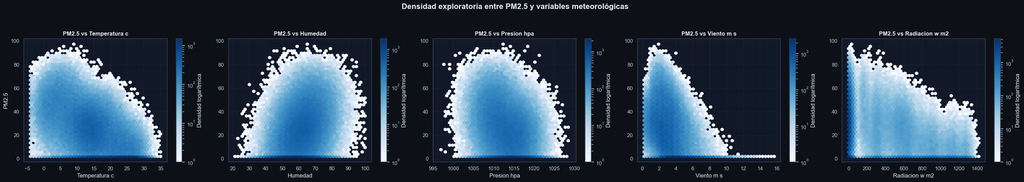

```python
# =============================================================================
# 8. PANEL EXPLORATORIO: RELACIÓN PM2.5 Y VARIABLES METEOROLÓGICAS
# Visualización mediante Hexbin de densidad
# =============================================================================

import re
import unicodedata
import pandas as pd
import matplotlib.pyplot as plt
from IPython.display import display, HTML

# -----------------------------------------------------------------------------
# 1) Localización automática del DataFrame principal
# -----------------------------------------------------------------------------

candidatos_df = [
    "df",
    "df_limpio",
    "df_normalizado",
    "df_final",
    "df_procesado",
    "df_eventos",
    "df_eventos_criticos",
    "sinca_limpio",
    "dataset"
]

df_encontrado = None

for nombre in candidatos_df:
    if nombre in globals() and isinstance(globals()[nombre], pd.DataFrame):
        if len(globals()[nombre]) > 0:
            df_encontrado = nombre
            break

if df_encontrado is None:
    dataframes_memoria = [
        nombre for nombre, valor in globals().items()
        if isinstance(valor, pd.DataFrame)
    ]

    raise NameError(
        "No se encontró un DataFrame principal válido en memoria. "
        f"DataFrames disponibles: {dataframes_memoria}. "
        "Ejecute primero las etapas de carga, limpieza y normalización."
    )

print(f"DataFrame utilizado: {df_encontrado}")

df_plot = globals()[df_encontrado].copy()

# -----------------------------------------------------------------------------
# 2) Normalización segura de nombres de columnas
# -----------------------------------------------------------------------------

def normalizar_columna(col):
    col = str(col).strip()
    col = col.replace("µ", "u")
    col = unicodedata.normalize("NFKD", col)
    col = "".join(c for c in col if not unicodedata.combining(c))
    col = col.lower()
    col = re.sub(r"[^a-z0-9]+", "_", col)
    col = re.sub(r"_+", "_", col)
    return col.strip("_")

df_plot.columns = [normalizar_columna(c) for c in df_plot.columns]

# -----------------------------------------------------------------------------
# 3) Detección robusta de columnas
# -----------------------------------------------------------------------------

def detectar_columna(df_base, patrones):
    for col in df_base.columns:
        col_norm = normalizar_columna(col)
        if any(p in col_norm for p in patrones):
            return col
    return None

variable_objetivo = detectar_columna(
    df_plot,
    ["mp2_5", "pm2_5", "mp25", "pm25"]
)

if variable_objetivo is None:
    raise KeyError(
        "No se detectó columna objetivo para PM2.5. "
        f"Columnas disponibles: {df_plot.columns.tolist()}"
    )

mapa_meteorologico = {
    "temperatura": ["temperatura", "temp"],
    "humedad": ["humedad", "humidity", "hr"],
    "presion": ["presion", "pressure"],
    "viento": ["viento", "velocidad_viento", "wind"],
    "radiacion": ["radiacion", "radiation", "solar"]
}

variables_disponibles = []
variables_faltantes = []

for nombre_estandar, patrones in mapa_meteorologico.items():
    col_detectada = detectar_columna(df_plot, patrones)

    if col_detectada is not None:
        if col_detectada not in variables_disponibles:
            variables_disponibles.append(col_detectada)
    else:
        variables_faltantes.append(nombre_estandar)

if not variables_disponibles:
    raise KeyError(
        "No se encontraron variables meteorológicas disponibles para graficar. "
        f"Columnas disponibles: {df_plot.columns.tolist()}"
    )

print(f"Variable objetivo detectada: {variable_objetivo}")
print(f"Variables meteorológicas detectadas: {variables_disponibles}")
print(f"Variables meteorológicas no detectadas: {variables_faltantes}")

# -----------------------------------------------------------------------------
# 4) Preparación de datos
# -----------------------------------------------------------------------------

columnas_analisis = [variable_objetivo] + variables_disponibles

for col in columnas_analisis:
    df_plot[col] = pd.to_numeric(df_plot[col], errors="coerce")

registros_antes = len(df_plot)

df_plot = (
    df_plot
    .dropna(subset=columnas_analisis)
    .reset_index(drop=True)
)

registros_finales = len(df_plot)
registros_eliminados = registros_antes - registros_finales

if registros_finales == 0:
    raise ValueError(
        "Después de eliminar nulos en PM2.5 y variables meteorológicas, "
        "no quedaron registros válidos para graficar."
    )

# -----------------------------------------------------------------------------
# 5) Correlaciones exploratorias
# -----------------------------------------------------------------------------

correlaciones = (
    df_plot[columnas_analisis]
    .corr(numeric_only=True)[variable_objetivo]
    .drop(variable_objetivo)
    .sort_values(key=lambda s: s.abs(), ascending=False)
    .reset_index()
)

correlaciones.columns = ["Variable meteorológica", "Correlación con PM2.5"]
correlaciones["Correlación con PM2.5"] = (
    correlaciones["Correlación con PM2.5"]
    .round(3)
)

variable_mas_relacionada = correlaciones.iloc[0]["Variable meteorológica"]
corr_mas_relacionada = correlaciones.iloc[0]["Correlación con PM2.5"]

# -----------------------------------------------------------------------------
# 6) Cuadro resumen HTML profesional
# -----------------------------------------------------------------------------

html_panel = f"""
<div style="
    width:100%;
    box-sizing:border-box;
    background:#F4F7FA;
    color:#111827;
    padding:20px;
    border-left:6px solid #1F3A5F;
    border-radius:10px;
    font-family:Arial,Helvetica,sans-serif;
    margin-top:16px;
    margin-bottom:16px;
">
<h3 style="margin-top:0;color:#1F3A5F;text-align:left;">
📈 8. Panel Exploratorio PM2.5 vs Variables Meteorológicas
</h3>
<table style="width:100%;border-collapse:collapse;font-size:14px;color:#111827;text-align:left;">
  <tr><td style="padding:8px;border:1px solid #cbd5e1;font-weight:bold;text-align:left;">DataFrame utilizado</td><td style="padding:8px;border:1px solid #cbd5e1;text-align:left;">{df_encontrado}</td></tr>
  <tr><td style="padding:8px;border:1px solid #cbd5e1;font-weight:bold;text-align:left;">Variable objetivo detectada</td><td style="padding:8px;border:1px solid #cbd5e1;text-align:left;">{variable_objetivo}</td></tr>
  <tr><td style="padding:8px;border:1px solid #cbd5e1;font-weight:bold;text-align:left;">Tipo de visualización</td><td style="padding:8px;border:1px solid #cbd5e1;text-align:left;">Hexbin de densidad</td></tr>
  <tr><td style="padding:8px;border:1px solid #cbd5e1;font-weight:bold;text-align:left;">Variables meteorológicas disponibles</td><td style="padding:8px;border:1px solid #cbd5e1;text-align:left;">{', '.join(variables_disponibles)}</td></tr>
  <tr><td style="padding:8px;border:1px solid #cbd5e1;font-weight:bold;text-align:left;">Variables no disponibles</td><td style="padding:8px;border:1px solid #cbd5e1;text-align:left;">{', '.join(variables_faltantes) if variables_faltantes else 'Ninguna'}</td></tr>
  <tr><td style="padding:8px;border:1px solid #cbd5e1;font-weight:bold;text-align:left;">Registros iniciales</td><td style="padding:8px;border:1px solid #cbd5e1;text-align:left;">{registros_antes:,}</td></tr>
  <tr><td style="padding:8px;border:1px solid #cbd5e1;font-weight:bold;text-align:left;">Registros usados en gráficos</td><td style="padding:8px;border:1px solid #cbd5e1;text-align:left;">{registros_finales:,}</td></tr>
  <tr><td style="padding:8px;border:1px solid #cbd5e1;font-weight:bold;text-align:left;">Registros excluidos por nulos</td><td style="padding:8px;border:1px solid #cbd5e1;text-align:left;">{registros_eliminados:,}</td></tr>
  <tr><td style="padding:8px;border:1px solid #cbd5e1;font-weight:bold;text-align:left;">Variable con mayor relación absoluta</td><td style="padding:8px;border:1px solid #cbd5e1;text-align:left;">{variable_mas_relacionada}</td></tr>
  <tr><td style="padding:8px;border:1px solid #cbd5e1;font-weight:bold;text-align:left;">Correlación observada</td><td style="padding:8px;border:1px solid #cbd5e1;text-align:left;">{corr_mas_relacionada}</td></tr>
</table>
<p style="margin-top:16px;margin-bottom:0;line-height:1.6;font-size:14px;color:#111827;text-align:left;">
<strong>Conclusión técnica:</strong>
Se construyó un panel exploratorio mediante mapas de densidad tipo Hexbin,
técnica adecuada para datasets de gran volumen porque permite identificar zonas
de mayor concentración de observaciones sin saturar visualmente el gráfico.
</p>
</div>
"""
display(HTML(html_panel))

print("Correlaciones entre PM2.5 y variables meteorológicas:")
display(correlaciones)

# -----------------------------------------------------------------------------
# 7) Visualización Hexbin de densidad en tonos azules
# -----------------------------------------------------------------------------

n_vars = len(variables_disponibles)

fig, axes = plt.subplots(
    1,
    n_vars,
    figsize=(max(6 * n_vars, 12), 5),
    squeeze=False
)

axes = axes.flatten()

for i, var in enumerate(variables_disponibles):

    hb = axes[i].hexbin(
        df_plot[var],
        df_plot[variable_objetivo],
        gridsize=45,
        mincnt=1,
        cmap="Blues",
        bins="log"
    )

    titulo_var = var.replace("_", " ").capitalize()

    axes[i].set_title(
        f"PM2.5 vs {titulo_var}",
        fontsize=12,
        fontweight="bold"
    )

    axes[i].set_xlabel(titulo_var)
    axes[i].set_ylabel("PM2.5" if i == 0 else "")
    axes[i].grid(True, alpha=0.25)

    cbar = fig.colorbar(hb, ax=axes[i])
    cbar.set_label("Densidad logarítmica")

fig.suptitle(
    "Densidad exploratoria entre PM2.5 y variables meteorológicas",
    fontsize=16,
    fontweight="bold",
    y=1.05
)

plt.tight_layout()
plt.show()
```

# 🧩 9. Construcción del DataFrame con Variables Booleanas

El DataFrame **mp25_diario**, construido a partir de promedios diarios por **fecha, comuna y estación**, requiere reincorporar variables cualitativas booleanas como **inversion_termica**, **es_finde** y **es_festivo**. Dado que estas variables no siempre se conservan durante la agregación diaria, este bloque reconstruye un nuevo DataFrame denominado **mp25_diario_con_boolean**, preservando dichas condiciones mediante el primer valor válido observado por cada grupo analítico.

**Objetivo técnico:** habilitar el análisis comparativo de la distribución de **PM2.5 promedio diario** según condiciones booleanas relevantes, fortaleciendo la trazabilidad metodológica, la reproducibilidad del notebook y la interpretación ambiental de los resultados.

```python
# =============================================================================
# 9. CONSTRUCCIÓN DEL DATAFRAME CON VARIABLES BOOLEANAS
# Proyecto F4 (Entrega final): Calidad del Aire en Santiago
# =============================================================================

import re
import unicodedata
import pandas as pd
from IPython.display import display, HTML

# -----------------------------------------------------------------------------
# 1) Funciones utilitarias
# -----------------------------------------------------------------------------

def normalizar_columna(col):
    col = str(col).strip()
    col = col.replace("µ", "u")
    col = unicodedata.normalize("NFKD", col)
    col = "".join(c for c in col if not unicodedata.combining(c))
    col = col.lower()
    col = re.sub(r"[^a-z0-9]+", "_", col)
    col = re.sub(r"_+", "_", col)
    return col.strip("_")


def detectar_columna(df_base, patrones):
    for col in df_base.columns:
        col_norm = normalizar_columna(col)
        if any(p in col_norm for p in patrones):
            return col
    return None


# -----------------------------------------------------------------------------
# 2) Localizar automáticamente DataFrame base
# -----------------------------------------------------------------------------

candidatos_df = [
    "df_filtrado",
    "df",
    "df_limpio",
    "df_normalizado",
    "df_final",
    "df_procesado",
    "sinca_limpio",
    "dataset"
]

df_base_nombre = None

for nombre in candidatos_df:
    if nombre in globals() and isinstance(globals()[nombre], pd.DataFrame):
        if len(globals()[nombre]) > 0:
            df_base_nombre = nombre
            break

if df_base_nombre is None:
    disponibles = [
        nombre for nombre, valor in globals().items()
        if isinstance(valor, pd.DataFrame)
    ]
    raise NameError(
        "No se encontró ningún DataFrame válido en memoria. "
        f"DataFrames disponibles: {disponibles}. "
        "Ejecute primero la carga, limpieza o normalización del dataset."
    )

df_bool = globals()[df_base_nombre].copy()
df_bool.columns = [normalizar_columna(c) for c in df_bool.columns]

print(f"DataFrame base utilizado: {df_base_nombre}")
print(f"Filas iniciales: {len(df_bool):,}")
print(f"Columnas iniciales: {len(df_bool.columns):,}")

# -----------------------------------------------------------------------------
# 3) Detección robusta de columnas principales
# -----------------------------------------------------------------------------

col_fecha = detectar_columna(df_bool, ["fecha"])
col_comuna = detectar_columna(df_bool, ["comuna"])
col_estacion = detectar_columna(df_bool, ["estacion"])
col_pm25 = detectar_columna(df_bool, ["mp2_5", "pm2_5", "mp25", "pm25"])

columnas_detectadas = {
    "fecha": col_fecha,
    "comuna": col_comuna,
    "estacion": col_estacion,
    "mp2_5": col_pm25
}

faltantes = [k for k, v in columnas_detectadas.items() if v is None]

if faltantes:
    raise KeyError(
        f"Faltan columnas críticas: {faltantes}. "
        f"Columnas disponibles: {df_bool.columns.tolist()}"
    )

df_bool = df_bool.rename(columns={
    col_fecha: "fecha",
    col_comuna: "comuna",
    col_estacion: "estacion",
    col_pm25: "mp2_5"
})

# -----------------------------------------------------------------------------
# 4) Crear solo_fecha
# -----------------------------------------------------------------------------

df_bool["fecha"] = pd.to_datetime(df_bool["fecha"], errors="coerce")
df_bool = df_bool.dropna(subset=["fecha"]).copy()
df_bool["solo_fecha"] = df_bool["fecha"].dt.date

# -----------------------------------------------------------------------------
# 5) Variables booleanas esperadas
# -----------------------------------------------------------------------------

variables_bool = [
    "inversion_termica",
    "es_finde",
    "es_festivo"
]

bool_presentes = [c for c in variables_bool if c in df_bool.columns]
bool_faltantes = [c for c in variables_bool if c not in df_bool.columns]

# Si no existen, se reconstruyen parcialmente
if "es_finde" not in df_bool.columns:
    df_bool["es_finde"] = df_bool["fecha"].dt.dayofweek.isin([5, 6]).astype(int)
    bool_presentes.append("es_finde")
    bool_faltantes = [c for c in bool_faltantes if c != "es_finde"]

if "es_festivo" not in df_bool.columns:
    df_bool["es_festivo"] = 0
    bool_presentes.append("es_festivo")
    bool_faltantes = [c for c in bool_faltantes if c != "es_festivo"]

if "inversion_termica" not in df_bool.columns:
    df_bool["inversion_termica"] = 0
    bool_presentes.append("inversion_termica")
    bool_faltantes = [c for c in bool_faltantes if c != "inversion_termica"]

bool_presentes = list(dict.fromkeys(bool_presentes))

# -----------------------------------------------------------------------------
# 6) Normalización de booleanas
# -----------------------------------------------------------------------------

for col in bool_presentes:
    df_bool[col] = (
        df_bool[col]
        .astype(str)
        .str.strip()
        .str.lower()
        .map({
            "sí": 1,
            "si": 1,
            "true": 1,
            "1": 1,
            "yes": 1,
            "no": 0,
            "false": 0,
            "0": 0
        })
        .fillna(0)
        .astype(int)
    )

# -----------------------------------------------------------------------------
# 7) Validación numérica PM2.5
# -----------------------------------------------------------------------------

df_bool["mp2_5"] = pd.to_numeric(df_bool["mp2_5"], errors="coerce")

registros_antes = len(df_bool)

df_bool = df_bool.dropna(
    subset=["mp2_5", "solo_fecha", "comuna", "estacion"]
).copy()

registros_despues = len(df_bool)
registros_eliminados = registros_antes - registros_despues

if registros_despues == 0:
    raise ValueError(
        "No quedaron registros válidos después de limpiar PM2.5, fecha, comuna y estación."
    )

# -----------------------------------------------------------------------------
# 8) Agregación diaria
# -----------------------------------------------------------------------------

columnas_grupo = ["solo_fecha", "comuna", "estacion"]

agg_dict = {
    "mp2_5": "mean"
}

for col in bool_presentes:
    agg_dict[col] = "first"

mp25_diario_con_boolean = (
    df_bool
    .groupby(columnas_grupo, as_index=False)
    .agg(agg_dict)
    .rename(columns={
        "mp2_5": "mp2_5_promedio_diario"
    })
)

# -----------------------------------------------------------------------------
# 9) Métricas ejecutivas
# -----------------------------------------------------------------------------

filas_finales = len(mp25_diario_con_boolean)
dias_analizados = mp25_diario_con_boolean["solo_fecha"].nunique()
comunas_analizadas = mp25_diario_con_boolean["comuna"].nunique()
estaciones_analizadas = mp25_diario_con_boolean["estacion"].nunique()

promedio_pm25 = mp25_diario_con_boolean["mp2_5_promedio_diario"].mean()
max_pm25 = mp25_diario_con_boolean["mp2_5_promedio_diario"].max()

# -----------------------------------------------------------------------------
# 10) Resumen ejecutivo HTML
# -----------------------------------------------------------------------------

html_bool = f"""
<div style="
    width:100%;
    box-sizing:border-box;
    background:#F4F7FA;
    color:#111827;
    padding:20px;
    border-left:6px solid #1F3A5F;
    border-radius:10px;
    font-family:Arial,Helvetica,sans-serif;
    margin-top:16px;
    margin-bottom:16px;
">
<h3 style="margin-top:0;margin-bottom:15px;font-size:22px;font-weight:700;color:#1F3A5F;text-align:left;">
🧩 9. Resultado de Construcción del DataFrame con Variables Booleanas
</h3>
<table style="width:100%;border-collapse:collapse;font-size:14px;color:#111827;text-align:left;">
  <tr><td style="padding:8px;border:1px solid #cbd5e1;font-weight:bold;text-align:left;">DataFrame base utilizado</td><td style="padding:8px;border:1px solid #cbd5e1;text-align:left;">{df_base_nombre}</td></tr>
  <tr><td style="padding:8px;border:1px solid #cbd5e1;font-weight:bold;text-align:left;">Filas originales</td><td style="padding:8px;border:1px solid #cbd5e1;text-align:left;">{registros_antes:,}</td></tr>
  <tr><td style="padding:8px;border:1px solid #cbd5e1;font-weight:bold;text-align:left;">Filas válidas tras limpieza</td><td style="padding:8px;border:1px solid #cbd5e1;text-align:left;">{registros_despues:,}</td></tr>
  <tr><td style="padding:8px;border:1px solid #cbd5e1;font-weight:bold;text-align:left;">Filas eliminadas</td><td style="padding:8px;border:1px solid #cbd5e1;text-align:left;">{registros_eliminados:,}</td></tr>
  <tr><td style="padding:8px;border:1px solid #cbd5e1;font-weight:bold;text-align:left;">Filas finales agregadas</td><td style="padding:8px;border:1px solid #cbd5e1;text-align:left;">{filas_finales:,}</td></tr>
  <tr><td style="padding:8px;border:1px solid #cbd5e1;font-weight:bold;text-align:left;">Días analizados</td><td style="padding:8px;border:1px solid #cbd5e1;text-align:left;">{dias_analizados:,}</td></tr>
  <tr><td style="padding:8px;border:1px solid #cbd5e1;font-weight:bold;text-align:left;">Comunas analizadas</td><td style="padding:8px;border:1px solid #cbd5e1;text-align:left;">{comunas_analizadas:,}</td></tr>
  <tr><td style="padding:8px;border:1px solid #cbd5e1;font-weight:bold;text-align:left;">Estaciones analizadas</td><td style="padding:8px;border:1px solid #cbd5e1;text-align:left;">{estaciones_analizadas:,}</td></tr>
  <tr><td style="padding:8px;border:1px solid #cbd5e1;font-weight:bold;text-align:left;">Booleanas incorporadas</td><td style="padding:8px;border:1px solid #cbd5e1;text-align:left;">{', '.join(bool_presentes)}</td></tr>
  <tr><td style="padding:8px;border:1px solid #cbd5e1;font-weight:bold;text-align:left;">Booleanas no disponibles originalmente</td><td style="padding:8px;border:1px solid #cbd5e1;text-align:left;">{', '.join(bool_faltantes) if bool_faltantes else 'Ninguna'}</td></tr>
  <tr><td style="padding:8px;border:1px solid #cbd5e1;font-weight:bold;text-align:left;">PM2.5 promedio diario global</td><td style="padding:8px;border:1px solid #cbd5e1;text-align:left;">{promedio_pm25:.2f} µg/m³</td></tr>
  <tr><td style="padding:8px;border:1px solid #cbd5e1;font-weight:bold;text-align:left;">PM2.5 máximo diario</td><td style="padding:8px;border:1px solid #cbd5e1;text-align:left;">{max_pm25:.2f} µg/m³</td></tr>
</table>
<p style="margin-top:16px;margin-bottom:0;line-height:1.6;font-size:14px;color:#111827;text-align:left;">
<strong>Conclusión técnica:</strong>
Se reconstruyó un DataFrame diario por fecha, comuna y estación, conservando variables booleanas
relevantes para el análisis exploratorio. Esta estructura permite evaluar la distribución del PM2.5
según condiciones cualitativas como fin de semana, festivos e inversión térmica, fortaleciendo la
trazabilidad metodológica del análisis.
</p>
</div>
"""

display(HTML(html_bool))

# -----------------------------------------------------------------------------
# 11) Evidencia controlada
# -----------------------------------------------------------------------------

print("Vista preliminar del DataFrame diario con variables booleanas:")
display(mp25_diario_con_boolean.head(10))

print("Columnas finales:")
print(list(mp25_diario_con_boolean.columns))
```

```
DataFrame base utilizado: df
Filas iniciales: 178,709
Columnas iniciales: 14
```

🧩 9. Resultado de Construcción del DataFrame con Variables Booleanas

| DataFrame base utilizado | df |
| --- | --- |
| Filas originales | 178,709 |
| Filas válidas tras limpieza | 178,709 |
| Filas eliminadas | 0 |
| Filas finales agregadas | 8,030 |
| Días analizados | 730 |
| Comunas analizadas | 11 |
| Estaciones analizadas | 11 |
| Booleanas incorporadas | inversion_termica, es_finde, es_festivo |
| Booleanas no disponibles originalmente | Ninguna |
| PM2.5 promedio diario global | 26.18 µg/m³ |
| PM2.5 máximo diario | 58.94 µg/m³ |

**Conclusión técnica:** Se reconstruyó un DataFrame diario por fecha, comuna y estación, conservando variables booleanas relevantes para el análisis exploratorio. Esta estructura permite evaluar la distribución del PM2.5 según condiciones cualitativas como fin de semana, festivos e inversión térmica, fortaleciendo la trazabilidad metodológica del análisis.

```
Vista preliminar del DataFrame diario con variables booleanas:
```

|  | solo_fecha | comuna | estacion | mp2_5_promedio_diario | inversion_termica | es_finde | es_festivo |
| --- | --- | --- | --- | --- | --- | --- | --- |
| 0 | 2022-01-01 | Cerrillos | Cerrillos | 14.236 | 1 | 1 | 1 |
| 1 | 2022-01-01 | Cerro Navia | Cerro Navia | 15.916 | 1 | 1 | 1 |
| 2 | 2022-01-01 | El Bosque | El Bosque | 16.196 | 1 | 1 | 1 |
| 3 | 2022-01-01 | Independencia | Independencia | 13.200 | 1 | 1 | 1 |
| 4 | 2022-01-01 | La Florida | La Florida | 12.724 | 0 | 1 | 1 |
| 5 | 2022-01-01 | Las Condes | Las Condes | 9.124 | 0 | 1 | 1 |
| 6 | 2022-01-01 | Providencia | Providencia | 7.750 | 0 | 1 | 1 |
| 7 | 2022-01-01 | Pudahuel | Pudahuel | 11.091 | 1 | 1 | 1 |
| 8 | 2022-01-01 | Puente Alto | Puente Alto | 12.743 | 1 | 1 | 1 |
| 9 | 2022-01-01 | Quilicura | Quilicura | 12.390 | 1 | 1 | 1 |

```
Columnas finales:
['solo_fecha', 'comuna', 'estacion', 'mp2_5_promedio_diario', 'inversion_termica', 'es_finde', 'es_festivo']
```

📦 9.1 Boxplot de MP2.5 según Variables Booleanas

| DataFrame utilizado | mp25_diario_con_boolean |
| --- | --- |
| Variable objetivo | mp2_5_promedio_diario |
| Variables booleanas graficadas | inversion_termica, es_finde, es_festivo |
| Registros iniciales | 8,030 |
| Registros usados | 8,030 |
| Registros excluidos | 0 |
| Umbral PM2.5 | 49 µg/m³ |
| Variable con mayor diferencia media | inversion_termica |
| Diferencia media observada | 6.21 µg/m³ |

**Conclusión técnica:** Los boxplots permiten comparar la distribución del PM2.5 promedio diario según condiciones booleanas. Esta visualización facilita identificar diferencias de concentración entre días con y sin determinada condición, apoyando el análisis exploratorio previo a conclusiones ambientales.

```
Resumen estadístico por variable booleana:
```

|  | Variable | Registros 0 | Registros 1 | Media PM2.5 cuando 0 | Media PM2.5 cuando 1 | Diferencia media |
| --- | --- | --- | --- | --- | --- | --- |
| 0 | inversion_termica | 3895 | 4135 | 22.990 | 29.200 | 6.210 |
| 1 | es_finde | 5720 | 2310 | 27.740 | 22.340 | -5.390 |
| 2 | es_festivo | 7656 | 374 | 26.450 | 20.790 | -5.660 |

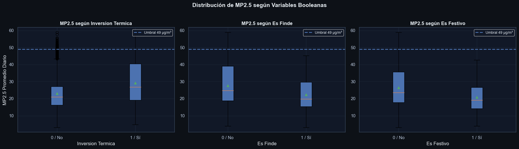

```python
# =============================================================================
# 9.1 BOXPLOT DE MP2.5 SEGÚN VARIABLES BOOLEANAS
# Proyecto F4 (Entrega final): Calidad del Aire en Santiago
# =============================================================================

import pandas as pd
import matplotlib.pyplot as plt
from IPython.display import display, HTML

import warnings

warnings.filterwarnings("ignore")

# -----------------------------------------------------------------------------
# 1) Validaciones base
# -----------------------------------------------------------------------------

if "mp25_diario_con_boolean" not in globals():
    raise NameError(
        "No existe el DataFrame 'mp25_diario_con_boolean'. "
        "Ejecute primero el punto 9."
    )

if not isinstance(mp25_diario_con_boolean, pd.DataFrame):
    raise TypeError(
        "'mp25_diario_con_boolean' existe, pero no es un DataFrame de pandas."
    )

if mp25_diario_con_boolean.empty:
    raise ValueError(
        "'mp25_diario_con_boolean' está vacío. "
        "Revise la construcción del punto 9."
    )

df_box = mp25_diario_con_boolean.copy()

# -----------------------------------------------------------------------------
# 2) Validar variable objetivo
# -----------------------------------------------------------------------------

col_objetivo = "mp2_5_promedio_diario"

if col_objetivo not in df_box.columns:
    raise KeyError(
        f"No existe la columna '{col_objetivo}'. "
        f"Columnas disponibles: {df_box.columns.tolist()}"
    )

df_box[col_objetivo] = pd.to_numeric(
    df_box[col_objetivo],
    errors="coerce"
)

# -----------------------------------------------------------------------------
# 3) Detectar variables booleanas
# -----------------------------------------------------------------------------

variables_bool_esperadas = [
    "inversion_termica",
    "es_finde",
    "es_festivo"
]

cols_plot = [
    c for c in variables_bool_esperadas
    if c in df_box.columns
]

if len(cols_plot) == 0:
    raise ValueError(
        "No existen variables booleanas disponibles para graficar. "
        f"Columnas disponibles: {df_box.columns.tolist()}"
    )

# -----------------------------------------------------------------------------
# 4) Normalización robusta de booleanas
# -----------------------------------------------------------------------------

mapa_bool = {
    "sí": 1,
    "si": 1,
    "true": 1,
    "1": 1,
    "yes": 1,
    "y": 1,
    "no": 0,
    "false": 0,
    "0": 0,
    "n": 0
}

for var in cols_plot:
    df_box[var] = (
        df_box[var]
        .astype(str)
        .str.strip()
        .str.lower()
        .replace(mapa_bool)
    )

    df_box[var] = pd.to_numeric(
        df_box[var],
        errors="coerce"
    )

# -----------------------------------------------------------------------------
# 5) Limpieza final para visualización
# -----------------------------------------------------------------------------

registros_antes = len(df_box)

df_box = df_box.dropna(
    subset=[col_objetivo] + cols_plot
).reset_index(drop=True)

registros_finales = len(df_box)
registros_eliminados = registros_antes - registros_finales

if registros_finales == 0:
    raise ValueError(
        "No quedaron registros válidos para construir los boxplots."
    )

# -----------------------------------------------------------------------------
# 6) Métricas ejecutivas
# -----------------------------------------------------------------------------

UMBRAL25 = 49

resumen_bool = []

for var in cols_plot:
    conteo = df_box[var].value_counts().to_dict()
    n_0 = int(conteo.get(0, 0))
    n_1 = int(conteo.get(1, 0))

    media_0 = df_box.loc[df_box[var] == 0, col_objetivo].mean()
    media_1 = df_box.loc[df_box[var] == 1, col_objetivo].mean()

    resumen_bool.append({
        "Variable": var,
        "Registros 0": n_0,
        "Registros 1": n_1,
        "Media PM2.5 cuando 0": round(media_0, 2) if pd.notna(media_0) else None,
        "Media PM2.5 cuando 1": round(media_1, 2) if pd.notna(media_1) else None,
        "Diferencia media": round(media_1 - media_0, 2) if pd.notna(media_0) and pd.notna(media_1) else None
    })

resumen_bool_df = pd.DataFrame(resumen_bool)

variable_mayor_diferencia = (
    resumen_bool_df
    .dropna(subset=["Diferencia media"])
    .assign(abs_diff=lambda x: x["Diferencia media"].abs())
    .sort_values("abs_diff", ascending=False)
)

if not variable_mayor_diferencia.empty:
    variable_clave = variable_mayor_diferencia.iloc[0]["Variable"]
    diferencia_clave = variable_mayor_diferencia.iloc[0]["Diferencia media"]
else:
    variable_clave = "No calculable"
    diferencia_clave = 0

# -----------------------------------------------------------------------------
# 7) Resumen ejecutivo HTML
# -----------------------------------------------------------------------------

html_box = f"""
<div style="
    width:100%;
    box-sizing:border-box;
    background:#F4F7FA;
    color:#111827;
    padding:20px;
    border-left:6px solid #1F3A5F;
    border-radius:10px;
    font-family:Arial,Helvetica,sans-serif;
    margin-top:16px;
    margin-bottom:16px;
">
<h3 style="margin-top:0;margin-bottom:15px;font-size:22px;font-weight:700;color:#1F3A5F;text-align:left;">
📦 9.1 Boxplot de MP2.5 según Variables Booleanas
</h3>
<table style="width:100%;border-collapse:collapse;font-size:14px;color:#111827;text-align:left;">
  <tr><td style="padding:8px;border:1px solid #cbd5e1;font-weight:bold;text-align:left;">DataFrame utilizado</td><td style="padding:8px;border:1px solid #cbd5e1;text-align:left;">mp25_diario_con_boolean</td></tr>
  <tr><td style="padding:8px;border:1px solid #cbd5e1;font-weight:bold;text-align:left;">Variable objetivo</td><td style="padding:8px;border:1px solid #cbd5e1;text-align:left;">{col_objetivo}</td></tr>
  <tr><td style="padding:8px;border:1px solid #cbd5e1;font-weight:bold;text-align:left;">Variables booleanas graficadas</td><td style="padding:8px;border:1px solid #cbd5e1;text-align:left;">{', '.join(cols_plot)}</td></tr>
  <tr><td style="padding:8px;border:1px solid #cbd5e1;font-weight:bold;text-align:left;">Registros iniciales</td><td style="padding:8px;border:1px solid #cbd5e1;text-align:left;">{registros_antes:,}</td></tr>
  <tr><td style="padding:8px;border:1px solid #cbd5e1;font-weight:bold;text-align:left;">Registros usados</td><td style="padding:8px;border:1px solid #cbd5e1;text-align:left;">{registros_finales:,}</td></tr>
  <tr><td style="padding:8px;border:1px solid #cbd5e1;font-weight:bold;text-align:left;">Registros excluidos</td><td style="padding:8px;border:1px solid #cbd5e1;text-align:left;">{registros_eliminados:,}</td></tr>
  <tr><td style="padding:8px;border:1px solid #cbd5e1;font-weight:bold;text-align:left;">Umbral PM2.5</td><td style="padding:8px;border:1px solid #cbd5e1;text-align:left;">{UMBRAL25} µg/m³</td></tr>
  <tr><td style="padding:8px;border:1px solid #cbd5e1;font-weight:bold;text-align:left;">Variable con mayor diferencia media</td><td style="padding:8px;border:1px solid #cbd5e1;text-align:left;">{variable_clave}</td></tr>
  <tr><td style="padding:8px;border:1px solid #cbd5e1;font-weight:bold;text-align:left;">Diferencia media observada</td><td style="padding:8px;border:1px solid #cbd5e1;text-align:left;">{diferencia_clave} µg/m³</td></tr>
</table>
<p style="margin-top:16px;margin-bottom:0;line-height:1.6;font-size:14px;color:#111827;text-align:left;">
<strong>Conclusión técnica:</strong>
Los boxplots permiten comparar la distribución del PM2.5 promedio diario según condiciones booleanas.
Esta visualización facilita identificar diferencias de concentración entre días con y sin determinada
condición, apoyando el análisis exploratorio previo a conclusiones ambientales.
</p>
</div>
"""
display(HTML(html_box))

print("Resumen estadístico por variable booleana:")
display(resumen_bool_df)

# -----------------------------------------------------------------------------
# 8) Visualización profesional con Matplotlib
# -----------------------------------------------------------------------------

n = len(cols_plot)

fig, axes = plt.subplots(
    1,
    n,
    figsize=(6 * n, 5),
    squeeze=False
)

axes = axes.flatten()

for idx, var in enumerate(cols_plot):

    datos_0 = df_box.loc[df_box[var] == 0, col_objetivo].dropna()
    datos_1 = df_box.loc[df_box[var] == 1, col_objetivo].dropna()

    datos_plot = [datos_0, datos_1]
    labels = ["0 / No", "1 / Sí"]

    axes[idx].boxplot(
        datos_plot,
        tick_labels=labels,
        patch_artist=True,
        showmeans=True
    )

    titulo = var.replace("_", " ").title()

    axes[idx].set_title(
        f"MP2.5 según {titulo}",
        fontsize=12,
        fontweight="bold"
    )

    axes[idx].set_xlabel(titulo)

    if idx == 0:
        axes[idx].set_ylabel("MP2.5 Promedio Diario")
    else:
        axes[idx].set_ylabel("")

    axes[idx].axhline(
        UMBRAL25,
        linestyle="--",
        linewidth=2,
        label=f"Umbral {UMBRAL25} µg/m³"
    )

    axes[idx].legend(
        loc="upper right",
        fontsize=9
    )

    axes[idx].grid(
        axis="y",
        alpha=0.3
    )

fig.suptitle(
    "Distribución de MP2.5 según Variables Booleanas",
    fontsize=14,
    fontweight="bold",
    y=1.02
)

plt.tight_layout()
plt.show()
```

📈 9.2 Evolución Temporal de MP2.5 por Comuna

| DataFrame utilizado | mp25_diario_con_boolean |
| --- | --- |
| Registros iniciales | 8,030 |
| Registros utilizados | 8,030 |
| Registros eliminados | 0 |
| Período analizado | 2022-01-01 a 2023-12-31 |
| Días analizados | 730 |
| Comunas analizadas | 11 |
| PM2.5 promedio global | 26.18 µg/m³ |
| PM2.5 máximo observado | 58.94 µg/m³ |
| Registros sobre umbral | 305 (3.80%) |
| Comuna con mayor promedio | Cerro Navia |

**Conclusión técnica:** La evolución temporal permite observar la variabilidad diaria del MP2.5 por comuna, identificando períodos de mayor concentración y comparando su comportamiento respecto del umbral normativo de referencia.

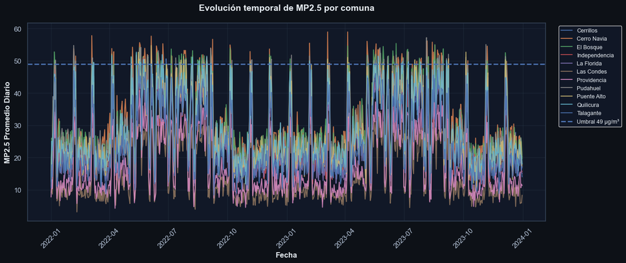

```python
# =============================================================================
# 9.2 EVOLUCIÓN TEMPORAL DE MP2.5 POR COMUNA
# Proyecto F4 (Entrega final): Calidad del Aire en Santiago
# =============================================================================

import pandas as pd
import matplotlib.pyplot as plt
from IPython.display import display, HTML

# -----------------------------------------------------------------------------
# 1) Selección robusta del DataFrame base
# -----------------------------------------------------------------------------

candidatos_df = [
    "mp25_diario",
    "mp25_diario_con_boolean",
    "df_eventos_criticos",
    "promedios_diarios",
    "df_final",
    "df_limpio",
    "df"
]

df_base_nombre = None

for nombre in candidatos_df:
    if nombre in globals() and isinstance(globals()[nombre], pd.DataFrame):
        if len(globals()[nombre]) > 0:
            df_base_nombre = nombre
            break

if df_base_nombre is None:
    disponibles = [
        nombre for nombre, valor in globals().items()
        if isinstance(valor, pd.DataFrame)
    ]
    raise NameError(
        "No se encontró un DataFrame válido para el análisis temporal. "
        f"DataFrames disponibles: {disponibles}. "
        "Ejecute primero los puntos anteriores."
    )

df_temporal = globals()[df_base_nombre].copy()

# -----------------------------------------------------------------------------
# 2) Validación de columnas requeridas
# -----------------------------------------------------------------------------

columnas_requeridas = [
    "solo_fecha",
    "comuna",
    "mp2_5_promedio_diario"
]

faltantes = [
    c for c in columnas_requeridas
    if c not in df_temporal.columns
]

if faltantes:
    raise KeyError(
        f"Faltan columnas requeridas: {faltantes}. "
        f"Columnas disponibles: {df_temporal.columns.tolist()}"
    )

# -----------------------------------------------------------------------------
# 3) Preparación y limpieza
# -----------------------------------------------------------------------------

df_temporal["solo_fecha"] = pd.to_datetime(
    df_temporal["solo_fecha"],
    errors="coerce"
)

df_temporal["mp2_5_promedio_diario"] = pd.to_numeric(
    df_temporal["mp2_5_promedio_diario"],
    errors="coerce"
)

registros_antes = len(df_temporal)

df_temporal = (
    df_temporal
    .dropna(subset=["solo_fecha", "comuna", "mp2_5_promedio_diario"])
    .sort_values(["comuna", "solo_fecha"])
    .reset_index(drop=True)
)

registros_finales = len(df_temporal)
registros_eliminados = registros_antes - registros_finales

if registros_finales == 0:
    raise ValueError(
        "No quedaron registros válidos para graficar la evolución temporal."
    )

# -----------------------------------------------------------------------------
# 4) Métricas ejecutivas
# -----------------------------------------------------------------------------

UMBRAL25 = 49

dias_analizados = df_temporal["solo_fecha"].nunique()
comunas_analizadas = df_temporal["comuna"].nunique()
fecha_min = df_temporal["solo_fecha"].min().strftime("%Y-%m-%d")
fecha_max = df_temporal["solo_fecha"].max().strftime("%Y-%m-%d")

promedio_global = df_temporal["mp2_5_promedio_diario"].mean()
maximo_global = df_temporal["mp2_5_promedio_diario"].max()

episodios_sobre_umbral = int(
    (df_temporal["mp2_5_promedio_diario"] > UMBRAL25).sum()
)

porcentaje_sobre_umbral = (
    episodios_sobre_umbral / registros_finales * 100
    if registros_finales > 0
    else 0
)

comuna_max = (
    df_temporal
    .groupby("comuna")["mp2_5_promedio_diario"]
    .mean()
    .sort_values(ascending=False)
    .index[0]
)

# -----------------------------------------------------------------------------
# 5) Resumen ejecutivo HTML
# -----------------------------------------------------------------------------

html_temporal = f"""
<div style="
    width:100%;
    box-sizing:border-box;
    background:#F4F7FA;
    color:#111827;
    padding:20px;
    border-left:6px solid #1F3A5F;
    border-radius:10px;
    font-family:Arial,Helvetica,sans-serif;
    margin-top:16px;
    margin-bottom:16px;
">
<h3 style="margin-top:0;margin-bottom:15px;font-size:22px;font-weight:700;color:#1F3A5F;text-align:left;">
📈 9.2 Evolución Temporal de MP2.5 por Comuna
</h3>
<table style="width:100%;border-collapse:collapse;font-size:14px;color:#111827;text-align:left;">
  <tr><td style="padding:8px;border:1px solid #cbd5e1;font-weight:bold;text-align:left;">DataFrame utilizado</td><td style="padding:8px;border:1px solid #cbd5e1;text-align:left;">{df_base_nombre}</td></tr>
  <tr><td style="padding:8px;border:1px solid #cbd5e1;font-weight:bold;text-align:left;">Registros iniciales</td><td style="padding:8px;border:1px solid #cbd5e1;text-align:left;">{registros_antes:,}</td></tr>
  <tr><td style="padding:8px;border:1px solid #cbd5e1;font-weight:bold;text-align:left;">Registros utilizados</td><td style="padding:8px;border:1px solid #cbd5e1;text-align:left;">{registros_finales:,}</td></tr>
  <tr><td style="padding:8px;border:1px solid #cbd5e1;font-weight:bold;text-align:left;">Registros eliminados</td><td style="padding:8px;border:1px solid #cbd5e1;text-align:left;">{registros_eliminados:,}</td></tr>
  <tr><td style="padding:8px;border:1px solid #cbd5e1;font-weight:bold;text-align:left;">Período analizado</td><td style="padding:8px;border:1px solid #cbd5e1;text-align:left;">{fecha_min} a {fecha_max}</td></tr>
  <tr><td style="padding:8px;border:1px solid #cbd5e1;font-weight:bold;text-align:left;">Días analizados</td><td style="padding:8px;border:1px solid #cbd5e1;text-align:left;">{dias_analizados:,}</td></tr>
  <tr><td style="padding:8px;border:1px solid #cbd5e1;font-weight:bold;text-align:left;">Comunas analizadas</td><td style="padding:8px;border:1px solid #cbd5e1;text-align:left;">{comunas_analizadas:,}</td></tr>
  <tr><td style="padding:8px;border:1px solid #cbd5e1;font-weight:bold;text-align:left;">PM2.5 promedio global</td><td style="padding:8px;border:1px solid #cbd5e1;text-align:left;">{promedio_global:.2f} µg/m³</td></tr>
  <tr><td style="padding:8px;border:1px solid #cbd5e1;font-weight:bold;text-align:left;">PM2.5 máximo observado</td><td style="padding:8px;border:1px solid #cbd5e1;text-align:left;">{maximo_global:.2f} µg/m³</td></tr>
  <tr><td style="padding:8px;border:1px solid #cbd5e1;font-weight:bold;text-align:left;">Registros sobre umbral</td><td style="padding:8px;border:1px solid #cbd5e1;text-align:left;">{episodios_sobre_umbral:,} ({porcentaje_sobre_umbral:.2f}%)</td></tr>
  <tr><td style="padding:8px;border:1px solid #cbd5e1;font-weight:bold;text-align:left;">Comuna con mayor promedio</td><td style="padding:8px;border:1px solid #cbd5e1;text-align:left;">{comuna_max}</td></tr>
</table>
<p style="margin-top:16px;margin-bottom:0;line-height:1.6;font-size:14px;color:#111827;text-align:left;">
<strong>Conclusión técnica:</strong>
La evolución temporal permite observar la variabilidad diaria del MP2.5 por comuna,
identificando períodos de mayor concentración y comparando su comportamiento respecto
del umbral normativo de referencia.
</p>
</div>
"""

display(HTML(html_temporal))

# -----------------------------------------------------------------------------
# 6) Gráfico de evolución temporal
# -----------------------------------------------------------------------------

fig, ax = plt.subplots(figsize=(14, 6))

for comuna in sorted(df_temporal["comuna"].dropna().unique()):

    datos_comuna = (
        df_temporal[df_temporal["comuna"] == comuna]
        .sort_values("solo_fecha")
    )

    ax.plot(
        datos_comuna["solo_fecha"],
        datos_comuna["mp2_5_promedio_diario"],
        label=comuna,
        linewidth=1.5,
        alpha=0.85
    )

ax.axhline(
    UMBRAL25,
    linestyle="--",
    linewidth=2,
    label=f"Umbral {UMBRAL25} µg/m³"
)

ax.set_xlabel("Fecha", fontsize=12, fontweight="bold")
ax.set_ylabel("MP2.5 Promedio Diario", fontsize=12, fontweight="bold")

ax.set_title(
    "Evolución temporal de MP2.5 por comuna",
    fontsize=14,
    fontweight="bold",
    pad=20
)

ax.grid(True, alpha=0.3)

ax.legend(
    loc="upper left",
    bbox_to_anchor=(1.02, 1),
    fontsize=9,
    ncol=1,
    framealpha=0.95
)

plt.xticks(rotation=45)
plt.tight_layout()
plt.show()
```

📊 9.3 Promedio Mensual de MP2.5 por Comuna

| DataFrame utilizado | df |
| --- | --- |
| Columna temporal detectada | fecha |
| Columna PM2.5 detectada | mp2_5_ug_m3 |
| Registros iniciales | 178,709 |
| Registros válidos | 178,709 |
| Registros eliminados | 0 |
| Período mensual analizado | 2022-01 a 2023-12 |
| Meses analizados | 24 |
| Comunas analizadas | 11 |
| Promedio mensual global | 26.16 µg/m³ |
| Máximo mensual observado | 42.17 µg/m³ |
| Comuna / mes máximo | Cerro Navia / 2022-05 |
| Promedios mensuales sobre umbral | 0 (0.00%) |

**Conclusión técnica:** La agregación mensual reduce la volatilidad diaria y permite observar tendencias comparativas entre comunas. Esta visualización facilita identificar meses con mayor concentración promedio de MP2.5 y evaluar su comportamiento respecto del umbral normativo de referencia.

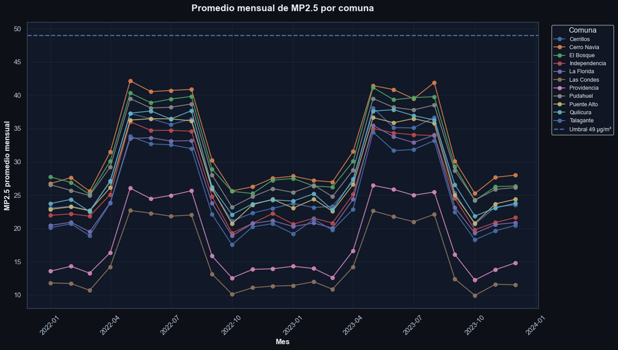

```python
# =============================================================================
# 9.3 PROMEDIO MENSUAL DE MP2.5 POR COMUNA
# Proyecto F4 (Entrega final): Calidad del Aire en Santiago
# =============================================================================

import re
import unicodedata
import pandas as pd
import matplotlib.pyplot as plt
import matplotlib.dates as mdates
from IPython.display import display, HTML

# -----------------------------------------------------------------------------
# 1) Funciones utilitarias
# -----------------------------------------------------------------------------

def normalizar_columna(col):
    col = str(col).strip()
    col = col.replace("µ", "u")
    col = unicodedata.normalize("NFKD", col)
    col = "".join(c for c in col if not unicodedata.combining(c))
    col = col.lower()
    col = re.sub(r"[^a-z0-9]+", "_", col)
    col = re.sub(r"_+", "_", col)
    return col.strip("_")


def detectar_columna(df_base, patrones):
    for col in df_base.columns:
        col_norm = normalizar_columna(col)
        if any(p in col_norm for p in patrones):
            return col
    return None


# -----------------------------------------------------------------------------
# 2) Selección robusta del DataFrame base
# -----------------------------------------------------------------------------

candidatos_df = [
    "df",
    "df_limpio",
    "df_normalizado",
    "df_final",
    "df_procesado",
    "mp25_diario_con_boolean",
    "mp25_diario",
    "df_eventos_criticos",
    "promedios_diarios"
]

df_base_nombre = None

for nombre in candidatos_df:
    if nombre in globals() and isinstance(globals()[nombre], pd.DataFrame):
        if len(globals()[nombre]) > 0:
            df_base_nombre = nombre
            break

if df_base_nombre is None:
    disponibles = [
        nombre for nombre, valor in globals().items()
        if isinstance(valor, pd.DataFrame)
    ]
    raise NameError(
        "No se encontró un DataFrame válido para el promedio mensual. "
        f"DataFrames disponibles: {disponibles}. "
        "Ejecute primero las etapas anteriores del notebook."
    )

mp25_mensual_raw = globals()[df_base_nombre].copy()
mp25_mensual_raw.columns = [normalizar_columna(c) for c in mp25_mensual_raw.columns]

# -----------------------------------------------------------------------------
# 3) Detección robusta de columnas
# -----------------------------------------------------------------------------

col_fecha = detectar_columna(
    mp25_mensual_raw,
    ["fecha", "solo_fecha", "fecha_dia"]
)

col_comuna = detectar_columna(
    mp25_mensual_raw,
    ["comuna"]
)

col_pm25 = detectar_columna(
    mp25_mensual_raw,
    [
        "mp2_5_promedio_diario",
        "mp2_5",
        "pm2_5",
        "mp25",
        "pm25",
        "mp2_5_ug_m3"
    ]
)

columnas_detectadas = {
    "fecha": col_fecha,
    "comuna": col_comuna,
    "pm2_5": col_pm25
}

faltantes = [k for k, v in columnas_detectadas.items() if v is None]

if faltantes:
    raise KeyError(
        f"Faltan columnas requeridas para el promedio mensual: {faltantes}. "
        f"Columnas disponibles: {mp25_mensual_raw.columns.tolist()}"
    )

mp25_mensual_raw = mp25_mensual_raw.rename(columns={
    col_fecha: "fecha",
    col_comuna: "comuna",
    col_pm25: "mp2_5"
})

# -----------------------------------------------------------------------------
# 4) Preparación de datos
# -----------------------------------------------------------------------------

mp25_mensual_raw["fecha"] = pd.to_datetime(
    mp25_mensual_raw["fecha"],
    errors="coerce"
)

mp25_mensual_raw["mp2_5"] = pd.to_numeric(
    mp25_mensual_raw["mp2_5"],
    errors="coerce"
)

registros_antes = len(mp25_mensual_raw)

mp25_mensual_raw = (
    mp25_mensual_raw
    .dropna(subset=["fecha", "comuna", "mp2_5"])
    .reset_index(drop=True)
)

registros_finales = len(mp25_mensual_raw)
registros_eliminados = registros_antes - registros_finales

if registros_finales == 0:
    raise ValueError(
        "No quedaron registros válidos para calcular promedio mensual de MP2.5."
    )

# -----------------------------------------------------------------------------
# 5) Agregación mensual
# -----------------------------------------------------------------------------

mp25_mensual_raw["mes"] = (
    mp25_mensual_raw["fecha"]
    .dt.to_period("M")
    .dt.to_timestamp()
)

mp25_mensual_plot = (
    mp25_mensual_raw
    .groupby(["comuna", "mes"], as_index=False)
    .agg(mp2_5_promedio_mensual=("mp2_5", "mean"))
    .sort_values(["comuna", "mes"])
    .reset_index(drop=True)
)

# -----------------------------------------------------------------------------
# 6) Métricas ejecutivas
# -----------------------------------------------------------------------------

UMBRAL25 = 49

periodo_inicio = mp25_mensual_plot["mes"].min().strftime("%Y-%m")
periodo_fin = mp25_mensual_plot["mes"].max().strftime("%Y-%m")
meses_analizados = mp25_mensual_plot["mes"].nunique()
comunas_analizadas = mp25_mensual_plot["comuna"].nunique()
combinaciones_mensuales = len(mp25_mensual_plot)

promedio_global = mp25_mensual_plot["mp2_5_promedio_mensual"].mean()
maximo_mensual = mp25_mensual_plot["mp2_5_promedio_mensual"].max()

registros_sobre_umbral = int(
    (mp25_mensual_plot["mp2_5_promedio_mensual"] > UMBRAL25).sum()
)

porcentaje_sobre_umbral = (
    registros_sobre_umbral / combinaciones_mensuales * 100
    if combinaciones_mensuales > 0
    else 0
)

fila_max = mp25_mensual_plot.loc[
    mp25_mensual_plot["mp2_5_promedio_mensual"].idxmax()
]

comuna_max = fila_max["comuna"]
mes_max = fila_max["mes"].strftime("%Y-%m")

# -----------------------------------------------------------------------------
# 7) Resumen ejecutivo HTML
# -----------------------------------------------------------------------------

html_mensual = f"""
<div style="
    width:100%;
    box-sizing:border-box;
    background:#F4F7FA;
    color:#111827;
    padding:20px;
    border-left:6px solid #1F3A5F;
    border-radius:10px;
    font-family:Arial,Helvetica,sans-serif;
    margin-top:16px;
    margin-bottom:16px;
">
<h3 style="margin-top:0;margin-bottom:15px;font-size:22px;font-weight:700;color:#1F3A5F;text-align:left;">
📊 9.3 Promedio Mensual de MP2.5 por Comuna
</h3>
<table style="width:100%;border-collapse:collapse;font-size:14px;color:#111827;text-align:left;">
  <tr><td style="padding:8px;border:1px solid #cbd5e1;font-weight:bold;text-align:left;">DataFrame utilizado</td><td style="padding:8px;border:1px solid #cbd5e1;text-align:left;">{df_base_nombre}</td></tr>
  <tr><td style="padding:8px;border:1px solid #cbd5e1;font-weight:bold;text-align:left;">Columna temporal detectada</td><td style="padding:8px;border:1px solid #cbd5e1;text-align:left;">{col_fecha}</td></tr>
  <tr><td style="padding:8px;border:1px solid #cbd5e1;font-weight:bold;text-align:left;">Columna PM2.5 detectada</td><td style="padding:8px;border:1px solid #cbd5e1;text-align:left;">{col_pm25}</td></tr>
  <tr><td style="padding:8px;border:1px solid #cbd5e1;font-weight:bold;text-align:left;">Registros iniciales</td><td style="padding:8px;border:1px solid #cbd5e1;text-align:left;">{registros_antes:,}</td></tr>
  <tr><td style="padding:8px;border:1px solid #cbd5e1;font-weight:bold;text-align:left;">Registros válidos</td><td style="padding:8px;border:1px solid #cbd5e1;text-align:left;">{registros_finales:,}</td></tr>
  <tr><td style="padding:8px;border:1px solid #cbd5e1;font-weight:bold;text-align:left;">Registros eliminados</td><td style="padding:8px;border:1px solid #cbd5e1;text-align:left;">{registros_eliminados:,}</td></tr>
  <tr><td style="padding:8px;border:1px solid #cbd5e1;font-weight:bold;text-align:left;">Período mensual analizado</td><td style="padding:8px;border:1px solid #cbd5e1;text-align:left;">{periodo_inicio} a {periodo_fin}</td></tr>
  <tr><td style="padding:8px;border:1px solid #cbd5e1;font-weight:bold;text-align:left;">Meses analizados</td><td style="padding:8px;border:1px solid #cbd5e1;text-align:left;">{meses_analizados:,}</td></tr>
  <tr><td style="padding:8px;border:1px solid #cbd5e1;font-weight:bold;text-align:left;">Comunas analizadas</td><td style="padding:8px;border:1px solid #cbd5e1;text-align:left;">{comunas_analizadas:,}</td></tr>
  <tr><td style="padding:8px;border:1px solid #cbd5e1;font-weight:bold;text-align:left;">Promedio mensual global</td><td style="padding:8px;border:1px solid #cbd5e1;text-align:left;">{promedio_global:.2f} µg/m³</td></tr>
  <tr><td style="padding:8px;border:1px solid #cbd5e1;font-weight:bold;text-align:left;">Máximo mensual observado</td><td style="padding:8px;border:1px solid #cbd5e1;text-align:left;">{maximo_mensual:.2f} µg/m³</td></tr>
  <tr><td style="padding:8px;border:1px solid #cbd5e1;font-weight:bold;text-align:left;">Comuna / mes máximo</td><td style="padding:8px;border:1px solid #cbd5e1;text-align:left;">{comuna_max} / {mes_max}</td></tr>
  <tr><td style="padding:8px;border:1px solid #cbd5e1;font-weight:bold;text-align:left;">Promedios mensuales sobre umbral</td><td style="padding:8px;border:1px solid #cbd5e1;text-align:left;">{registros_sobre_umbral:,} ({porcentaje_sobre_umbral:.2f}%)</td></tr>
</table>
<p style="margin-top:16px;margin-bottom:0;line-height:1.6;font-size:14px;color:#111827;text-align:left;">
<strong>Conclusión técnica:</strong>
La agregación mensual reduce la volatilidad diaria y permite observar tendencias comparativas
entre comunas. Esta visualización facilita identificar meses con mayor concentración promedio
de MP2.5 y evaluar su comportamiento respecto del umbral normativo de referencia.
</p>
</div>
"""
display(HTML(html_mensual))

# -----------------------------------------------------------------------------
# 8) Gráfico profesional con Matplotlib
# -----------------------------------------------------------------------------

fig, ax = plt.subplots(figsize=(14, 8))

for comuna in sorted(mp25_mensual_plot["comuna"].dropna().unique()):

    datos_comuna = (
        mp25_mensual_plot[mp25_mensual_plot["comuna"] == comuna]
        .sort_values("mes")
    )

    ax.plot(
        datos_comuna["mes"],
        datos_comuna["mp2_5_promedio_mensual"],
        marker="o",
        linewidth=1.5,
        alpha=0.85,
        label=comuna
    )

ax.axhline(
    UMBRAL25,
    linestyle="--",
    linewidth=1.8,
    label=f"Umbral {UMBRAL25} µg/m³"
)

ax.set_title(
    "Promedio mensual de MP2.5 por comuna",
    fontsize=15,
    fontweight="bold",
    pad=18
)

ax.set_xlabel("Mes", fontsize=12, fontweight="bold")
ax.set_ylabel("MP2.5 promedio mensual", fontsize=12, fontweight="bold")

ax.xaxis.set_major_formatter(
    mdates.DateFormatter("%Y-%m")
)

ax.tick_params(axis="x", rotation=45)
ax.grid(True, alpha=0.3)

ax.legend(
    title="Comuna",
    bbox_to_anchor=(1.02, 1),
    loc="upper left",
    frameon=True,
    fontsize=9
)

plt.tight_layout()
plt.show()
```

# 📊 10 Correlación entre Variables

Se construye una matriz de correlación para cuantificar la relación lineal (McKinney, 2022; The pandas development team, 2024) entre las concentraciones de **MP2.5** y las variables meteorológicas disponibles. La correlación permite identificar asociaciones positivas o negativas entre variables, facilitando la detección preliminar de factores potencialmente relacionados con la variabilidad de la contaminación atmosférica.

🚨 10 Diagnóstico de Máxima Correlación Meteorológica por Comuna

| Comuna Territorial | Variable de Mayor Impacto (Unidad) | Coeficiente (r) | Interpretación Técnica |
| --- | --- | --- | --- |
| Cerrillos | radiacion_max (W/m²) | -0.801 | Negativa Fuerte |
| Cerro Navia | radiacion_max (W/m²) | -0.790 | Negativa Fuerte |
| El Bosque | radiacion_max (W/m²) | -0.782 | Negativa Fuerte |
| Independencia | radiacion_max (W/m²) | -0.807 | Negativa Fuerte |
| La Florida | radiacion_max (W/m²) | -0.801 | Negativa Fuerte |
| Las Condes | radiacion_max (W/m²) | -0.808 | Negativa Fuerte |
| Providencia | radiacion_max (W/m²) | -0.798 | Negativa Fuerte |
| Pudahuel | radiacion_max (W/m²) | -0.784 | Negativa Fuerte |
| Puente Alto | radiacion_max (W/m²) | -0.778 | Negativa Fuerte |
| Quilicura | radiacion_max (W/m²) | -0.790 | Negativa Fuerte |
| Talagante | radiacion_max (W/m²) | -0.792 | Negativa Fuerte |

**Conclusión del análisis espacial:** La tabla superior demuestra qué magnitud física ejerce el mayor control estadístico sobre las concentraciones de **MP2.5** en cada punto geográfico.

```
Generando 11 gráficos independientes en disposición vertical...
```

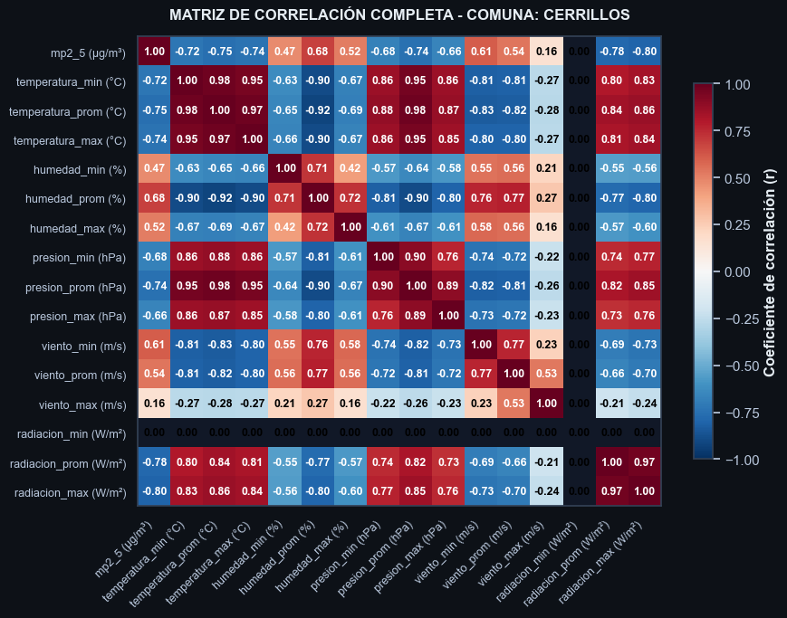

```
✅ Gráfico renderizado para: CERRILLOS
------------------------------------------------------------------------------------------
```

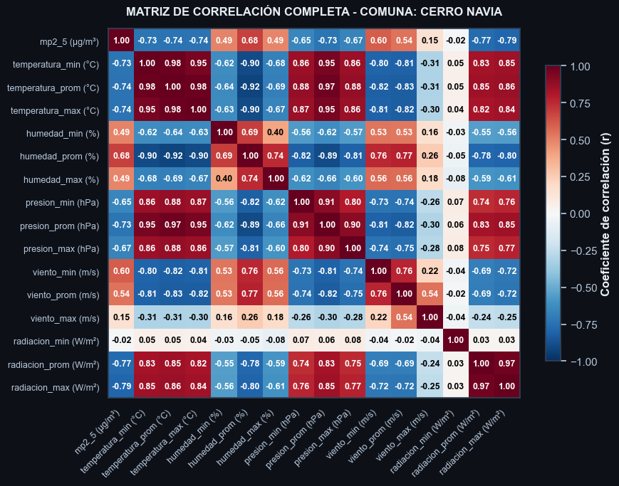

```
✅ Gráfico renderizado para: CERRO NAVIA
------------------------------------------------------------------------------------------
```

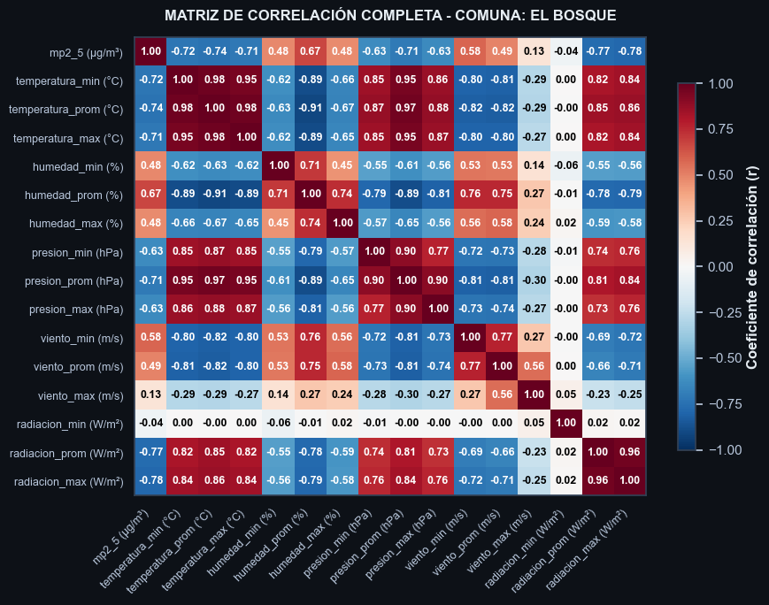

```
✅ Gráfico renderizado para: EL BOSQUE
------------------------------------------------------------------------------------------
```

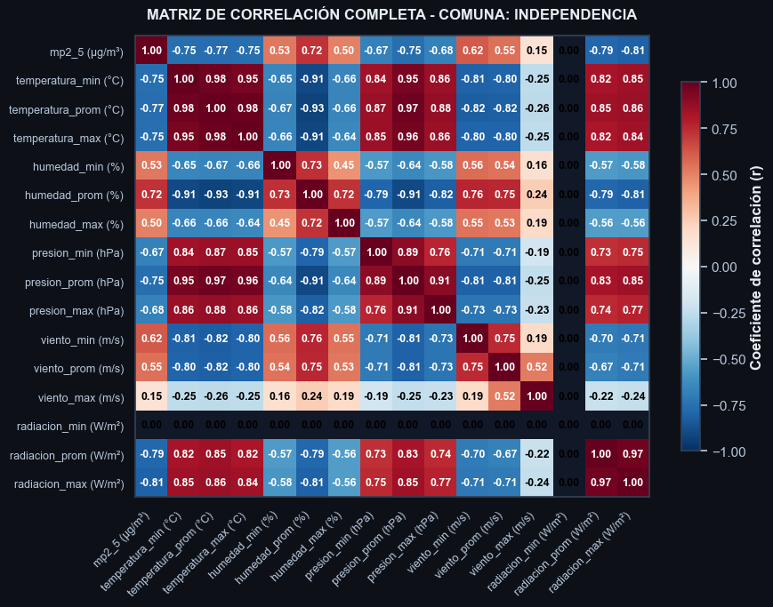

```
✅ Gráfico renderizado para: INDEPENDENCIA
------------------------------------------------------------------------------------------
```

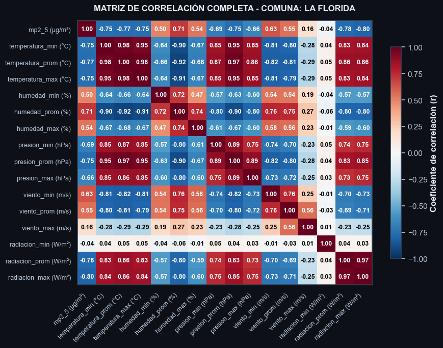

```
✅ Gráfico renderizado para: LA FLORIDA
------------------------------------------------------------------------------------------
```

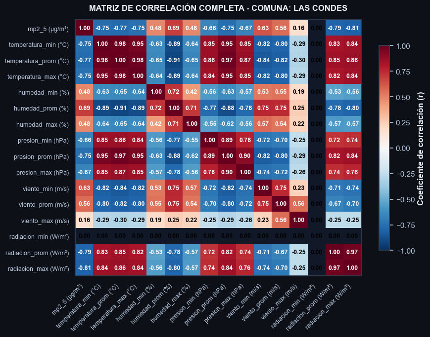

```
✅ Gráfico renderizado para: LAS CONDES
------------------------------------------------------------------------------------------
```

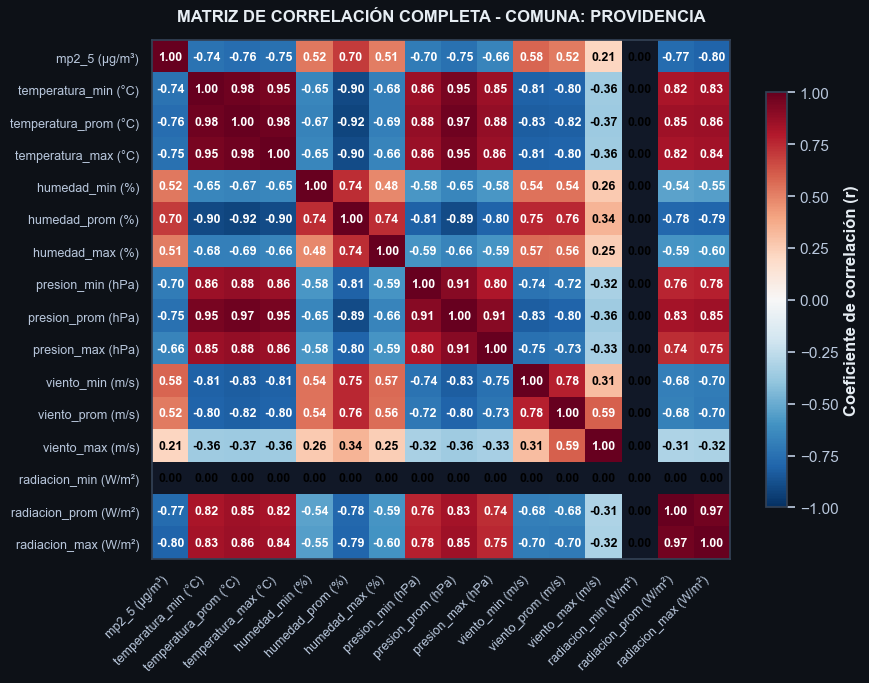

```
✅ Gráfico renderizado para: PROVIDENCIA
------------------------------------------------------------------------------------------
```

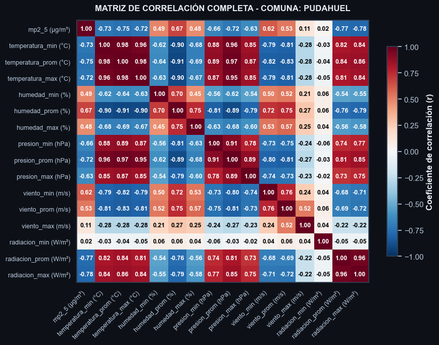

```
✅ Gráfico renderizado para: PUDAHUEL
------------------------------------------------------------------------------------------
```

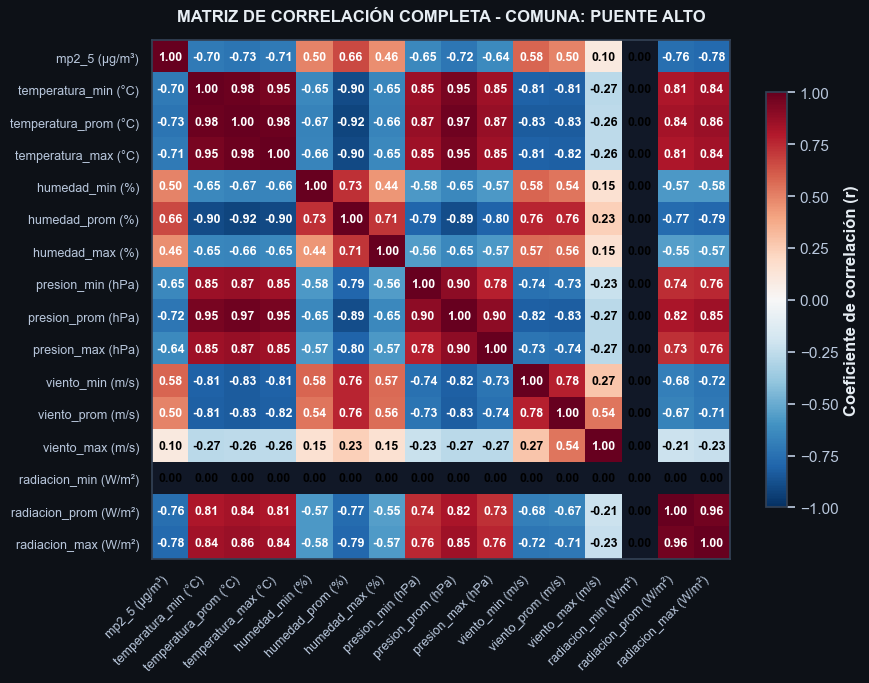

```
✅ Gráfico renderizado para: PUENTE ALTO
------------------------------------------------------------------------------------------
```

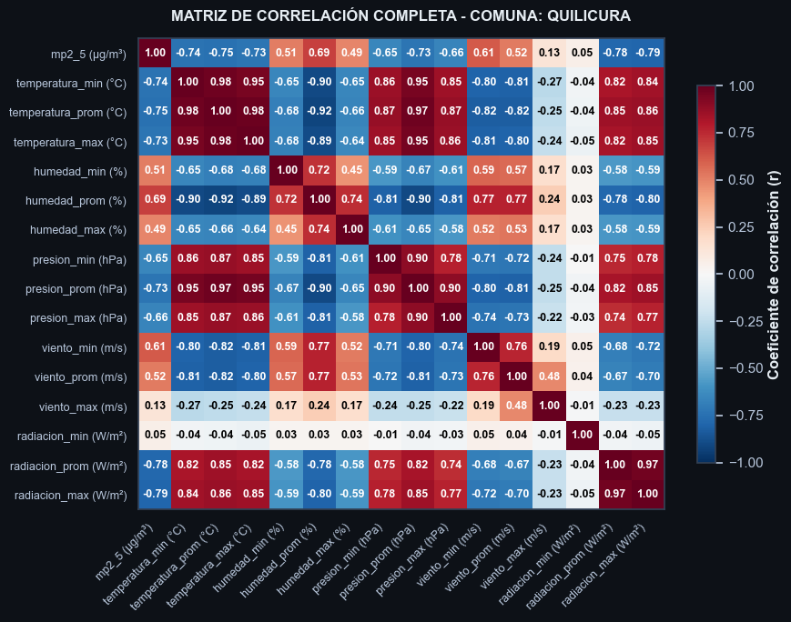

```
✅ Gráfico renderizado para: QUILICURA
------------------------------------------------------------------------------------------
```

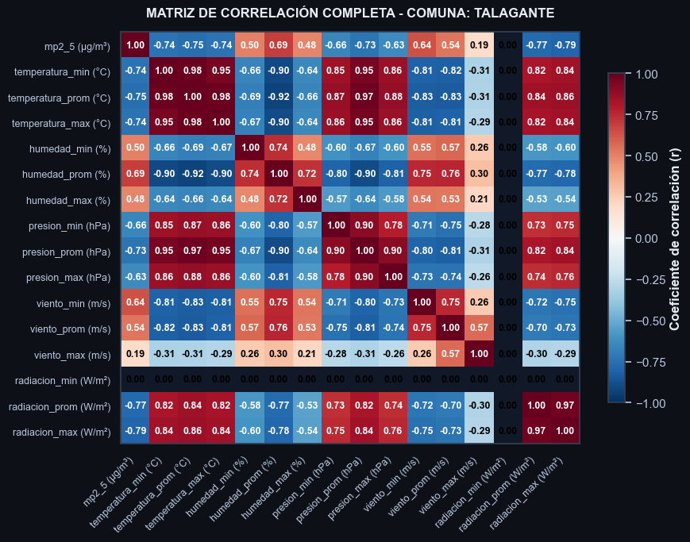

```
✅ Gráfico renderizado para: TALAGANTE
------------------------------------------------------------------------------------------
```

```python
# =============================================================================
# 10 MATRICES DE CORRELACIÓN ORIGINALES POR COMUNA (DISEÑO VERTICAL INTEGRAL)
# Proyecto F4 (Entrega final): Calidad del Aire en Santiago
# =============================================================================

import re
import unicodedata
import pandas as pd
import numpy as np
import matplotlib.pyplot as plt
from IPython.display import display, HTML

# -----------------------------------------------------------------------------
# 1) Funciones utilitarias
# -----------------------------------------------------------------------------

def normalizar_columna(col):
    col = str(col).strip()
    col = col.replace("µ", "u")
    col = unicodedata.normalize("NFKD", col)
    col = "".join(c for c in col if not unicodedata.combining(c))
    col = col.lower()
    col = re.sub(r"[^a-z0-9]+", "_", col)
    col = re.sub(r"_+", "_", col)
    return col.strip("_")


def detectar_columna(df_base, patrones):
    for col in df_base.columns:
        col_norm = normalizar_columna(col)
        if any(p in col_norm for p in patrones):
            return col
    return None


# -----------------------------------------------------------------------------
# 2) Selección robusta del DataFrame base
# -----------------------------------------------------------------------------

candidatos_df = [
    "df",
    "df_limpio",
    "df_normalizado",
    "df_final",
    "df_procesado",
    "mp25_diario_con_boolean",
    "mp25_diario",
    "df_eventos_criticos",
    "promedios_diarios"
]

df_base_nombre = None

for nombre in candidatos_df:
    if nombre in globals() and isinstance(globals()[nombre], pd.DataFrame):
        if len(globals()[nombre]) > 0:
            df_base_nombre = nombre
            break

if df_base_nombre is None:
    disponibles = [n for n, v in globals().items() if isinstance(v, pd.DataFrame)]
    raise NameError(f"No se encontró un DataFrame válido. Disponibles: {disponibles}.")

df_corr_base = globals()[df_base_nombre].copy()

# Localizar la columna temporal
col_fecha = detectar_columna(df_corr_base, ["fecha", "date", "time", "timestamp"])
if col_fecha:
    df_corr_base[col_fecha] = pd.to_datetime(df_corr_base[col_fecha])
    df_corr_base['fecha_dia'] = df_corr_base[col_fecha].dt.date
elif isinstance(df_corr_base.index, pd.DatetimeIndex):
    df_corr_base['fecha_dia'] = df_corr_base.index.date
else:
    raise KeyError("No se encontró columna temporal para realizar agregaciones diarias.")

# Localizar columna espacial
col_comuna_orig = detectar_columna(df_corr_base, ["comuna", "station", "estacion", "comunas"])
if not col_comuna_orig:
    raise KeyError("No se encontró una columna que represente las comunas.")

comunas_series = df_corr_base[col_comuna_orig].copy()
df_corr_base.columns = [normalizar_columna(c) for c in df_corr_base.columns]
col_comuna = normalizar_columna(col_comuna_orig)
df_corr_base[col_comuna] = comunas_series

# -----------------------------------------------------------------------------
# 3) Detección robusta de variables y mapeo de unidades de medida
# -----------------------------------------------------------------------------

mapa_variables = {
    "mp2_5": ["mp2_5", "pm2_5", "mp25", "pm25", "mp2_5_ug_m3", "mp2_5_promedio_diario"],
    "temperatura": ["temperatura", "temp"],
    "humedad": ["humedad", "humidity", "hr"],
    "presion": ["presion", "pressure"],
    "viento": ["viento", "velocidad_viento", "wind"],
    "radiacion": ["radiacion", "radiation", "solar"]
}

unidades_medida = {
    "mp2_5": "µg/m³",
    "temperatura": "°C",
    "humedad": "%",
    "presion": "hPa",
    "viento": "m/s",
    "radiacion": "W/m²"
}

columnas_detectadas = {}
variables_faltantes = []

for nombre_estandar, patrones in mapa_variables.items():
    col = detectar_columna(df_corr_base, patrones)
    if col is not None:
        columnas_detectadas[nombre_estandar] = col
    else:
        variables_faltantes.append(f"{nombre_estandar} ({unidades_medida[nombre_estandar]})")

if "mp2_5" not in columnas_detectadas:
    raise KeyError(f"No se detectó la columna objetivo de MP2.5.")

# -----------------------------------------------------------------------------
# 4) Preparación y Agregación Multivariada Diaria por Comuna
# -----------------------------------------------------------------------------

cols_analisis = [col_comuna, 'fecha_dia'] + list(columnas_detectadas.values())
df_corr = df_corr_base[cols_analisis].copy()

df_corr = df_corr.rename(columns={v: k for k, v in columnas_detectadas.items()})

for col in columnas_detectadas.keys():
    df_corr[col] = pd.to_numeric(df_corr[col], errors="coerce")

df_corr = df_corr.dropna().reset_index(drop=True)

if len(df_corr) == 0:
    raise ValueError("No quedaron registros válidos tras limpiar nulos.")

agg_dict = {"mp2_5": ["mean"]}
vars_meteorologicas = [v for v in columnas_detectadas.keys() if v != "mp2_5"]
for var in vars_meteorologicas:
    agg_dict[var] = ["min", "mean", "max"]

df_diario = df_corr.groupby([col_comuna, 'fecha_dia']).agg(agg_dict)

# Aplanar asignando etiquetas legibles con unidades
nuevas_cols = []
mapa_etiquetas_grafico = {}

for col, estadistico in df_diario.columns:
    unidad = unidades_medida[col]
    if col == "mp2_5":
        nombre_col = "mp2_5"
        mapa_etiquetas_grafico[nombre_col] = f"mp2_5 ({unidad})"
        nuevas_cols.append(nombre_col)
    else:
        sufijo = "prom" if estadistico == "mean" else estadistico
        nombre_col = f"{col}_{sufijo}"
        mapa_etiquetas_grafico[nombre_col] = f"{col}_{sufijo} ({unidad})"
        nuevas_cols.append(nombre_col)

df_diario.columns = nuevas_cols
df_diario = df_diario.reset_index()

lista_comunas = sorted(df_diario[col_comuna].unique())
total_comunas = len(lista_comunas)

# Columnas definitivas del mapa de calor cruzado
columnas_finales_corr = ["mp2_5"] + [f"{v}_{m}" for v in vars_meteorologicas for m in ["min", "prom", "max"]]
etiquetas_ejes_con_unidades = [mapa_etiquetas_grafico[c] for c in columnas_finales_corr]

# -----------------------------------------------------------------------------
# 5) Procesamiento de datos y Construcción de Reporte HTML con Variable Mayor
# -----------------------------------------------------------------------------

filas_html_comunas = ""

for comuna_nom in lista_comunas:
    df_sub = df_diario[df_diario[col_comuna] == comuna_nom][columnas_finales_corr].copy()

    # Rellenar nulos locales con el promedio de la columna para evitar NaNs en la matriz
    df_sub = df_sub.fillna(df_sub.mean()).fillna(0)

    corr_comuna = df_sub.corr(numeric_only=True)

    # Capturar la fila de MP2.5 excluyendo la autocorrelación
    corr_pm25_comuna = corr_comuna["mp2_5"].drop("mp2_5")

    if len(corr_pm25_comuna.dropna()) > 0:
        # Encontrar la variable con mayor correlación absoluta
        var_mayor_col = corr_pm25_comuna.index[corr_pm25_comuna.abs().argmax()]
        valor_mayor_coef = corr_pm25_comuna[var_mayor_col]
        var_limpia_con_unidad = mapa_etiquetas_grafico[var_mayor_col]

        tipo_rel = "Positiva" if valor_mayor_coef > 0 else "Negativa" if valor_mayor_coef < 0 else "Nula"
        intensidad_rel = "Fuerte" if abs(valor_mayor_coef) >= 0.7 else "Moderada" if abs(valor_mayor_coef) >= 0.4 else "Débil"
    else:
        var_limpia_con_unidad = "Sin datos suficientes"
        valor_mayor_coef = 0.0
        tipo_rel = "N/A"
        intensidad_rel = ""

    filas_html_comunas += f"""
    <tr>
        <td style="padding:8px;border:1px solid #cbd5e1;font-weight:bold;text-transform:uppercase;">{comuna_nom}</td>
        <td style="padding:8px;border:1px solid #cbd5e1;color:#1F3A5F;font-weight:bold;">{var_limpia_con_unidad}</td>
        <td style="padding:8px;border:1px solid #cbd5e1;font-weight:bold;text-align:center;">{valor_mayor_coef:.3f}</td>
        <td style="padding:8px;border:1px solid #cbd5e1;font-style:italic;">{tipo_rel} {intensidad_rel}</td>
    </tr>
    """

# Renderizar panel HTML unificado
html_corr = f"""
<div style="
    width:100%;
    box-sizing:border-box;
    background:#F4F7FA;
    color:#111827;
    padding:20px;
    border-left:6px solid #B22234;
    border-radius:10px;
    font-family:Arial,Helvetica,sans-serif;
    margin-top:16px;
    margin-bottom:16px;
">
<h3 style="margin-top:0;margin-bottom:15px;font-size:22px;font-weight:700;color:#1F3A5F;text-align:left;">
🚨 10 Diagnóstico de Máxima Correlación Meteorológica por Comuna
</h3>
<table style="width:100%;border-collapse:collapse;font-size:13px;color:#111827;text-align:left;">
<thead>
    <tr style="background-color:#1F3A5F;color:#FFFFFF;">
        <th style="padding:10px;border:1px solid #cbd5e1;text-align:left;">Comuna Territorial</th>
        <th style="padding:10px;border:1px solid #cbd5e1;text-align:left;">Variable de Mayor Impacto (Unidad)</th>
        <th style="padding:10px;border:1px solid #cbd5e1;text-align:center;">Coeficiente (r)</th>
        <th style="padding:10px;border:1px solid #cbd5e1;text-align:left;">Interpretación Técnica</th>
    </tr>
</thead>
<tbody>
    {filas_html_comunas}
</tbody>
</table>
<p style="margin-top:16px;margin-bottom:0;line-height:1.6;font-size:14px;color:#111827;text-align:left;">
<strong>Conclusión del análisis espacial:</strong>
La tabla superior demuestra qué magnitud física ejerce el mayor control estadístico sobre las concentraciones de <strong>MP2.5</strong> en cada punto geográfico.
</p>
</div>
"""

display(HTML(html_corr))

# -----------------------------------------------------------------------------
# 6) Renderizado de Matrices Individuales (Un gráfico por fila/columna)
# -----------------------------------------------------------------------------

print(f"\nGenerando {total_comunas} gráficos independientes en disposición vertical...")

for comuna_nom in lista_comunas:
    df_sub = df_diario[df_diario[col_comuna] == comuna_nom][columnas_finales_corr].copy()

    # Tratamiento robusto anti-NaN por comuna
    df_sub = df_sub.fillna(df_sub.mean()).fillna(0)
    corr_comuna = df_sub.corr(numeric_only=True)

    # Inicializar cada gráfico con el tamaño original exacto (9, 7)
    fig, ax = plt.subplots(figsize=(9, 7))

    im = ax.imshow(
        corr_comuna.values,
        cmap="RdBu_r",
        vmin=-1,
        vmax=1,
        aspect="auto"
    )

    ax.set_xticks(range(len(columnas_finales_corr)))
    ax.set_yticks(range(len(columnas_finales_corr)))

    ax.set_xticklabels(
        etiquetas_ejes_con_unidades,
        rotation=45,
        ha="right",
        fontsize=9
    )
    ax.set_yticklabels(etiquetas_ejes_con_unidades, fontsize=9)

    # Añadir valores numéricos celda por celda (Texto bicolor automático)
    for i in range(len(columnas_finales_corr)):
        for j in range(len(columnas_finales_corr)):
            valor = corr_comuna.values[i, j]
            texto_celda = f"{valor:.2f}" if not np.isnan(valor) else "0.00"

            ax.text(
                j, i, texto_celda,
                ha="center", va="center",
                color="white" if abs(valor) > 0.4 else "black",
                fontsize=9, fontweight="bold"
            )

    cb = fig.colorbar(im, ax=ax, shrink=0.8)
    cb.set_label("Coeficiente de correlación (r)", fontweight="bold")

    ax.set_title(
        f"MATRIZ DE CORRELACIÓN COMPLETA - COMUNA: {comuna_nom.upper()}",
        pad=14,
        fontweight="bold",
        fontsize=12
    )

    ax.grid(False)

    plt.tight_layout()
    plt.show()
    print(f"✅ Gráfico renderizado para: {comuna_nom.upper()}\n" + "-"*90)
```

### 📌 Interpretación de la matriz de correlación

En particular, la radiación máxima puede explicarse por factores como la **inclinación terrestre** y la **época del año**. Por ello, si esta variable es predecible y mantiene una **correlación inversa relevante** con los episodios críticos, puede aportar a la **anticipación del riesgo ambiental** planteado en el proyecto.

🎯 11 Condiciones que anticipan un episodio crítico

El análisis exploratorio identificó a la **radiación solar máxima diaria** como la variable meteorológica con mayor capacidad de anticipación para los episodios críticos de contaminación por **MP2.5**. Los resultados muestran una **relación inversa consistente**, donde mayores niveles de radiación se asocian a menores concentraciones promedio del contaminante.  
Durante los períodos fríos, una disminución sostenida de la radiación favorece condiciones atmosféricas más estables, reduciendo la dispersión de contaminantes y aumentando la probabilidad de alcanzar valores críticos. Este comportamiento permite utilizar la radiación máxima como un **indicador predictivo temprano** para anticipar eventos que superen el umbral normativo de **49 µg/m³ de MP2.5 promedio diario**.

📊 12. Conclusiones preliminares

Si bien el análisis preliminar sugería que las variables meteorológicas individuales presentaban correlaciones lineales débiles o moderadas respecto de las concentraciones de material particulado (McKinney, 2022), la incorporación de la radiación solar máxima y el análisis de variables categóricas modifican sustancialmente esta conclusión. Los resultados obtenidos evidencian que la radiación máxima presenta una asociación significativa con las concentraciones de MP2.5. Al contrastar esta relación con las series temporales mensuales, se observa un patrón estacional consistente y recurrente en todas las comunas analizadas: los niveles promedio de MP2.5 aumentan de forma sostenida durante el periodo otoño–invierno, particularmente entre abril y agosto, mientras que alcanzan sus mínimos durante los meses estivales.  
Este comportamiento encuentra una explicación física plausible en la reducción de la radiación solar durante los meses fríos, condición que favorece la persistencia de fenómenos de estabilidad atmosférica e inversión térmica. Como consecuencia, disminuye la capacidad de dispersión vertical de contaminantes, facilitando su acumulación en los niveles inferiores de la atmósfera y elevando las concentraciones observadas de material particulado fino.  
La evidencia se ve reforzada mediante el análisis de variables booleanas asociadas a condiciones meteorológicas y temporales. Los diagramas de distribución muestran que los días con presencia de inversión térmica desplazan sistemáticamente las concentraciones de MP2.5 hacia valores superiores, acercándose con mayor frecuencia al umbral de 49 µg/m³ utilizado para identificar episodios críticos. En contraste, las variables temporales **«Es Finde»** y **«Es Festivo»** presentan una tendencia opuesta, evidenciando reducciones sistemáticas en los niveles de contaminación durante jornadas con menor actividad económica y movilidad urbana.  
Estos hallazgos sugieren la coexistencia de factores meteorológicos y antropogénicos en la dinámica de la contaminación atmosférica. Mientras las condiciones meteorológicas condicionan la capacidad de dispersión de contaminantes, la disminución del flujo vehicular y de determinadas actividades productivas durante fines de semana y festivos contribuye temporalmente a reducir la carga de emisiones. Adicionalmente, el análisis espacial revela diferencias relevantes entre comunas, observándose concentraciones más elevadas en sectores como **Cerro Navia** y **Pudahuel**, mientras que comunas como **Las Condes** presentan niveles relativamente inferiores.  
En consecuencia, la radiación solar máxima y la presencia de inversión térmica emergen como variables de alta relevancia para explicar la variabilidad observada del MP2.5 dentro de la Región Metropolitana. Su efecto se encuentra complementado por factores territoriales y temporales asociados tanto a la ubicación geográfica de las estaciones como a patrones de movilidad y actividad humana. Estos resultados proporcionan una base sólida para orientar futuras etapas de modelamiento predictivo.  
Como línea de trabajo futura, se recomienda incorporar técnicas de aprendizaje supervisado, análisis multivariado y modelos avanzados de series temporales. Resulta especialmente relevante evaluar modelos segmentados por estacionalidad, diferenciando explícitamente los periodos críticos comprendidos entre abril y agosto, así como las dinámicas asociadas a días hábiles, fines de semana y festivos. Este enfoque permitiría capturar patrones complejos de comportamiento y mejorar la capacidad predictiva de las concentraciones de contaminantes atmosféricos.

# 📊 12.1 Resultados — Hallazgos del Análisis Exploratorio

Se presentan los **resultados verificables** del análisis exploratorio, apoyados en las visualizaciones finales del notebook y vinculados explícitamente a los objetivos del proyecto.

Qué significan los hallazgos

Considerando los datos y las zonas muestreadas, se concluye que el MP2.5 no es un fenómeno aleatorio, sino que presenta patrones temporales y territoriales detectables. Estos hallazgos sirven para analizar zonas con condiciones similares, por ejemplo, que pertenezcan a la misma región, lo que justifica el desarrollo del núcleo algorítmico de detección (notebook 02) y cumple el objetivo de exploración y comunicación de hallazgos.

# 🧭 12.2 Discusión — Limitaciones, Riesgos y Alcance

Se contrastan los resultados con las expectativas iniciales y se declaran de forma transparente las limitaciones, riesgos y el alcance de las conclusiones del análisis exploratorio.

Limitaciones

- **Datos faltantes:** los registros nulos en ciertas estaciones afectan la continuidad de las series y dificultan un cálculo homogéneo de la estacionalidad mensual.
- **Estaciones con cobertura desigual:** la densidad de mediciones varía por comuna, lo que limita la comparabilidad directa de las distribuciones territoriales mediante boxplots.
- **Variables meteorológicas limitadas:** el conjunto disponible no agota los factores que inciden en el MP2.5, restringiendo un análisis de correlación multivariable más profundo más allá de la radiación máxima diaria.

Riesgos

- **Correlación ≠ causalidad:** las fuertes asociaciones lineales observadas no implican una relación de causalidad física directa entre las variables meteorológicas y el contaminante.
- **Sensibilidad a valores atípicos:** la presencia de picos extremos de contaminación (detectados visualmente como outliers) puede sesgar las métricas promedio de MP2.5 si no se analizan en conjunto con la mediana.
- **Dataset histórico estático:** los patrones identificados corresponden estrictamente al periodo analizado, por lo que el comportamiento de la estacionalidad según la estación del año podría no generalizar ante escenarios de cambio climático futuro.

Alcance de las conclusiones

Las conclusiones exploratorias obtenidas poseen una validez matemática circunscrita al **alcance del dataset y del periodo estudiado**. Si bien los hallazgos proporcionan un marco de referencia analítico extrapolable a zonas con condiciones geoclimáticas similares dentro de la misma región, su utilización para la toma de decisiones o predicción operativa requiere la implementación de un modelado avanzado complementario.

# 🎯 12.3 Conclusiones — Aprendizajes y Trabajo Futuro

Síntesis de los aprendizajes técnicos y analíticos del análisis exploratorio, con su relación a los resultados y propuestas de mejora basadas en evidencia.

Aprendizajes técnicos

- **El uso de Python permitió automatizar el análisis** exploratorio de forma reproducible y escalable.
- **Las librerías Pandas y NumPy mejoraron la eficiencia** del procesamiento de datos y la generación de recursos visuales clave para discriminar variables.
- **La Programación Orientada a Objetos mejoró la mantenibilidad** del pipeline mediante una auditoría modular y trazabilidad del código estructurado.

Aprendizajes analíticos

- **El comportamiento del MP2.5 presenta episodios críticos detectables** correlacionados fuertemente a la radiación máxima diaria y condicionados por factores meteorológicos específicos analizados visualmente.
- Se identificaron **patrones estacionales vinculados a la estación del año y dinámicas territoriales** que facilitan el análisis extrapolable a otras zonas de la misma región.
- La **exploración y descarte de variables fundamenta y orienta** el diseño del núcleo algorítmico de la fase de desarrollo posterior.

Trabajo futuro

- **Incorporar un modelo de Machine Learning predictivo** enfocado en la anticipación de episodios críticos basados en las variables meteorológicas de mayor peso.
- **Modelar series temporales complejas** para robustecer la comprensión de la estacionalidad según la estación del año y la tendencia a largo plazo.
- **Integrar datos climáticos adicionales de regiones colindantes** para evaluar la transferencia y replicabilidad del modelo en zonas con condiciones geográficas similares.

# 🧬 12.4 Trazabilidad de Mejoras (F1 → F4)

Se presenta la **evidencia de la evolución técnica entre fases**: cada observación formativa se vincula con la acción correctiva, el commit asociado y su impacto técnico. Este registro se complementa con el archivo `changelog.md` en el repositorio.

[output not shown]